# Credit Risk Detection & Monitoring Dashboard

### Final Monthly Analysis Table

After adding the recession indicator (`USREC`) and the 30-year Treasury yield (`DGS30`), the monthly core table was revalidated. The 30-year Treasury series loaded without missing values. The recession indicator contained one missing value, which appears in the most recent incomplete month. To avoid using partially reported data in feature engineering, the final monthly analysis table excludes rows where the recession indicator is unavailable.

The cleaned feature-engineering input table is stored as `fred_monthly_analysis_core_final`.

### 6.1 Feature Engineering Objective

The final monthly analysis table provides cleaned and aligned macroeconomic, credit, interest-rate, financial-stress, and market-context indicators. Feature engineering converts those cleaned indicators into analytical signals that can support macro-credit risk monitoring.

The objective of this section is to create features that describe both the current level of risk and the direction of risk conditions. Current-level features show where conditions stand in a given month. Change features show whether conditions are improving or deteriorating. Moving averages smooth noisy indicators. Forward S&P 500 return features allow the project to evaluate whether macro-credit regimes were historically followed by different equity-market outcomes.

This section does not create the final credit-risk score yet. It creates the feature table that will be used later for risk thresholds, regime bands, scoring, visualization, market-context validation, and business interpretation.

### 6.2 Market-Contextual Risk Overlay Expansion

After constructing the core monthly credit-risk dataset, additional FRED series were added to improve the practical usefulness and validation depth of the dashboard. The NBER recession indicator (`USREC`) was added to validate whether the credit-risk score rises during known recession and stress periods. The 30-year Treasury yield (`DGS30`) was added to capture long-duration rate pressure, which is relevant for interest-rate sensitivity, valuation pressure, bond-market stress, and long-horizon credit conditions.

The S&P 500 variables were added as a market-context overlay. These variables do not enter the Composite Credit Risk Score directly. Instead, they allow the project to evaluate whether macro-credit stress regimes historically lined up with different future equity-market outcomes.

This keeps the project focused on macro-credit risk detection and monitoring, while also allowing the dashboard to answer a secondary question: when macro-credit conditions are stressed, what tends to happen to forward market performance?

The market-context overlay supports three uses:

1. Historical validation: testing whether macro-credit stress aligns with known recession and stress periods.
2. Forward market-context analysis: testing whether higher credit-risk regimes were followed by different 1-month, 3-month, or 6-month S&P 500 returns.
3. Business interpretation: helping users understand whether the dashboard is signaling broad credit stress, market stress, or a more concentrated risk environment.

This section creates the variables required for those later checks. The actual regime scoring, threshold validation, and market-context interpretation are developed after the scoring framework is created.

### 6.3 Feature Groups Created

The feature table is designed around five groups of variables:

1. **Level features** preserve the current monthly value of each indicator. These answer: what is the current state of credit, macroeconomic, rate, and market conditions?
2. **One-month change features** measure short-term movement. These answer: did risk conditions change materially from the prior month?
3. **Three-month change features** capture medium-term trend direction. These reduce overreaction to one-month noise and help identify whether conditions are consistently improving or deteriorating.
4. **Moving average features** smooth noisy financial indicators such as VIX, credit spreads, financial stress, unemployment, and long-term rates. Both 3-month and 6-month moving averages are included to support short-term and medium-term monitoring.
5. **Forward S&P 500 return features** support market-context validation. These variables measure what happened to equity-market performance after each monthâ€™s observed macro-credit conditions. They are retained as validation and interpretation outcomes, not as direct inputs to the Composite Credit Risk Score.

The feature table is stored as `credit_risk_monthly_features`.

### 6.4 SQL Feature Table Construction

The following SQL block creates the feature table from `fred_monthly_analysis_core_final`. The table includes current indicator levels, changes, moving averages, S&P 500 month-end values, and forward S&P 500 return outcomes.

The following SQL creates the feature table `credit_risk_monthly_features` from `fred_monthly_analysis_core_final`. The table keeps the cleaned monthly indicator levels, adds short-term and medium-term changes, includes moving averages, and calculates S&P 500 forward returns from month-end values for market-context validation.

[output not shown]

```python
feature_engineering_sql = """
DROP TABLE IF EXISTS credit_risk_monthly_features;

CREATE TABLE credit_risk_monthly_features AS

WITH sp500_month_end AS (
    -- Pull the last available S&P 500 observation in each month.
    -- Month-end values are used for return calculations because returns are point-to-point.
    SELECT
        month_end,
        value AS sp500_month_end
    FROM (
        SELECT
            date(date, 'start of month', '+1 month', '-1 day') AS month_end,
            date,
            value,
            ROW_NUMBER() OVER (
                PARTITION BY date(date, 'start of month', '+1 month', '-1 day')
                ORDER BY date DESC
            ) AS rn
        FROM fred_raw_observations
        WHERE series_id = 'SP500'
          AND value IS NOT NULL
    )
    WHERE rn = 1
),

base AS (
    -- Combine the final cleaned monthly credit-risk table with S&P 500 monthly average
    -- and S&P 500 month-end values.
    SELECT
        a.*,
        w.sp500 AS sp500_monthly_avg,
        s.sp500_month_end
    FROM fred_monthly_analysis_core_final a
    LEFT JOIN fred_monthly_wide_raw w
        ON a.month_end = w.month_end
    LEFT JOIN sp500_month_end s
        ON a.month_end = s.month_end
)

SELECT
    month_end,

    -- ============================================================
    -- Level features:
    -- Current monthly state of credit, macro, rate, and market indicators.
    -- ============================================================
    unrate,
    fedfunds,
    dgs10,
    dgs30,
    t10y2y,
    vixcls,
    baa10y,
    stlfsi4,
    usrec,

    delinquency_all_loans,
    delinquency_credit_cards,
    delinquency_consumer_loans,
    chargeoff_all_loans,
    chargeoff_credit_cards,

    -- S&P 500 monthly average is retained as a market-condition feature.
    sp500_monthly_avg,

    -- S&P 500 month-end is used for return and forward-return calculations.
    sp500_month_end,

    -- ============================================================
    -- 1-month change features:
    -- Short-term deterioration or improvement.
    -- ============================================================
    unrate - LAG(unrate, 1) OVER (ORDER BY month_end) AS unrate_1m_change,
    fedfunds - LAG(fedfunds, 1) OVER (ORDER BY month_end) AS fedfunds_1m_change,
    dgs10 - LAG(dgs10, 1) OVER (ORDER BY month_end) AS dgs10_1m_change,
    dgs30 - LAG(dgs30, 1) OVER (ORDER BY month_end) AS dgs30_1m_change,
    t10y2y - LAG(t10y2y, 1) OVER (ORDER BY month_end) AS t10y2y_1m_change,
    vixcls - LAG(vixcls, 1) OVER (ORDER BY month_end) AS vixcls_1m_change,
    baa10y - LAG(baa10y, 1) OVER (ORDER BY month_end) AS baa10y_1m_change,
    stlfsi4 - LAG(stlfsi4, 1) OVER (ORDER BY month_end) AS stlfsi4_1m_change,

    delinquency_all_loans - LAG(delinquency_all_loans, 1) OVER (ORDER BY month_end) AS delinquency_all_loans_1m_change,
    delinquency_credit_cards - LAG(delinquency_credit_cards, 1) OVER (ORDER BY month_end) AS delinquency_credit_cards_1m_change,
    delinquency_consumer_loans - LAG(delinquency_consumer_loans, 1) OVER (ORDER BY month_end) AS delinquency_consumer_loans_1m_change,

    chargeoff_all_loans - LAG(chargeoff_all_loans, 1) OVER (ORDER BY month_end) AS chargeoff_all_loans_1m_change,
    chargeoff_credit_cards - LAG(chargeoff_credit_cards, 1) OVER (ORDER BY month_end) AS chargeoff_credit_cards_1m_change,

    -- ============================================================
    -- 3-month change features:
    -- Medium-term trend direction.
    -- ============================================================
    unrate - LAG(unrate, 3) OVER (ORDER BY month_end) AS unrate_3m_change,
    fedfunds - LAG(fedfunds, 3) OVER (ORDER BY month_end) AS fedfunds_3m_change,
    dgs10 - LAG(dgs10, 3) OVER (ORDER BY month_end) AS dgs10_3m_change,
    dgs30 - LAG(dgs30, 3) OVER (ORDER BY month_end) AS dgs30_3m_change,
    t10y2y - LAG(t10y2y, 3) OVER (ORDER BY month_end) AS t10y2y_3m_change,
    vixcls - LAG(vixcls, 3) OVER (ORDER BY month_end) AS vixcls_3m_change,
    baa10y - LAG(baa10y, 3) OVER (ORDER BY month_end) AS baa10y_3m_change,
    stlfsi4 - LAG(stlfsi4, 3) OVER (ORDER BY month_end) AS stlfsi4_3m_change,

    delinquency_all_loans - LAG(delinquency_all_loans, 3) OVER (ORDER BY month_end) AS delinquency_all_loans_3m_change,
    delinquency_credit_cards - LAG(delinquency_credit_cards, 3) OVER (ORDER BY month_end) AS delinquency_credit_cards_3m_change,
    delinquency_consumer_loans - LAG(delinquency_consumer_loans, 3) OVER (ORDER BY month_end) AS delinquency_consumer_loans_3m_change,

    chargeoff_all_loans - LAG(chargeoff_all_loans, 3) OVER (ORDER BY month_end) AS chargeoff_all_loans_3m_change,
    chargeoff_credit_cards - LAG(chargeoff_credit_cards, 3) OVER (ORDER BY month_end) AS chargeoff_credit_cards_3m_change,

    -- ============================================================
    -- Moving average features:
    -- Smoothing noisy market, rate, and macro indicators.
    -- ============================================================
    AVG(unrate) OVER (
        ORDER BY month_end ROWS BETWEEN 2 PRECEDING AND CURRENT ROW
    ) AS unrate_3m_avg,

    AVG(vixcls) OVER (
        ORDER BY month_end ROWS BETWEEN 2 PRECEDING AND CURRENT ROW
    ) AS vixcls_3m_avg,

    AVG(baa10y) OVER (
        ORDER BY month_end ROWS BETWEEN 2 PRECEDING AND CURRENT ROW
    ) AS baa10y_3m_avg,

    AVG(stlfsi4) OVER (
        ORDER BY month_end ROWS BETWEEN 2 PRECEDING AND CURRENT ROW
    ) AS stlfsi4_3m_avg,

    AVG(dgs30) OVER (
        ORDER BY month_end ROWS BETWEEN 2 PRECEDING AND CURRENT ROW
    ) AS dgs30_3m_avg,

    AVG(unrate) OVER (
        ORDER BY month_end ROWS BETWEEN 5 PRECEDING AND CURRENT ROW
    ) AS unrate_6m_avg,

    AVG(vixcls) OVER (
        ORDER BY month_end ROWS BETWEEN 5 PRECEDING AND CURRENT ROW
    ) AS vixcls_6m_avg,

    AVG(baa10y) OVER (
        ORDER BY month_end ROWS BETWEEN 5 PRECEDING AND CURRENT ROW
    ) AS baa10y_6m_avg,

    AVG(stlfsi4) OVER (
        ORDER BY month_end ROWS BETWEEN 5 PRECEDING AND CURRENT ROW
    ) AS stlfsi4_6m_avg,

    AVG(dgs30) OVER (
        ORDER BY month_end ROWS BETWEEN 5 PRECEDING AND CURRENT ROW
    ) AS dgs30_6m_avg,

    -- ============================================================
    -- Asset-management overlay:
    -- Current and forward S&P 500 returns based on month-end values.
    -- ============================================================
    sp500_month_end / LAG(sp500_month_end, 1) OVER (ORDER BY month_end) - 1 AS sp500_return_1m,

    LEAD(sp500_month_end, 1) OVER (ORDER BY month_end) / sp500_month_end - 1 AS sp500_forward_1m_return,
    LEAD(sp500_month_end, 3) OVER (ORDER BY month_end) / sp500_month_end - 1 AS sp500_forward_3m_return,
    LEAD(sp500_month_end, 6) OVER (ORDER BY month_end) / sp500_month_end - 1 AS sp500_forward_6m_return

FROM base
ORDER BY month_end;
"""

conn.executescript(feature_engineering_sql)
conn.commit()

features_preview = pd.read_sql_query(
    """
    SELECT
        month_end,
        unrate,
        unrate_3m_change,
        vixcls,
        vixcls_3m_change,
        baa10y,
        baa10y_3m_change,
        stlfsi4,
        stlfsi4_3m_change,
        dgs30,
        dgs30_3m_change,
        sp500_monthly_avg,
        sp500_month_end,
        sp500_return_1m,
        sp500_forward_3m_return,
        usrec
    FROM credit_risk_monthly_features
    WHERE sp500_month_end IS NOT NULL
    ORDER BY month_end
    LIMIT 20;
    """,
    conn
)

features_preview

# sp500_return_1m first value will not be placed as it needs a preceeding month to be calculated for value demonstrated as : current month-end S&P 500 / prior month-end S&P 500 - 1
```

|  | month_end | unrate | unrate_3m_change | vixcls | vixcls_3m_change | baa10y | baa10y_3m_change | stlfsi4 | stlfsi4_3m_change | dgs30 | dgs30_3m_change | sp500_monthly_avg | sp500_month_end | sp500_return_1m | sp500_forward_3m_return | usrec |
| --- | --- | --- | --- | --- | --- | --- | --- | --- | --- | --- | --- | --- | --- | --- | --- | --- |
| 0 | 2016-08-31 | 4.9 | 0.1 | 12.399565 | -2.453292 | 2.683913 | -0.186563 | 0.265475 | 0.127450 | 2.261739 | -0.365880 | 2180.346000 | 2170.95 | NaN | 0.012833 | 0.0 |
| 1 | 2016-09-30 | 5.0 | 0.1 | 14.219524 | -3.555022 | 2.680952 | -0.199957 | 0.351960 | 0.066685 | 2.350476 | -0.101797 | 2157.690952 | 2168.27 | -0.001234 | 0.032542 | 0.0 |
| 2 | 2016-10-31 | 4.9 | 0.1 | 14.585238 | 1.426738 | 2.612000 | -0.102500 | 0.156500 | -0.055940 | 2.500500 | 0.273500 | 2143.020952 | 2126.15 | -0.019426 | 0.071829 | 0.0 |
| 3 | 2016-11-30 | 4.7 | -0.2 | 15.236190 | 2.836625 | 2.566000 | -0.117913 | 0.086325 | -0.179150 | 2.862000 | 0.600261 | 2164.985714 | 2198.81 | 0.034174 | 0.074963 | 0.0 |
| 4 | 2016-12-31 | 4.7 | -0.3 | 12.472381 | -1.747143 | 2.335238 | -0.345714 | -0.107680 | -0.459640 | 3.113333 | 0.762857 | 2246.629048 | 2238.83 | 0.018201 | 0.055337 | 0.0 |
| 5 | 2017-01-31 | 4.7 | -0.2 | 11.608500 | -2.976738 | 2.228000 | -0.384000 | -0.116400 | -0.272900 | 3.019000 | 0.518500 | 2275.116000 | 2278.87 | 0.017884 | 0.046220 | 0.0 |
| 6 | 2017-02-28 | 4.6 | -0.1 | 11.530526 | -3.705664 | 2.222105 | -0.343895 | -0.201750 | -0.288075 | 3.032105 | 0.170105 | 2329.910526 | 2363.64 | 0.037198 | 0.020375 | 0.0 |
| 7 | 2017-03-31 | 4.4 | -0.3 | 11.897826 | -0.574555 | 2.200000 | -0.135238 | -0.359080 | -0.251400 | 3.081304 | -0.032029 | 2366.822174 | 2362.72 | -0.000389 | 0.025686 | 0.0 |
| 8 | 2017-04-30 | 4.4 | -0.3 | 13.136316 | 1.527816 | 2.272105 | 0.044105 | -0.362900 | -0.246500 | 2.941579 | -0.077421 | 2359.309474 | 2384.20 | 0.009091 | 0.036113 | 0.0 |
| 9 | 2017-05-31 | 4.4 | -0.2 | 10.862273 | -0.668254 | 2.245909 | 0.023804 | -0.556475 | -0.354725 | 2.959091 | -0.073014 | 2395.345909 | 2411.80 | 0.011576 | 0.024815 | 0.0 |
| 10 | 2017-06-30 | 4.3 | -0.1 | 10.513636 | -1.384190 | 2.183182 | -0.016818 | -0.613340 | -0.254260 | 2.796364 | -0.284941 | 2433.985455 | 2423.41 | 0.004814 | 0.039593 | 0.0 |
| 11 | 2017-07-31 | 4.3 | -0.1 | 10.264500 | -2.871816 | 2.071500 | -0.200605 | -0.639150 | -0.276250 | 2.884000 | -0.057579 | 2454.102500 | 2470.30 | 0.019349 | 0.042489 | 0.0 |
| 12 | 2017-08-31 | 4.4 | 0.0 | 11.975652 | 1.113379 | 2.100870 | -0.145040 | -0.492600 | 0.063875 | 2.795217 | -0.163874 | 2456.223043 | 2471.65 | 0.000546 | 0.071179 | 0.0 |
| 13 | 2017-09-30 | 4.3 | 0.0 | 10.438000 | -0.075636 | 2.101500 | -0.081682 | -0.594060 | 0.019280 | 2.776500 | -0.019864 | 2492.841000 | 2519.36 | 0.019303 | 0.061226 | 0.0 |
| 14 | 2017-10-31 | 4.2 | -0.1 | 10.125455 | -0.139045 | 1.955714 | -0.115786 | -0.712950 | -0.073800 | 2.878095 | -0.005905 | 2556.997273 | 2575.26 | 0.022188 | 0.096515 | 0.0 |
| 15 | 2017-11-30 | 4.2 | -0.2 | 10.540476 | -1.435176 | 1.915500 | -0.185370 | -0.717675 | -0.225075 | 2.801905 | 0.006687 | 2593.605714 | 2647.58 | 0.028083 | 0.025023 | 0.0 |
| 16 | 2017-12-31 | 4.1 | -0.2 | 10.264500 | -0.173500 | 1.821000 | -0.280500 | -0.650460 | -0.056400 | 2.768000 | -0.008500 | 2664.340500 | 2673.61 | 0.009832 | -0.012246 | 0.0 |
| 17 | 2018-01-31 | 4.0 | -0.2 | 11.062381 | 0.936926 | 1.672381 | -0.283333 | -0.660175 | 0.052775 | 2.877619 | -0.000476 | 2789.803810 | 2823.81 | 0.056179 | -0.062242 | 0.0 |
| 18 | 2018-02-28 | 4.1 | -0.1 | 22.464737 | 11.924261 | 1.650000 | -0.265500 | -0.251600 | 0.466075 | 3.131053 | 0.329148 | 2705.155263 | 2713.83 | -0.038947 | -0.003154 | 0.0 |
| 19 | 2018-03-31 | 4.0 | -0.1 | 19.023810 | 8.759310 | 1.797619 | -0.023381 | 0.082100 | 0.732560 | 3.091429 | 0.323429 | 2702.773810 | 2640.87 | -0.026885 | 0.029346 | 0.0 |

- USREC = 0 means the month is not classified as a U.S. recession month. USREC = 1 means the month falls inside an NBER recession period.

```python
pd.read_sql_query(
    """
    SELECT
        MIN(month_end) AS first_sp500_month,
        MAX(month_end) AS last_sp500_month,
        COUNT(*) AS months_with_sp500
    FROM credit_risk_monthly_features
    WHERE sp500_month_end IS NOT NULL;
    """,
    conn
)
# Just to confirm tracking for Asset Management Overlay
```

|  | first_sp500_month | last_sp500_month | months_with_sp500 |
| --- | --- | --- | --- |
| 0 | 2016-08-31 | 2026-07-31 | 120 |

### Feature Window Clarification

The feature table contains two valid analytical windows.

The credit-risk monitoring window begins in 2000 because the core macroeconomic, credit, financial-stress, delinquency, and charge-off indicators have usable history from that period. This window supports the main macro-credit risk detection and monitoring framework.

The S&P 500 market-context window begins later because the FRED S&P 500 series used in this project starts in 2016. Therefore, S&P 500 return and forward-return features are only available from the first usable S&P 500 month onward. Earlier rows remain valid for credit-risk monitoring, but they cannot be used for S&P 500 forward-return analysis.

This creates two valid use cases:

- Credit-risk monitoring: 2000â€“present
- S&P 500 market-context / forward equity-return testing: 2016â€“present, based on available S&P 500 data

```python
window_summary = pd.read_sql_query(
    """
    SELECT
        MIN(month_end) AS credit_risk_first_month,
        MAX(month_end) AS credit_risk_last_month,
        COUNT(*) AS credit_risk_total_months,

        MIN(CASE WHEN sp500_month_end IS NOT NULL THEN month_end END) AS sp500_overlay_first_month,
        MAX(CASE WHEN sp500_month_end IS NOT NULL THEN month_end END) AS sp500_overlay_last_month,
        SUM(CASE WHEN sp500_month_end IS NOT NULL THEN 1 ELSE 0 END) AS sp500_overlay_months,

        SUM(CASE WHEN sp500_month_end IS NULL THEN 1 ELSE 0 END) AS months_without_sp500_overlay
    FROM credit_risk_monthly_features;
    """,
    conn
)

window_summary
```

|  | credit_risk_first_month | credit_risk_last_month | credit_risk_total_months | sp500_overlay_first_month | sp500_overlay_last_month | sp500_overlay_months | months_without_sp500_overlay |
| --- | --- | --- | --- | --- | --- | --- | --- |
| 0 | 2000-01-31 | 2026-07-31 | 319 | 2016-08-31 | 2026-07-31 | 120 | 199 |

### Recession Indicator Validation

The following query checks the distribution of the NBER recession indicator. A value of 0 represents non-recession months, while a value of 1 represents recession months.

```python
recession_check = pd.read_sql_query(
    """
    SELECT
        usrec,
        COUNT(*) AS month_count,
        MIN(month_end) AS first_month,
        MAX(month_end) AS last_month
    FROM credit_risk_monthly_features
    GROUP BY usrec
    ORDER BY usrec;
    """,
    conn
)

recession_check
```

|  | usrec | month_count | first_month | last_month |
| --- | --- | --- | --- | --- |
| 0 | 0.0 | 291 | 2000-01-31 | 2026-07-31 |
| 1 | 1.0 | 28 | 2001-04-30 | 2020-04-30 |

### S&P 500 Overlay Validation

The following query inspects the first available S&P 500 overlay rows, including monthly average values, month-end values, current monthly returns, and forward return calculations.

```python
sp500_overlay_check = pd.read_sql_query(
    """
    SELECT
        month_end,
        sp500_monthly_avg,
        sp500_month_end,
        sp500_return_1m,
        sp500_forward_1m_return,
        sp500_forward_3m_return,
        sp500_forward_6m_return
    FROM credit_risk_monthly_features
    WHERE sp500_month_end IS NOT NULL
    ORDER BY month_end
    LIMIT 12;
    """,
    conn
)

sp500_overlay_check
```

|  | month_end | sp500_monthly_avg | sp500_month_end | sp500_return_1m | sp500_forward_1m_return | sp500_forward_3m_return | sp500_forward_6m_return |
| --- | --- | --- | --- | --- | --- | --- | --- |
| 0 | 2016-08-31 | 2180.346000 | 2170.95 | NaN | -0.001234 | 0.012833 | 0.088758 |
| 1 | 2016-09-30 | 2157.690952 | 2168.27 | -0.001234 | -0.019426 | 0.032542 | 0.089680 |
| 2 | 2016-10-31 | 2143.020952 | 2126.15 | -0.019426 | 0.034174 | 0.071829 | 0.121370 |
| 3 | 2016-11-30 | 2164.985714 | 2198.81 | 0.034174 | 0.018201 | 0.074963 | 0.096866 |
| 4 | 2016-12-31 | 2246.629048 | 2238.83 | 0.018201 | 0.017884 | 0.055337 | 0.082445 |
| 5 | 2017-01-31 | 2275.116000 | 2278.87 | 0.017884 | 0.037198 | 0.046220 | 0.084002 |
| 6 | 2017-02-28 | 2329.910526 | 2363.64 | 0.037198 | -0.000389 | 0.020375 | 0.045696 |
| 7 | 2017-03-31 | 2366.822174 | 2362.72 | -0.000389 | 0.009091 | 0.025686 | 0.066296 |
| 8 | 2017-04-30 | 2359.309474 | 2384.20 | 0.009091 | 0.011576 | 0.036113 | 0.080136 |
| 9 | 2017-05-31 | 2395.345909 | 2411.80 | 0.011576 | 0.004814 | 0.024815 | 0.097761 |
| 10 | 2017-06-30 | 2433.985455 | 2423.41 | 0.004814 | 0.019349 | 0.039593 | 0.103243 |
| 11 | 2017-07-31 | 2454.102500 | 2470.30 | 0.019349 | 0.000546 | 0.042489 | 0.143104 |

The first available S&P 500 return observation may be missing because a one-month return requires a prior month-end S&P 500 value. Forward returns become available once future month-end values exist. At the end of the dataset, forward returns are missing because future observations have not occurred yet.

### 6.5 Feature Table Validation

The feature table is validated to confirm row count, date range, expected missing values from lagged features, and expected missing values from forward-return features. Lagged variables naturally create missing values at the beginning of the dataset, while forward-return variables create missing values at the end because future market values are not yet available.

This validation also confirms that the S&P 500 market-context window is shorter than the full credit-risk monitoring window. The credit-risk monitoring features begin in 2000, while the S&P 500 return overlay begins in 2016 based on the available FRED S&P 500 series.

```python
feature_validation = pd.read_sql_query(
    """
    SELECT
        COUNT(*) AS total_rows,
        MIN(month_end) AS first_month,
        MAX(month_end) AS last_month,

        SUM(CASE WHEN unrate_1m_change IS NULL THEN 1 ELSE 0 END) AS missing_unrate_1m_change,
        SUM(CASE WHEN unrate_3m_change IS NULL THEN 1 ELSE 0 END) AS missing_unrate_3m_change,

        SUM(CASE WHEN vixcls_3m_change IS NULL THEN 1 ELSE 0 END) AS missing_vixcls_3m_change,
        SUM(CASE WHEN baa10y_3m_change IS NULL THEN 1 ELSE 0 END) AS missing_baa10y_3m_change,
        SUM(CASE WHEN stlfsi4_3m_change IS NULL THEN 1 ELSE 0 END) AS missing_stlfsi4_3m_change,
        SUM(CASE WHEN dgs30_3m_change IS NULL THEN 1 ELSE 0 END) AS missing_dgs30_3m_change,

        SUM(CASE WHEN sp500_month_end IS NULL THEN 1 ELSE 0 END) AS missing_sp500_month_end,
        SUM(CASE WHEN sp500_return_1m IS NULL THEN 1 ELSE 0 END) AS missing_sp500_return_1m,
        SUM(CASE WHEN sp500_forward_1m_return IS NULL THEN 1 ELSE 0 END) AS missing_sp500_forward_1m_return,
        SUM(CASE WHEN sp500_forward_3m_return IS NULL THEN 1 ELSE 0 END) AS missing_sp500_forward_3m_return,
        SUM(CASE WHEN sp500_forward_6m_return IS NULL THEN 1 ELSE 0 END) AS missing_sp500_forward_6m_return

    FROM credit_risk_monthly_features;
    """,
    conn
)

feature_validation
```

|  | total_rows | first_month | last_month | missing_unrate_1m_change | missing_unrate_3m_change | missing_vixcls_3m_change | missing_baa10y_3m_change | missing_stlfsi4_3m_change | missing_dgs30_3m_change | missing_sp500_month_end | missing_sp500_return_1m | missing_sp500_forward_1m_return | missing_sp500_forward_3m_return | missing_sp500_forward_6m_return |
| --- | --- | --- | --- | --- | --- | --- | --- | --- | --- | --- | --- | --- | --- | --- |
| 0 | 319 | 2000-01-31 | 2026-07-31 | 3 | 5 | 3 | 3 | 3 | 3 | 199 | 200 | 200 | 202 | 205 |

```python
latest_features = pd.read_sql_query(
    """
    SELECT
        month_end,
        unrate,
        unrate_3m_change,
        vixcls,
        baa10y,
        stlfsi4,
        dgs30,
        delinquency_all_loans,
        chargeoff_all_loans,
        sp500_return_1m,
        sp500_forward_3m_return,
        sp500_forward_6m_return,
        usrec
    FROM credit_risk_monthly_features
    ORDER BY month_end DESC
    LIMIT 12;
    """,
    conn
)

latest_features
```

|  | month_end | unrate | unrate_3m_change | vixcls | baa10y | stlfsi4 | dgs30 | delinquency_all_loans | chargeoff_all_loans | sp500_return_1m | sp500_forward_3m_return | sp500_forward_6m_return | usrec |
| --- | --- | --- | --- | --- | --- | --- | --- | --- | --- | --- | --- | --- | --- |
| 0 | 2026-07-31 | 4.1 | -0.2 | 17.090870 | 1.585909 | -0.72814 | 5.099091 | 1.48 | 0.56 | -0.001285 | NaN | NaN | 0.0 |
| 1 | 2026-06-30 | 4.2 | -0.1 | 17.906818 | 1.530476 | -0.80790 | 4.947619 | 1.48 | 0.56 | -0.010646 | NaN | NaN | 0.0 |
| 2 | 2026-05-31 | 4.3 | -0.1 | 17.237143 | 1.619000 | -0.72086 | 5.031000 | 1.48 | 0.56 | 0.051470 | NaN | NaN | 0.0 |
| 3 | 2026-04-30 | 4.3 | 0.0 | 19.811905 | 1.711429 | -0.57430 | 4.909091 | 1.48 | 0.56 | 0.104233 | 0.038939 | NaN | 0.0 |
| 4 | 2026-03-31 | 4.3 | -0.1 | 25.596818 | 1.789545 | -0.31645 | 4.845000 | 1.48 | 0.56 | -0.050933 | 0.148708 | NaN | 0.0 |
| 5 | 2026-02-28 | 4.4 | -0.1 | 19.207000 | 1.686842 | -0.54450 | 4.762632 | 1.48 | 0.56 | -0.008668 | 0.101932 | NaN | 0.0 |
| 6 | 2026-01-31 | 4.3 | NaN | 16.179048 | 1.665000 | -0.64788 | 4.838500 | 1.48 | 0.56 | 0.013663 | 0.038907 | 0.079361 | 0.0 |
| 7 | 2025-12-31 | 4.4 | 0.0 | 15.548182 | 1.754545 | -0.42150 | 4.800909 | 1.48 | 0.58 | -0.000524 | -0.046305 | 0.095517 | 0.0 |
| 8 | 2025-11-30 | 4.5 | 0.2 | 19.769500 | 1.763333 | -0.33295 | 4.701667 | 1.48 | 0.58 | 0.001300 | 0.004349 | 0.106725 | 0.0 |
| 9 | 2025-10-31 | NaN | NaN | 18.086522 | 1.673182 | -0.46080 | 4.636818 | 1.48 | 0.58 | 0.022687 | 0.014448 | 0.053918 | 0.0 |
| 10 | 2025-09-30 | 4.4 | 0.3 | 15.789091 | 1.712857 | -0.52625 | 4.742857 | 1.49 | 0.63 | 0.035324 | 0.023479 | -0.023913 | 0.0 |
| 11 | 2025-08-31 | 4.3 | 0.0 | 15.750000 | 1.731429 | -0.68248 | 4.868571 | 1.49 | 0.63 | 0.019067 | 0.060188 | 0.064799 | 0.0 |

```python
credit_risk_features = pd.read_sql_query(
    """
    SELECT *
    FROM credit_risk_monthly_features
    ORDER BY month_end;
    """,
    conn
)

credit_risk_features.to_csv(
    tables_dir / "credit_risk_monthly_features.csv",
    index=False
)

credit_risk_features.head()
```

|  | month_end | unrate | fedfunds | dgs10 | dgs30 | t10y2y | vixcls | baa10y | stlfsi4 | usrec | delinquency_all_loans | delinquency_credit_cards | delinquency_consumer_loans | chargeoff_all_loans | chargeoff_credit_cards | sp500_monthly_avg | sp500_month_end | unrate_1m_change | fedfunds_1m_change | dgs10_1m_change | dgs30_1m_change | t10y2y_1m_change | vixcls_1m_change | baa10y_1m_change | stlfsi4_1m_change | delinquency_all_loans_1m_change | delinquency_credit_cards_1m_change | delinquency_consumer_loans_1m_change | chargeoff_all_loans_1m_change | … |
| --- | --- | --- | --- | --- | --- | --- | --- | --- | --- | --- | --- | --- | --- | --- | --- | --- | --- | --- | --- | --- | --- | --- | --- | --- | --- | --- | --- | --- | --- | --- |
| 0 | 2000-01-31 | 4.0 | 5.45 | 6.661000 | 6.625500 | 0.221000 | 23.202000 | 1.671500 | 0.009125 | 0.0 | 2.08 | 4.43 | 3.47 | 0.59 | 4.53 | NaN | NaN | NaN | NaN | NaN | NaN | NaN | NaN | NaN | NaN | NaN | NaN | NaN | NaN | … |
| 1 | 2000-02-29 | 4.1 | 5.73 | 6.519500 | 6.232000 | -0.091000 | 23.595500 | 1.767500 | 0.118400 | 0.0 | 2.08 | 4.43 | 3.47 | 0.59 | 4.53 | NaN | NaN | 0.1 | 0.28 | -0.141500 | -0.393500 | -0.312000 | 0.393500 | 0.096000 | 0.109275 | 0.00 | 0.00 | 0.00 | 0.00 | … |
| 2 | 2000-03-31 | 4.0 | 5.85 | 6.256522 | 6.053478 | -0.271739 | 22.718261 | 2.110870 | 0.029760 | 0.0 | 2.08 | 4.43 | 3.47 | 0.59 | 4.53 | NaN | NaN | -0.1 | 0.12 | -0.262978 | -0.178522 | -0.180739 | -0.877239 | 0.343370 | -0.088640 | 0.00 | 0.00 | 0.00 | 0.00 | … |
| 3 | 2000-04-30 | 3.8 | 6.02 | 5.990526 | 5.846316 | -0.413158 | 27.164211 | 2.411579 | 0.413825 | 0.0 | 2.14 | 4.51 | 3.53 | 0.61 | 4.10 | NaN | NaN | -0.2 | 0.17 | -0.265995 | -0.207162 | -0.141419 | 4.445950 | 0.300709 | 0.384065 | 0.06 | 0.08 | 0.06 | 0.02 | … |
| 4 | 2000-05-31 | 4.0 | 6.27 | 6.440455 | 6.148636 | -0.369091 | 26.373182 | 2.460000 | 0.449775 | 0.0 | 2.14 | 4.51 | 3.53 | 0.61 | 4.10 | NaN | NaN | 0.2 | 0.25 | 0.449928 | 0.302321 | 0.044067 | -0.791029 | 0.048421 | 0.035950 | 0.00 | 0.00 | 0.00 | 0.00 | … |

### Feature Engineering Validation Summary

The feature table `credit_risk_monthly_features` was created successfully from `fred_monthly_analysis_core_final`. The table includes current indicator levels, 1-month changes, 3-month changes, 3-month and 6-month moving averages, S&P 500 month-end values, and S&P 500 forward return variables.

Missing values are expected in specific locations. Lagged change variables are missing at the beginning of the dataset because prior observations are required for calculation. Forward S&P 500 return variables are missing at the end of the dataset because future market values are not yet available. The S&P 500 market-context window also begins later than the full credit-risk monitoring dataset, so market-context return analysis is limited to the available S&P 500 period.

The feature table is ready for the next stage: risk thresholds, regime bands, scoring, validation, visualization, and business interpretation.

### 6.6 Section 6 Wrap-Up

Section 6 creates the analytical feature table that will support the rest of the dashboard. The table combines macroeconomic, credit-market, interest-rate, financial-stress, realized credit-performance, recession, and S&P 500 market-context variables into one monthly structure.

The main output of this section is `credit_risk_monthly_features`.

At this stage, the notebook has created the inputs needed for later analysis, but it has not yet created the final credit-risk score. The current macro-credit regime will be answered after the Composite Credit Risk Score is created. The primary drivers will be answered after the category-level scores are built. Historical recession alignment will be evaluated after the threshold and regime framework is developed.

The S&P 500 forward-return features will support market-context validation. These variables will allow the project to test whether higher macro-credit risk regimes were historically followed by different 1-month, 3-month, or 6-month equity-market outcomes. They will also help evaluate whether regime transitions, such as moving from Normal to Watch, provide useful downside-risk context.

The key conclusion from Section 6 is that the notebook now has a validated monthly feature table that supports both the core macro-credit monitoring framework and the secondary S&P 500 market-context validation layer.

## 7. Risk Thresholds and Regime Bands

### 7.1 Model Definition

The primary model is a transparent percentile-based macro-credit risk scorecard. It converts monthly macroeconomic, credit-market, interest-rate, financial-stress, and realized credit-performance indicators into standardized risk percentiles.

The model produces both a continuous composite score and a categorical credit-risk regime. The continuous score summarizes the relative severity of current conditions, while the categorical regime classifies each month as Normal, Watch, Elevated, or Stress.

This is initially a rule-based monitoring model rather than a fitted regression or machine-learning model. The scorecard prioritizes transparency, reproducibility, and business interpretation. Predictive models may later be developed as challenger models and compared against the scorecard using forward-looking outcomes.

### 7.2 Score Architecture

The score is organized into four categories:

1. Market and financial stress
2. Macroeconomic and labor deterioration
3. Rate and yield-curve pressure
4. Realized credit performance

Indicators are grouped by economic function so that highly related variables do not independently dominate the composite score. Each indicator is transformed so that higher values consistently represent greater risk. The indicators are then converted into historical percentile ranks, averaged within their categories, and combined into one composite score.

The NBER recession indicator and forward S&P 500 returns are excluded from score construction. They are retained as validation outcomes used to test whether higher risk scores historically aligned with recessions or weaker future equity-market performance.

### 7.3 Scoring Input Table

The following SQL creates a focused scoring-input table from `credit_risk_monthly_features`. It separates model inputs from validation outcomes and aligns indicator direction so that higher values consistently represent greater risk.

```python
scoring_input_sql = """
DROP TABLE IF EXISTS credit_risk_scoring_inputs;

CREATE TABLE credit_risk_scoring_inputs AS
SELECT
    month_end,

    -- ============================================================
    -- Market and financial stress inputs
    -- Higher values represent greater risk.
    -- ============================================================
    vixcls_3m_avg,
    vixcls_3m_change,

    baa10y_3m_avg,
    baa10y_3m_change,

    stlfsi4_3m_avg,
    stlfsi4_3m_change,

    -- ============================================================
    -- Macroeconomic and labor deterioration inputs
    -- Higher unemployment and increasing unemployment raise risk.
    -- ============================================================
    unrate_3m_avg,
    unrate_3m_change,

    -- ============================================================
    -- Rate and yield-curve pressure inputs
    -- Higher long rates and rising long rates indicate rate pressure.
    -- T10Y2Y is multiplied by -1 so greater inversion produces
    -- a larger risk-direction value.
    -- ============================================================
    dgs30_3m_avg,
    dgs30_3m_change,
    -1.0 * t10y2y AS yield_curve_inversion_risk,

    -- ============================================================
    -- Realized credit-performance inputs
    -- Higher and rising delinquency/charge-off rates raise risk.
    -- ============================================================
    delinquency_all_loans,
    delinquency_all_loans_3m_change,

    chargeoff_all_loans,
    chargeoff_all_loans_3m_change,

    -- ============================================================
    -- Validation outcomes only
    -- These are excluded from score construction.
    -- ============================================================
    usrec,
    sp500_forward_1m_return,
    sp500_forward_3m_return,
    sp500_forward_6m_return

FROM credit_risk_monthly_features
ORDER BY month_end;
"""

conn.executescript(scoring_input_sql)
conn.commit()

scoring_inputs_preview = pd.read_sql_query(
    """
    SELECT *
    FROM credit_risk_scoring_inputs
    ORDER BY month_end
    LIMIT 12;
    """,
    conn
)

scoring_inputs_preview
```

|  | month_end | vixcls_3m_avg | vixcls_3m_change | baa10y_3m_avg | baa10y_3m_change | stlfsi4_3m_avg | stlfsi4_3m_change | unrate_3m_avg | unrate_3m_change | dgs30_3m_avg | dgs30_3m_change | yield_curve_inversion_risk | delinquency_all_loans | delinquency_all_loans_3m_change | chargeoff_all_loans | chargeoff_all_loans_3m_change | usrec | sp500_forward_1m_return | sp500_forward_3m_return | sp500_forward_6m_return |
| --- | --- | --- | --- | --- | --- | --- | --- | --- | --- | --- | --- | --- | --- | --- | --- | --- | --- | --- | --- | --- |
| 0 | 2000-01-31 | 23.202000 | NaN | 1.671500 | NaN | 0.009125 | NaN | 4.000000 | NaN | 6.625500 | NaN | -0.221000 | 2.08 | NaN | 0.59 | NaN | 0.0 | None | None | None |
| 1 | 2000-02-29 | 23.398750 | NaN | 1.719500 | NaN | 0.063762 | NaN | 4.050000 | NaN | 6.428750 | NaN | 0.091000 | 2.08 | NaN | 0.59 | NaN | 0.0 | None | None | None |
| 2 | 2000-03-31 | 23.171920 | NaN | 1.849957 | NaN | 0.052428 | NaN | 4.033333 | NaN | 6.303659 | NaN | 0.271739 | 2.08 | NaN | 0.59 | NaN | 0.0 | None | None | None |
| 3 | 2000-04-30 | 24.492657 | 3.962211 | 2.096650 | 0.740079 | 0.187328 | 0.404700 | 3.966667 | -0.2 | 6.043931 | -0.779184 | 0.413158 | 2.14 | 0.06 | 0.61 | 0.02 | 0.0 | None | None | None |
| 4 | 2000-05-31 | 25.418551 | 2.777682 | 2.327483 | 0.692500 | 0.297787 | 0.331375 | 3.933333 | -0.1 | 6.016143 | -0.083364 | 0.369091 | 2.14 | 0.06 | 0.61 | 0.02 | 0.0 | None | None | None |
| 5 | 2000-06-30 | 25.025797 | -1.178261 | 2.418860 | 0.274130 | 0.426867 | 0.387240 | 3.933333 | 0.0 | 5.973772 | -0.127115 | 0.384545 | 2.14 | 0.06 | 0.61 | 0.02 | 0.0 | None | None | None |
| 6 | 2000-07-31 | 22.602061 | -7.271211 | 2.379167 | -0.119079 | 0.342392 | -0.253425 | 4.000000 | 0.2 | 5.975333 | 0.004684 | 0.285000 | 2.20 | 0.06 | 0.61 | 0.00 | 0.0 | None | None | None |
| 7 | 2000-08-31 | 19.840565 | -8.284486 | 2.368877 | -0.030870 | 0.204750 | -0.412925 | 4.033333 | 0.1 | 5.831150 | -0.432549 | 0.402609 | 2.20 | 0.06 | 0.61 | 0.00 | 0.0 | None | None | None |
| 8 | 2000-09-30 | 19.223065 | -1.852500 | 2.422877 | 0.162000 | 0.098617 | -0.318400 | 4.000000 | -0.1 | 5.797862 | -0.099864 | 0.282500 | 2.20 | 0.06 | 0.61 | 0.00 | 0.0 | None | None | None |
| 9 | 2000-10-31 | 20.992065 | 5.307000 | 2.526329 | 0.310357 | 0.184600 | 0.257950 | 3.966667 | -0.1 | 5.781973 | -0.047667 | 0.173810 | 2.34 | 0.14 | 0.79 | 0.18 | 0.0 | None | None | None |
| 10 | 2000-11-30 | 23.756786 | 8.294161 | 2.570587 | 0.132774 | 0.288625 | 0.312075 | 3.900000 | -0.2 | 5.801849 | 0.059627 | 0.158095 | 2.34 | 0.14 | 0.79 | 0.18 | 0.0 | None | None | None |
| 11 | 2000-12-31 | 26.037786 | 6.843000 | 2.649087 | 0.235500 | 0.476732 | 0.564320 | 3.900000 | 0.0 | 5.689849 | -0.336000 | 0.111500 | 2.34 | 0.14 | 0.79 | 0.18 | 0.0 | None | None | None |

```python
scoring_input_summary = pd.read_sql_query(
    """
    SELECT
        COUNT(*) AS total_rows,
        MIN(month_end) AS first_month,
        MAX(month_end) AS last_month,

        SUM(CASE WHEN vixcls_3m_avg IS NULL THEN 1 ELSE 0 END) AS missing_vix_level,
        SUM(CASE WHEN unrate_3m_change IS NULL THEN 1 ELSE 0 END) AS missing_unrate_change,
        SUM(CASE WHEN dgs30_3m_change IS NULL THEN 1 ELSE 0 END) AS missing_dgs30_change,
        SUM(CASE WHEN yield_curve_inversion_risk IS NULL THEN 1 ELSE 0 END) AS missing_curve_risk,
        SUM(CASE WHEN delinquency_all_loans_3m_change IS NULL THEN 1 ELSE 0 END) AS missing_delinquency_change,
        SUM(CASE WHEN chargeoff_all_loans_3m_change IS NULL THEN 1 ELSE 0 END) AS missing_chargeoff_change

    FROM credit_risk_scoring_inputs;
    """,
    conn
)

scoring_input_summary
```

|  | total_rows | first_month | last_month | missing_vix_level | missing_unrate_change | missing_dgs30_change | missing_curve_risk | missing_delinquency_change | missing_chargeoff_change |
| --- | --- | --- | --- | --- | --- | --- | --- | --- | --- |
| 0 | 319 | 2000-01-31 | 2026-07-31 | 0 | 5 | 3 | 0 | 3 | 3 |

For the missing un_rate change we have unrate listed as LAG(unrate,3) over (ORDER BY month_end). now this does require an observation from three months prior. For the start of our date here the first three months cannot be featured until April 2000, which is the source of missing information.

As for the additionaly 2 missing numbers we will need to locate.

```python
missing_scoring_inputs = pd.read_sql_query(
    """
    SELECT
        month_end,
        unrate_3m_avg,
        unrate_3m_change,
        dgs30_3m_change,
        delinquency_all_loans_3m_change,
        chargeoff_all_loans_3m_change
    FROM credit_risk_scoring_inputs
    WHERE unrate_3m_change IS NULL
       OR dgs30_3m_change IS NULL
       OR delinquency_all_loans_3m_change IS NULL
       OR chargeoff_all_loans_3m_change IS NULL
    ORDER BY month_end;
    """,
    conn
)

missing_scoring_inputs
```

|  | month_end | unrate_3m_avg | unrate_3m_change | dgs30_3m_change | delinquency_all_loans_3m_change | chargeoff_all_loans_3m_change |
| --- | --- | --- | --- | --- | --- | --- |
| 0 | 2000-01-31 | 4.000000 | None | NaN | NaN | NaN |
| 1 | 2000-02-29 | 4.050000 | None | NaN | NaN | NaN |
| 2 | 2000-03-31 | 4.033333 | None | NaN | NaN | NaN |
| 3 | 2025-10-31 | 4.350000 | None | -0.285000 | -0.01 | -0.05 |
| 4 | 2026-01-31 | 4.400000 | None | 0.201682 | 0.00 | -0.02 |

### Unemployment Three-Month Change Gap

The January 2026 unemployment level and rolling average are available, but the three-month unemployment change is unavailable because its comparison month, October 2025, contains a missing unemployment observation. Since the three-month change is calculated as the current value minus the value three months earlier, a missing October observation causes the January change feature to remain null.

This missing value is treated as unavailable information rather than as zero or evidence of stable unemployment. During score construction, the unemployment-change component should be omitted or the latest score should be labeled provisional rather than imputing an unsupported value.

### Missing-Input Scoring Policy

Missing change features are not replaced with indicator levels because levels and changes represent different risk dimensions and use different units. When a component is unavailable, the model retains the valid level-based inputs, calculates the score using the remaining available components, and records the percentage of expected inputs available.

Scores with incomplete input coverage are labeled provisional. Any alternative fallback feature, such as a one-month change, must be predefined, documented, and historically validated before operational use.

### 7.4 Historical Percentile Construction

The scoring inputs use different measurement units. VIX is measured in index points, unemployment and delinquency are measured as percentages, Treasury yields and credit spreads use percentage-point values, and the financial stress index has its own scale. Historical percentile ranks convert these variables onto a common 0-to-100 risk scale.

Two percentile versions are calculated:

1. **Retrospective percentiles** compare each observation with the complete historical sample. These are useful for descriptive historical analysis and visualizing how major stress periods compare with the full 2000-present period.
2. **Expanding percentiles** compare each observation only with data available through that month. This avoids using future information when evaluating historical risk conditions and provides the appropriate percentile measure for backtesting.

The expanding-percentile calculation uses a 60-month warm-up period. Earlier observations remain available for descriptive analysis, but they are not treated as fully calibrated operational scores.

The two percentile versions serve different purposes. Retrospective percentiles are used for descriptive historical comparison because they compare each observation against the full available sample. Expanding percentiles are used for the operational scoring framework because they only use information available up to each month and avoid lookahead bias.

The final operational category scores and composite score are based on expanding percentile features. Retrospective percentiles are retained for historical visualization and comparison, but they are not mixed into the final no-lookahead composite score.

```python
import numpy as np
import pandas as pd

# Read the SQL scoring-input table into Python.
percentile_features = pd.read_sql_query(
    """
    SELECT *
    FROM credit_risk_scoring_inputs
    ORDER BY month_end;
    """,
    conn
)

percentile_features["month_end"] = pd.to_datetime(
    percentile_features["month_end"]
)

# These variables are the actual score inputs.
# USREC and forward S&P 500 returns are validation outcomes and are excluded.
risk_input_columns = [
    # Market and financial stress
    "vixcls_3m_avg",
    "vixcls_3m_change",
    "baa10y_3m_avg",
    "baa10y_3m_change",
    "stlfsi4_3m_avg",
    "stlfsi4_3m_change",

    # Macroeconomic and labor risk
    "unrate_3m_avg",
    "unrate_3m_change",

    # Rate and yield-curve pressure
    "dgs30_3m_avg",
    "dgs30_3m_change",
    "yield_curve_inversion_risk",

    # Realized credit performance
    "delinquency_all_loans",
    "delinquency_all_loans_3m_change",
    "chargeoff_all_loans",
    "chargeoff_all_loans_3m_change"
]


def calculate_expanding_percentile(
    series: pd.Series,
    minimum_history: int = 60
) -> pd.Series:
    """
    Calculate the percentile of each observation using only information
    available through that observation.

    A minimum of 60 non-missing monthly observations is required.
    Missing current observations remain missing.
    """
    expanding_percentiles = []

    for row_number in range(len(series)):
        current_value = series.iloc[row_number]
        historical_values = series.iloc[: row_number + 1].dropna()

        if pd.isna(current_value) or len(historical_values) < minimum_history:
            expanding_percentiles.append(np.nan)
            continue

        current_percentile = (
            historical_values
            .rank(method="average", pct=True)
            .iloc[-1]
            * 100
        )

        expanding_percentiles.append(current_percentile)

    return pd.Series(
        expanding_percentiles,
        index=series.index
    )


# Retrospective percentiles:
# Compare every observation with the complete historical sample.
# These are useful for historical description, not clean backtesting.
for column in risk_input_columns:
    percentile_features[f"{column}_pct_retrospective"] = (
        percentile_features[column]
        .rank(method="average", pct=True)
        * 100
    )


# Expanding no-lookahead percentiles:
# Compare each month only with observations available through that month.
for column in risk_input_columns:
    percentile_features[f"{column}_pct_expanding"] = (
        calculate_expanding_percentile(
            percentile_features[column],
            minimum_history=60
        )
    )


# Input coverage:
# Shows how much of the expected scoring information is available.
percentile_features["input_coverage_pct"] = (
    percentile_features[risk_input_columns]
    .notna()
    .mean(axis=1)
    * 100
)

expanding_percentile_columns = [
    f"{column}_pct_expanding"
    for column in risk_input_columns
]

percentile_features["expanding_percentile_coverage_pct"] = (
    percentile_features[expanding_percentile_columns]
    .notna()
    .mean(axis=1)
    * 100
)

# A row is provisional whenever one or more raw scoring inputs are unavailable.
percentile_features["provisional_input_flag"] = (
    percentile_features["input_coverage_pct"] < 100
).astype(int)

percentile_features.head()
```

|  | month_end | vixcls_3m_avg | vixcls_3m_change | baa10y_3m_avg | baa10y_3m_change | stlfsi4_3m_avg | stlfsi4_3m_change | unrate_3m_avg | unrate_3m_change | dgs30_3m_avg | dgs30_3m_change | yield_curve_inversion_risk | delinquency_all_loans | delinquency_all_loans_3m_change | chargeoff_all_loans | chargeoff_all_loans_3m_change | usrec | sp500_forward_1m_return | sp500_forward_3m_return | sp500_forward_6m_return | vixcls_3m_avg_pct_retrospective | vixcls_3m_change_pct_retrospective | baa10y_3m_avg_pct_retrospective | baa10y_3m_change_pct_retrospective | stlfsi4_3m_avg_pct_retrospective | stlfsi4_3m_change_pct_retrospective | unrate_3m_avg_pct_retrospective | unrate_3m_change_pct_retrospective | dgs30_3m_avg_pct_retrospective | … |
| --- | --- | --- | --- | --- | --- | --- | --- | --- | --- | --- | --- | --- | --- | --- | --- | --- | --- | --- | --- | --- | --- | --- | --- | --- | --- | --- | --- | --- | --- | --- |
| 0 | 2000-01-31 | 23.202000 | NaN | 1.671500 | NaN | 0.009125 | NaN | 4.000000 | NaN | 6.625500 | NaN | -0.221000 | 2.08 | NaN | 0.59 | NaN | 0.0 | NaN | NaN | NaN | 73.667712 | NaN | 8.777429 | NaN | 63.322884 | NaN | 19.122257 | NaN | 100.000000 | … |
| 1 | 2000-02-29 | 23.398750 | NaN | 1.719500 | NaN | 0.063762 | NaN | 4.050000 | NaN | 6.428750 | NaN | 0.091000 | 2.08 | NaN | 0.59 | NaN | 0.0 | NaN | NaN | NaN | 74.294671 | NaN | 14.733542 | NaN | 65.517241 | NaN | 21.316614 | NaN | 99.686520 | … |
| 2 | 2000-03-31 | 23.171920 | NaN | 1.849957 | NaN | 0.052428 | NaN | 4.033333 | NaN | 6.303659 | NaN | 0.271739 | 2.08 | NaN | 0.59 | NaN | 0.0 | NaN | NaN | NaN | 73.354232 | NaN | 24.137931 | NaN | 64.576803 | NaN | 20.532915 | NaN | 99.373041 | … |
| 3 | 2000-04-30 | 24.492657 | 3.962211 | 2.096650 | 0.740079 | 0.187328 | 0.404700 | 3.966667 | -0.2 | 6.043931 | -0.779184 | 0.413158 | 2.14 | 0.06 | 0.61 | 0.02 | 0.0 | NaN | NaN | NaN | 78.683386 | 81.962025 | 36.363636 | 97.151899 | 70.532915 | 85.443038 | 17.868339 | 25.159236 | 99.059561 | … |
| 4 | 2000-05-31 | 25.418551 | 2.777682 | 2.327483 | 0.692500 | 0.297787 | 0.331375 | 3.933333 | -0.1 | 6.016143 | -0.083364 | 0.369091 | 2.14 | 0.06 | 0.61 | 0.02 | 0.0 | NaN | NaN | NaN | 82.445141 | 78.164557 | 51.410658 | 96.835443 | 75.235110 | 82.278481 | 16.614420 | 46.656051 | 98.746082 | … |

### Early Feature Missing Values

The initial rows of the percentile feature table contain expected missing values. Three-month change features cannot be calculated during the first three months because there is no prior three-month comparison period. Expanding percentile features are also unavailable during the initial warm-up period because the model requires 60 months of historical data before treating no-lookahead percentiles as operationally meaningful.

S&P 500 forward-return features are unavailable before 2016 because the FRED S&P 500 series used in this project begins later than the core credit-risk indicators. These missing values do not invalidate the credit-risk monitoring window; they only limit the asset-management overlay to the available S&P 500 period.

```python
import numpy as np
import pandas as pd

# Read scoring inputs from SQLite
percentile_features = pd.read_sql_query(
    """
    SELECT *
    FROM credit_risk_scoring_inputs
    ORDER BY month_end;
    """,
    conn
)

percentile_features["month_end"] = pd.to_datetime(percentile_features["month_end"])

# Score input variables only.
# Validation variables like USREC and S&P forward returns are excluded from scoring.
risk_input_columns = [
    "vixcls_3m_avg",
    "vixcls_3m_change",
    "baa10y_3m_avg",
    "baa10y_3m_change",
    "stlfsi4_3m_avg",
    "stlfsi4_3m_change",
    "unrate_3m_avg",
    "unrate_3m_change",
    "dgs30_3m_avg",
    "dgs30_3m_change",
    "yield_curve_inversion_risk",
    "delinquency_all_loans",
    "delinquency_all_loans_3m_change",
    "chargeoff_all_loans",
    "chargeoff_all_loans_3m_change"
]

def calculate_expanding_percentile(series, minimum_history=60):
    """
    Calculates no-lookahead expanding percentiles.
    Each month is ranked only against data available through that month.
    """
    output = []

    for i in range(len(series)):
        current_value = series.iloc[i]
        historical_values = series.iloc[: i + 1].dropna()

        if pd.isna(current_value) or len(historical_values) < minimum_history:
            output.append(np.nan)
        else:
            pct = historical_values.rank(method="average", pct=True).iloc[-1] * 100
            output.append(pct)

    return pd.Series(output, index=series.index)

# Retrospective percentiles:
# Uses the full sample. Good for historical description, not clean backtesting.
for col in risk_input_columns:
    percentile_features[f"{col}_pct_retrospective"] = (
        percentile_features[col].rank(method="average", pct=True) * 100
    )

# Expanding percentiles:
# Uses only information available through each month.
for col in risk_input_columns:
    percentile_features[f"{col}_pct_expanding"] = calculate_expanding_percentile(
        percentile_features[col],
        minimum_history=60
    )

# Coverage checks
percentile_features["input_coverage_pct"] = (
    percentile_features[risk_input_columns].notna().mean(axis=1) * 100
)

expanding_cols = [f"{col}_pct_expanding" for col in risk_input_columns]

percentile_features["expanding_percentile_coverage_pct"] = (
    percentile_features[expanding_cols].notna().mean(axis=1) * 100
)

percentile_features["provisional_input_flag"] = (
    percentile_features["input_coverage_pct"] < 100
).astype(int)

# Save to SQLite
percentile_features_sql = percentile_features.copy()
percentile_features_sql["month_end"] = percentile_features_sql["month_end"].dt.strftime("%Y-%m-%d")

percentile_features_sql.to_sql(
    "credit_risk_percentile_features",
    conn,
    if_exists="replace",
    index=False
)

conn.commit()

print("Created SQLite table: credit_risk_percentile_features")
print("Rows:", len(percentile_features_sql))
```

```
Created SQLite table: credit_risk_percentile_features
Rows: 319
```

```python
pd.read_sql_query(
    """
    SELECT name
    FROM sqlite_master
    WHERE type = 'table'
    ORDER BY name;
    """,
    conn
)
```

|  | name |
| --- | --- |
| 0 | credit_risk_category_scores |
| 1 | credit_risk_composite_scores |
| 2 | credit_risk_composite_scores_revised |
| 3 | credit_risk_monthly_features |
| 4 | credit_risk_percentile_features |
| 5 | credit_risk_scoring_inputs |
| 6 | dashboard_arima_diagnostic_summary |
| 7 | dashboard_arima_selected_models |
| 8 | dashboard_composite_forecast_chart_data |
| 9 | dashboard_composite_forward_outlook_range |
| 10 | dashboard_credit_risk_score |
| 11 | dashboard_current_credit_risk_snapshot |
| 12 | dashboard_forward_credit_risk_outlook |
| 13 | dashboard_realized_credit_change_summary |
| 14 | dashboard_visualization_output_summary |
| 15 | fred_monthly_analysis_core |
| 16 | fred_monthly_analysis_core_final |
| 17 | fred_monthly_observations |
| 18 | fred_monthly_wide_raw |
| 19 | fred_raw_observations |
| 20 | fred_series_validation_summary |
| 21 | test_connection |

```python
pd.read_sql_query(
    """
    SELECT
        month_end,
        vixcls_3m_avg,
        vixcls_3m_change,
        vixcls_3m_avg_pct_retrospective,
        vixcls_3m_avg_pct_expanding,
        input_coverage_pct,
        expanding_percentile_coverage_pct,
        provisional_input_flag
    FROM credit_risk_percentile_features
    ORDER BY month_end
    LIMIT 70;
    """,
    conn
)
```

|  | month_end | vixcls_3m_avg | vixcls_3m_change | vixcls_3m_avg_pct_retrospective | vixcls_3m_avg_pct_expanding | input_coverage_pct | expanding_percentile_coverage_pct | provisional_input_flag |
| --- | --- | --- | --- | --- | --- | --- | --- | --- |
| 0 | 2000-01-31 | 23.202000 | NaN | 73.667712 | NaN | 53.333333 | 0.0 | 1 |
| 1 | 2000-02-29 | 23.398750 | NaN | 74.294671 | NaN | 53.333333 | 0.0 | 1 |
| 2 | 2000-03-31 | 23.171920 | NaN | 73.354232 | NaN | 53.333333 | 0.0 | 1 |
| 3 | 2000-04-30 | 24.492657 | 3.962211 | 78.683386 | NaN | 100.000000 | 0.0 | 0 |
| 4 | 2000-05-31 | 25.418551 | 2.777682 | 82.445141 | NaN | 100.000000 | 0.0 | 0 |
| ... | ... | ... | ... | ... | ... | ... | ... | ... |
| 65 | 2005-06-30 | 13.431768 | -1.257727 | 14.420063 | 7.575758 | 100.000000 | 100.0 | 0 |
| 66 | 2005-07-31 | 12.295085 | -3.410048 | 7.836991 | 1.492537 | 100.000000 | 100.0 | 0 |
| 67 | 2005-08-31 | 11.956314 | -1.016315 | 5.329154 | 1.470588 | 100.000000 | 100.0 | 0 |
| 68 | 2005-09-30 | 12.209467 | 0.759459 | 7.210031 | 2.898551 | 100.000000 | 100.0 | 0 |
| 69 | 2005-10-31 | 13.505673 | 3.888619 | 15.047022 | 12.857143 | 100.000000 | 100.0 | 0 |

70 rows Ã— 8 columns

```python
percentile_summary = pd.read_sql_query(
    """
    SELECT
        COUNT(*) AS total_rows,
        MIN(month_end) AS first_month,
        MAX(month_end) AS last_month,

        MIN(
            CASE
                WHEN expanding_percentile_coverage_pct = 100
                THEN month_end
            END
        ) AS first_full_expanding_score_month,

        SUM(
            CASE
                WHEN provisional_input_flag = 1
                THEN 1 ELSE 0
            END
        ) AS provisional_input_months,

        MIN(input_coverage_pct) AS min_input_coverage_pct,
        MAX(input_coverage_pct) AS max_input_coverage_pct,
        MIN(expanding_percentile_coverage_pct) AS min_expanding_percentile_coverage_pct,
        MAX(expanding_percentile_coverage_pct) AS max_expanding_percentile_coverage_pct
    FROM credit_risk_percentile_features;
    """,
    conn
)

percentile_summary
```

|  | total_rows | first_month | last_month | first_full_expanding_score_month | provisional_input_months | min_input_coverage_pct | max_input_coverage_pct | min_expanding_percentile_coverage_pct | max_expanding_percentile_coverage_pct |
| --- | --- | --- | --- | --- | --- | --- | --- | --- | --- |
| 0 | 319 | 2000-01-31 | 2026-07-31 | 2005-03-31 | 5 | 53.333333 | 100.0 | 0.0 | 100.0 |

### Reproducibility and Data Refresh Note

The project is designed as a reproducible API-driven workflow. FRED data are retrieved through Python, stored in SQLite, transformed with SQL, and exported into analysis tables. Because the data are pulled from a live public source, results are interpreted as of the notebook run date. If FRED releases new observations or revises historical data, rerunning the pipeline may update the latest rows and downstream outputs.

The SQLite tables are not manually edited. They are rebuilt from the API retrieval and transformation pipeline.

### Percentile Feature Validation Summary

The percentile feature table confirms that retrospective percentiles are available for historical analysis, while expanding percentiles begin only after the 60-month warm-up period. This separation avoids lookahead bias in the operational score while still allowing full-sample historical comparison.

The first fully available expanding percentile score month marks the start of the no-lookahead scoring window. Earlier months are retained for calibration and descriptive analysis but are not treated as fully operational score outputs.

### 7.5 Regime and Category Bands

This section converts individual percentile features into category-level risk scores. The model groups indicators into four economic categories: market and financial stress, macroeconomic and labor deterioration, rate and yield-curve pressure, and realized credit performance.

Each category score is calculated as the average of its available indicator percentiles. Missing components are not replaced with zero or unrelated values. Instead, the model calculates the score using the available inputs and records a coverage percentage for each category.

Risk bands are assigned using the following initial thresholds:

- Below 50: Normal
- 50 to below 75: Watch
- 75 to below 90: Elevated
- 90 and above: Stress

These thresholds are starting assumptions. They will be evaluated later against recession periods and forward S&P 500 outcomes.

```python
import numpy as np
import pandas as pd

# Read percentile feature table from SQLite
percentile_df = pd.read_sql_query(
    """
    SELECT *
    FROM credit_risk_percentile_features
    ORDER BY month_end;
    """,
    conn
)

percentile_df["month_end"] = pd.to_datetime(percentile_df["month_end"])



# Helper function: assign risk band from a 0-100 score.
def assign_risk_band(score):
    if pd.isna(score):
        return "Insufficient History"
    elif score < 50:
        return "Normal"
    elif score < 75:
        return "Watch"
    elif score < 90:
        return "Elevated"
    else:
        return "Stress"



# Define category inputs using expanding percentiles.
# Expanding percentiles are the no-lookahead operational version.
category_inputs_expanding = {
    "market_financial_stress": [
        "vixcls_3m_avg_pct_expanding",
        "vixcls_3m_change_pct_expanding",
        "baa10y_3m_avg_pct_expanding",
        "baa10y_3m_change_pct_expanding",
        "stlfsi4_3m_avg_pct_expanding",
        "stlfsi4_3m_change_pct_expanding"
    ],

    "macro_labor_risk": [
        "unrate_3m_avg_pct_expanding",
        "unrate_3m_change_pct_expanding"
    ],

    "rate_yield_curve_pressure": [
        "dgs30_3m_avg_pct_expanding",
        "dgs30_3m_change_pct_expanding",
        "yield_curve_inversion_risk_pct_expanding"
    ],

    "realized_credit_performance": [
        "delinquency_all_loans_pct_expanding",
        "delinquency_all_loans_3m_change_pct_expanding",
        "chargeoff_all_loans_pct_expanding",
        "chargeoff_all_loans_3m_change_pct_expanding"
    ]
}


# Define category inputs using retrospective percentiles.
# Retrospective percentiles are useful for descriptive historical charts.
category_inputs_retrospective = {
    category: [
        col.replace("_pct_expanding", "_pct_retrospective")
        for col in cols
    ]
    for category, cols in category_inputs_expanding.items()
}


category_scores = percentile_df[
    [
        "month_end",
        "usrec",
        "sp500_forward_1m_return",
        "sp500_forward_3m_return",
        "sp500_forward_6m_return",
        "input_coverage_pct",
        "expanding_percentile_coverage_pct",
        "provisional_input_flag"
    ]
].copy()


# Create category scores and coverage percentages.
# Mean skips NaN values by default.
# Coverage tells us how much of each category was available.
for category, cols in category_inputs_expanding.items():
    category_scores[f"{category}_score_expanding"] = percentile_df[cols].mean(axis=1, skipna=True)
    category_scores[f"{category}_coverage_expanding_pct"] = percentile_df[cols].notna().mean(axis=1) * 100
    category_scores[f"{category}_band_expanding"] = category_scores[f"{category}_score_expanding"].apply(assign_risk_band)

for category, cols in category_inputs_retrospective.items():
    category_scores[f"{category}_score_retrospective"] = percentile_df[cols].mean(axis=1, skipna=True)
    category_scores[f"{category}_coverage_retrospective_pct"] = percentile_df[cols].notna().mean(axis=1) * 100
    category_scores[f"{category}_band_retrospective"] = category_scores[f"{category}_score_retrospective"].apply(assign_risk_band)


# Save category scores to SQLite.
category_scores_sql = category_scores.copy()
category_scores_sql["month_end"] = category_scores_sql["month_end"].dt.strftime("%Y-%m-%d")

category_scores_sql.to_sql(
    "credit_risk_category_scores",
    conn,
    if_exists="replace",
    index=False
)

conn.commit()

print("Created SQLite table: credit_risk_category_scores")
print("Rows:", len(category_scores_sql))
```

```
Created SQLite table: credit_risk_category_scores
Rows: 319
```

```python
category_preview = pd.read_sql_query(
    """
    SELECT
        month_end,

        market_financial_stress_score_expanding,
        market_financial_stress_band_expanding,

        macro_labor_risk_score_expanding,
        macro_labor_risk_band_expanding,

        rate_yield_curve_pressure_score_expanding,
        rate_yield_curve_pressure_band_expanding,

        realized_credit_performance_score_expanding,
        realized_credit_performance_band_expanding,

        input_coverage_pct,
        expanding_percentile_coverage_pct,
        provisional_input_flag,
        usrec
    FROM credit_risk_category_scores
    ORDER BY month_end
    LIMIT 80;
    """,
    conn
)

category_preview
```

|  | month_end | market_financial_stress_score_expanding | market_financial_stress_band_expanding | macro_labor_risk_score_expanding | macro_labor_risk_band_expanding | rate_yield_curve_pressure_score_expanding | rate_yield_curve_pressure_band_expanding | realized_credit_performance_score_expanding | realized_credit_performance_band_expanding | input_coverage_pct | expanding_percentile_coverage_pct | provisional_input_flag | usrec |
| --- | --- | --- | --- | --- | --- | --- | --- | --- | --- | --- | --- | --- | --- |
| 0 | 2000-01-31 | NaN | Insufficient History | NaN | Insufficient History | NaN | Insufficient History | NaN | Insufficient History | 53.333333 | 0.0 | 1 | 0.0 |
| 1 | 2000-02-29 | NaN | Insufficient History | NaN | Insufficient History | NaN | Insufficient History | NaN | Insufficient History | 53.333333 | 0.0 | 1 | 0.0 |
| 2 | 2000-03-31 | NaN | Insufficient History | NaN | Insufficient History | NaN | Insufficient History | NaN | Insufficient History | 53.333333 | 0.0 | 1 | 0.0 |
| 3 | 2000-04-30 | NaN | Insufficient History | NaN | Insufficient History | NaN | Insufficient History | NaN | Insufficient History | 100.000000 | 0.0 | 0 | 0.0 |
| 4 | 2000-05-31 | NaN | Insufficient History | NaN | Insufficient History | NaN | Insufficient History | NaN | Insufficient History | 100.000000 | 0.0 | 0 | 0.0 |
| ... | ... | ... | ... | ... | ... | ... | ... | ... | ... | ... | ... | ... | ... |
| 75 | 2006-04-30 | 28.457702 | Normal | 40.857066 | Normal | 65.296804 | Watch | 38.268295 | Normal | 100.000000 | 100.0 | 0 | 0.0 |
| 76 | 2006-05-31 | 36.138411 | Normal | 21.081959 | Normal | 67.930268 | Watch | 38.414795 | Normal | 100.000000 | 100.0 | 0 | 0.0 |
| 77 | 2006-06-30 | 43.111111 | Normal | 28.153846 | Normal | 72.119658 | Watch | 38.557692 | Normal | 100.000000 | 100.0 | 0 | 0.0 |
| 78 | 2006-07-31 | 42.513324 | Normal | 40.277315 | Normal | 66.705530 | Watch | 48.396902 | Normal | 100.000000 | 100.0 | 0 | 0.0 |
| 79 | 2006-08-31 | 37.161797 | Normal | 50.738636 | Watch | 49.523810 | Normal | 48.409091 | Normal | 100.000000 | 100.0 | 0 | 0.0 |

80 rows Ã— 13 columns

First Panel appears to run well, we will run some singluar targeted SQL Checks here for designated analysis.

### Recession-Month Category Behavior Check

The following query inspects months where the NBER recession indicator equals 1. This allows the dashboard to check whether category risk bands rose during known recession periods.

Questions being asked: Do category bands rise during recession months? Which categories react fastest? Which categories lag?

```python
recession_category_check = pd.read_sql_query(
    """
    SELECT
        month_end,
        usrec,

        market_financial_stress_score_expanding,
        market_financial_stress_band_expanding,

        macro_labor_risk_score_expanding,
        macro_labor_risk_band_expanding,

        rate_yield_curve_pressure_score_expanding,
        rate_yield_curve_pressure_band_expanding,

        realized_credit_performance_score_expanding,
        realized_credit_performance_band_expanding,

        input_coverage_pct,
        expanding_percentile_coverage_pct,
        provisional_input_flag
    FROM credit_risk_category_scores
    WHERE usrec = 1
    ORDER BY month_end;
    """,
    conn
)

recession_category_check
```

|  | month_end | usrec | market_financial_stress_score_expanding | market_financial_stress_band_expanding | macro_labor_risk_score_expanding | macro_labor_risk_band_expanding | rate_yield_curve_pressure_score_expanding | rate_yield_curve_pressure_band_expanding | realized_credit_performance_score_expanding | realized_credit_performance_band_expanding | input_coverage_pct | expanding_percentile_coverage_pct | provisional_input_flag |
| --- | --- | --- | --- | --- | --- | --- | --- | --- | --- | --- | --- | --- | --- |
| 0 | 2001-04-30 | 1.0 | NaN | Insufficient History | NaN | Insufficient History | NaN | Insufficient History | NaN | Insufficient History | 100.0 | 0.0 | 0 |
| 1 | 2001-05-31 | 1.0 | NaN | Insufficient History | NaN | Insufficient History | NaN | Insufficient History | NaN | Insufficient History | 100.0 | 0.0 | 0 |
| 2 | 2001-06-30 | 1.0 | NaN | Insufficient History | NaN | Insufficient History | NaN | Insufficient History | NaN | Insufficient History | 100.0 | 0.0 | 0 |
| 3 | 2001-07-31 | 1.0 | NaN | Insufficient History | NaN | Insufficient History | NaN | Insufficient History | NaN | Insufficient History | 100.0 | 0.0 | 0 |
| 4 | 2001-08-31 | 1.0 | NaN | Insufficient History | NaN | Insufficient History | NaN | Insufficient History | NaN | Insufficient History | 100.0 | 0.0 | 0 |
| 5 | 2001-09-30 | 1.0 | NaN | Insufficient History | NaN | Insufficient History | NaN | Insufficient History | NaN | Insufficient History | 100.0 | 0.0 | 0 |
| 6 | 2001-10-31 | 1.0 | NaN | Insufficient History | NaN | Insufficient History | NaN | Insufficient History | NaN | Insufficient History | 100.0 | 0.0 | 0 |
| 7 | 2001-11-30 | 1.0 | NaN | Insufficient History | NaN | Insufficient History | NaN | Insufficient History | NaN | Insufficient History | 100.0 | 0.0 | 0 |
| 8 | 2008-01-31 | 1.0 | 87.557578 | Elevated | 67.860276 | Watch | 17.247934 | Normal | 95.722746 | Stress | 100.0 | 100.0 | 0 |
| 9 | 2008-02-29 | 1.0 | 75.186180 | Elevated | 65.789474 | Watch | 33.616183 | Normal | 95.248389 | Stress | 100.0 | 100.0 | 0 |
| 10 | 2008-03-31 | 1.0 | 90.593434 | Stress | 58.546402 | Watch | 25.010522 | Normal | 94.783775 | Stress | 100.0 | 100.0 | 0 |
| 11 | 2008-04-30 | 1.0 | 76.963918 | Elevated | 52.015464 | Watch | 39.075601 | Normal | 100.000000 | Stress | 100.0 | 100.0 | 0 |
| 12 | 2008-05-31 | 1.0 | 57.710312 | Watch | 76.664478 | Elevated | 40.641207 | Normal | 99.497373 | Stress | 100.0 | 100.0 | 0 |
| 13 | 2008-06-30 | 1.0 | 42.409388 | Normal | 78.357100 | Elevated | 46.593385 | Normal | 99.004753 | Stress | 100.0 | 100.0 | 0 |
| 14 | 2008-07-31 | 1.0 | 63.320388 | Watch | 85.922330 | Elevated | 43.446602 | Normal | 98.500000 | Stress | 100.0 | 100.0 | 0 |
| 15 | 2008-08-31 | 1.0 | 81.930693 | Elevated | 92.264851 | Stress | 33.149276 | Normal | 98.026942 | Stress | 100.0 | 100.0 | 0 |
| 16 | 2008-09-30 | 1.0 | 93.748833 | Stress | 93.704482 | Stress | 16.900093 | Normal | 97.563025 | Stress | 100.0 | 100.0 | 0 |
| 17 | 2008-10-31 | 1.0 | 100.000000 | Stress | 99.029126 | Stress | 9.238566 | Normal | 100.000000 | Stress | 100.0 | 100.0 | 0 |
| 18 | 2008-11-30 | 1.0 | 99.839744 | Stress | 98.798077 | Stress | 4.388330 | Normal | 99.525971 | Stress | 100.0 | 100.0 | 0 |
| 19 | 2008-12-31 | 1.0 | 99.206349 | Stress | 100.000000 | Stress | 14.206349 | Normal | 99.060847 | Stress | 100.0 | 100.0 | 0 |
| 20 | 2009-01-31 | 1.0 | 64.792857 | Watch | 100.000000 | Stress | 13.167157 | Normal | 95.047170 | Stress | 100.0 | 100.0 | 0 |
| 21 | 2009-02-28 | 1.0 | 49.873973 | Normal | 100.000000 | Stress | 13.435287 | Normal | 94.632540 | Stress | 100.0 | 100.0 | 0 |
| 22 | 2009-03-31 | 1.0 | 50.975976 | Watch | 99.537037 | Stress | 44.144144 | Normal | 94.225475 | Stress | 100.0 | 100.0 | 0 |
| 23 | 2009-04-30 | 1.0 | 55.107307 | Watch | 98.394495 | Stress | 41.344474 | Normal | 98.623853 | Stress | 100.0 | 100.0 | 0 |
| 24 | 2009-05-31 | 1.0 | 49.011799 | Normal | 97.727273 | Stress | 36.259051 | Normal | 98.187852 | Stress | 100.0 | 100.0 | 0 |
| 25 | 2009-06-30 | 1.0 | 47.103683 | Normal | 97.297297 | Stress | 36.842105 | Normal | 97.759602 | Stress | 100.0 | 100.0 | 0 |
| 26 | 2020-03-31 | 1.0 | 88.130144 | Elevated | 51.730967 | Watch | 25.797325 | Normal | 49.915766 | Normal | 100.0 | 100.0 | 0 |
| 27 | 2020-04-30 | 1.0 | 94.322098 | Stress | 89.549180 | Elevated | 25.691563 | Normal | 48.639973 | Normal | 100.0 | 100.0 | 0 |

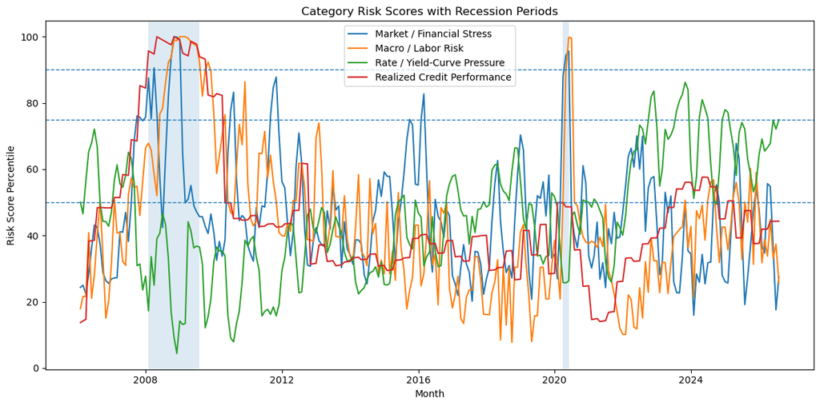

```python
## Recession category behavior Chart

import matplotlib.pyplot as plt

recession_scores = pd.read_sql_query(
    """
    SELECT
        month_end,
        usrec,
        market_financial_stress_score_expanding,
        macro_labor_risk_score_expanding,
        rate_yield_curve_pressure_score_expanding,
        realized_credit_performance_score_expanding
    FROM credit_risk_category_scores
    WHERE month_end >= '2006-01-31'
    ORDER BY month_end;
    """,
    conn
)

recession_scores["month_end"] = pd.to_datetime(recession_scores["month_end"])

plt.figure(figsize=(12, 6))

plt.plot(
    recession_scores["month_end"],
    recession_scores["market_financial_stress_score_expanding"],
    label="Market / Financial Stress"
)

plt.plot(
    recession_scores["month_end"],
    recession_scores["macro_labor_risk_score_expanding"],
    label="Macro / Labor Risk"
)

plt.plot(
    recession_scores["month_end"],
    recession_scores["rate_yield_curve_pressure_score_expanding"],
    label="Rate / Yield-Curve Pressure"
)

plt.plot(
    recession_scores["month_end"],
    recession_scores["realized_credit_performance_score_expanding"],
    label="Realized Credit Performance"
)

# Shade recession months
recession_months = recession_scores[recession_scores["usrec"] == 1]

for date in recession_months["month_end"]:
    plt.axvspan(date, date + pd.offsets.MonthEnd(1), alpha=0.15)

plt.axhline(50, linestyle="--", linewidth=1)
plt.axhline(75, linestyle="--", linewidth=1)
plt.axhline(90, linestyle="--", linewidth=1)

plt.title("Category Risk Scores with Recession Periods")
plt.xlabel("Month")
plt.ylabel("Risk Score Percentile")
plt.legend()
plt.tight_layout()
plt.show()
```

### Macro Labor Risk Band Check

The following query isolates months where the macro labor risk category is classified as Watch, Elevated, or Stress. This helps evaluate whether unemployment-level and unemployment-change features identify periods of labor-market deterioration.

Questions to ask: When did labor conditions start flashing above Normal? Did those periods cluster around recessions? Did they continue after recessions because labor data lag?

```python
## Macro labor Risk Table

macro_labor_risk_periods = pd.read_sql_query(
    """
    SELECT
        month_end,
        macro_labor_risk_score_expanding,
        macro_labor_risk_band_expanding,
        usrec,
        input_coverage_pct,
        provisional_input_flag
    FROM credit_risk_category_scores
    WHERE macro_labor_risk_band_expanding IN ('Watch', 'Elevated', 'Stress')
    ORDER BY month_end;
    """,
    conn
)

pd.set_option("display.max_rows", 120)

macro_labor_risk_periods
```

|  | month_end | macro_labor_risk_score_expanding | macro_labor_risk_band_expanding | usrec | input_coverage_pct | provisional_input_flag |
| --- | --- | --- | --- | --- | --- | --- |
| 0 | 2006-08-31 | 50.738636 | Watch | 0.0 | 100.0 | 0 |
| 1 | 2007-01-31 | 50.746055 | Watch | 0.0 | 100.0 | 0 |
| 2 | 2007-06-30 | 52.385057 | Watch | 0.0 | 100.0 | 0 |
| 3 | 2007-07-31 | 57.411339 | Watch | 0.0 | 100.0 | 0 |
| 4 | 2007-08-31 | 54.488276 | Watch | 0.0 | 100.0 | 0 |
| 5 | 2007-09-30 | 54.919355 | Watch | 0.0 | 100.0 | 0 |
| 6 | 2007-11-30 | 56.395881 | Watch | 0.0 | 100.0 | 0 |
| 7 | 2007-12-31 | 66.490255 | Watch | 0.0 | 100.0 | 0 |
| 8 | 2008-01-31 | 67.860276 | Watch | 1.0 | 100.0 | 0 |
| 9 | 2008-02-29 | 65.789474 | Watch | 1.0 | 100.0 | 0 |
| 10 | 2008-03-31 | 58.546402 | Watch | 1.0 | 100.0 | 0 |
| 11 | 2008-04-30 | 52.015464 | Watch | 1.0 | 100.0 | 0 |
| 12 | 2008-05-31 | 76.664478 | Elevated | 1.0 | 100.0 | 0 |
| 13 | 2008-06-30 | 78.357100 | Elevated | 1.0 | 100.0 | 0 |
| 14 | 2008-07-31 | 85.922330 | Elevated | 1.0 | 100.0 | 0 |
| 15 | 2008-08-31 | 92.264851 | Stress | 1.0 | 100.0 | 0 |
| 16 | 2008-09-30 | 93.704482 | Stress | 1.0 | 100.0 | 0 |
| 17 | 2008-10-31 | 99.029126 | Stress | 1.0 | 100.0 | 0 |
| 18 | 2008-11-30 | 98.798077 | Stress | 1.0 | 100.0 | 0 |
| 19 | 2008-12-31 | 100.000000 | Stress | 1.0 | 100.0 | 0 |
| 20 | 2009-01-31 | 100.000000 | Stress | 1.0 | 100.0 | 0 |
| 21 | 2009-02-28 | 100.000000 | Stress | 1.0 | 100.0 | 0 |
| 22 | 2009-03-31 | 99.537037 | Stress | 1.0 | 100.0 | 0 |
| 23 | 2009-04-30 | 98.394495 | Stress | 1.0 | 100.0 | 0 |
| 24 | 2009-05-31 | 97.727273 | Stress | 1.0 | 100.0 | 0 |
| 25 | 2009-06-30 | 97.297297 | Stress | 1.0 | 100.0 | 0 |
| 26 | 2009-07-31 | 92.410714 | Stress | 0.0 | 100.0 | 0 |
| 27 | 2009-08-31 | 82.079646 | Elevated | 0.0 | 100.0 | 0 |
| 28 | 2009-09-30 | 89.912281 | Elevated | 0.0 | 100.0 | 0 |
| 29 | 2009-10-31 | 92.391304 | Stress | 0.0 | 100.0 | 0 |
| 30 | 2009-11-30 | 89.439655 | Elevated | 0.0 | 100.0 | 0 |
| 31 | 2009-12-31 | 76.923077 | Elevated | 0.0 | 100.0 | 0 |
| 32 | 2010-01-31 | 58.707452 | Watch | 0.0 | 100.0 | 0 |
| 33 | 2010-02-28 | 63.896542 | Watch | 0.0 | 100.0 | 0 |
| 34 | 2010-03-31 | 70.243902 | Watch | 0.0 | 100.0 | 0 |
| 35 | 2010-04-30 | 76.471274 | Elevated | 0.0 | 100.0 | 0 |
| 36 | 2010-05-31 | 50.268852 | Watch | 0.0 | 100.0 | 0 |
| 37 | 2010-08-31 | 60.721875 | Watch | 0.0 | 100.0 | 0 |
| 38 | 2010-09-30 | 73.523440 | Watch | 0.0 | 100.0 | 0 |
| 39 | 2010-10-31 | 67.436402 | Watch | 0.0 | 100.0 | 0 |
| 40 | 2010-11-30 | 86.417581 | Elevated | 0.0 | 100.0 | 0 |
| 41 | 2010-12-31 | 55.532065 | Watch | 0.0 | 100.0 | 0 |
| 42 | 2011-04-30 | 64.844096 | Watch | 0.0 | 100.0 | 0 |
| 43 | 2011-05-31 | 64.736082 | Watch | 0.0 | 100.0 | 0 |
| 44 | 2011-06-30 | 71.465378 | Watch | 0.0 | 100.0 | 0 |
| 45 | 2011-07-31 | 57.543377 | Watch | 0.0 | 100.0 | 0 |
| 46 | 2011-08-31 | 64.242701 | Watch | 0.0 | 100.0 | 0 |
| 47 | 2011-09-30 | 56.194110 | Watch | 0.0 | 100.0 | 0 |
| 48 | 2011-10-31 | 50.400243 | Watch | 0.0 | 100.0 | 0 |
| 49 | 2012-04-30 | 50.603448 | Watch | 0.0 | 100.0 | 0 |
| 50 | 2012-05-31 | 50.433254 | Watch | 0.0 | 100.0 | 0 |
| 51 | 2012-06-30 | 61.826531 | Watch | 0.0 | 100.0 | 0 |
| 52 | 2012-07-31 | 61.748255 | Watch | 0.0 | 100.0 | 0 |
| 53 | 2012-08-31 | 54.298393 | Watch | 0.0 | 100.0 | 0 |
| 54 | 2012-12-31 | 69.560709 | Watch | 0.0 | 100.0 | 0 |
| 55 | 2013-01-31 | 73.974274 | Watch | 0.0 | 100.0 | 0 |
| 56 | 2013-02-28 | 60.917722 | Watch | 0.0 | 100.0 | 0 |
| 57 | 2013-06-30 | 59.576636 | Watch | 0.0 | 100.0 | 0 |
| 58 | 2013-10-31 | 52.003104 | Watch | 0.0 | 100.0 | 0 |
| 59 | 2014-03-31 | 58.362051 | Watch | 0.0 | 100.0 | 0 |
| 60 | 2014-07-31 | 57.177741 | Watch | 0.0 | 100.0 | 0 |
| 61 | 2015-01-31 | 50.182351 | Watch | 0.0 | 100.0 | 0 |
| 62 | 2015-05-31 | 52.980398 | Watch | 0.0 | 100.0 | 0 |
| 63 | 2016-04-30 | 56.511711 | Watch | 0.0 | 100.0 | 0 |
| 64 | 2020-03-31 | 51.730967 | Watch | 1.0 | 100.0 | 0 |
| 65 | 2020-04-30 | 89.549180 | Elevated | 1.0 | 100.0 | 0 |
| 66 | 2020-05-31 | 99.793388 | Stress | 0.0 | 100.0 | 0 |
| 67 | 2020-06-30 | 99.588477 | Stress | 0.0 | 100.0 | 0 |
| 68 | 2020-07-31 | 50.002489 | Watch | 0.0 | 100.0 | 0 |
| 69 | 2023-10-31 | 50.650189 | Watch | 0.0 | 100.0 | 0 |
| 70 | 2024-06-30 | 50.845080 | Watch | 0.0 | 100.0 | 0 |
| 71 | 2024-07-31 | 56.128976 | Watch | 0.0 | 100.0 | 0 |
| 72 | 2024-08-31 | 56.783276 | Watch | 0.0 | 100.0 | 0 |
| 73 | 2025-03-31 | 52.037954 | Watch | 0.0 | 100.0 | 0 |
| 74 | 2025-04-30 | 56.010120 | Watch | 0.0 | 100.0 | 0 |
| 75 | 2025-07-31 | 50.107685 | Watch | 0.0 | 100.0 | 0 |
| 76 | 2025-09-30 | 60.226696 | Watch | 0.0 | 100.0 | 0 |
| 77 | 2025-11-30 | 58.984101 | Watch | 0.0 | 100.0 | 0 |

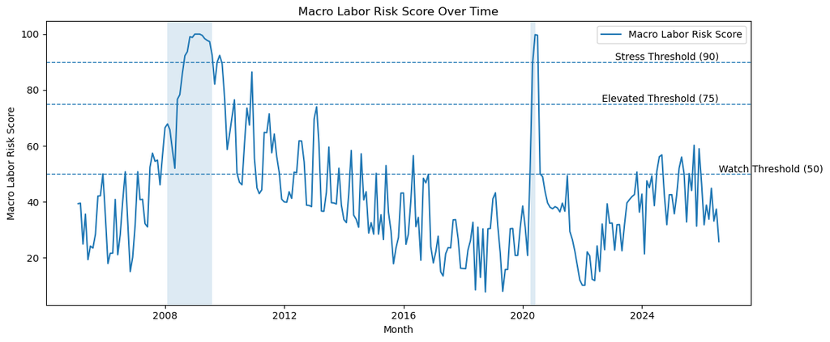

```python
## Line Chart Visual for check

macro_labor_visual = pd.read_sql_query(
    """
    SELECT
        month_end,
        macro_labor_risk_score_expanding,
        macro_labor_risk_band_expanding,
        usrec
    FROM credit_risk_category_scores
    WHERE month_end >= '2005-01-31'
    ORDER BY month_end;
    """,
    conn
)

macro_labor_visual["month_end"] = pd.to_datetime(macro_labor_visual["month_end"])

plt.figure(figsize=(12, 5))

plt.plot(
    macro_labor_visual["month_end"],
    macro_labor_visual["macro_labor_risk_score_expanding"],
    label="Macro Labor Risk Score"
)

recession_months = macro_labor_visual[macro_labor_visual["usrec"] == 1]
for date in recession_months["month_end"]:
    plt.axvspan(date, date + pd.offsets.MonthEnd(1), alpha=0.15)

plt.axhline(50, linestyle="--", linewidth=1)
plt.axhline(75, linestyle="--", linewidth=1)
plt.axhline(90, linestyle="--", linewidth=1)

# Add threshold labels on the right side
x_right = macro_labor_visual["month_end"].max()
plt.text(x_right, 50, "Watch Threshold (50)", va="bottom", ha="left")
plt.text(x_right, 75, "Elevated Threshold (75)", va="bottom", ha="right")
plt.text(x_right, 90, "Stress Threshold (90)", va="bottom", ha="right")

plt.title("Macro Labor Risk Score Over Time")
plt.xlabel("Month")
plt.ylabel("Macro Labor Risk Score")
plt.legend()
plt.tight_layout()
plt.show()
```

### Macro Labor Risk Band Check Interpretation

The macro labor risk score rises during periods of labor-market deterioration, but it does not consistently act as the earliest warning signal before recessions. This is expected because unemployment-related measures are often coincident or lagging indicators.

The chart shows that labor risk can remain elevated after the initial market-stress phase because unemployment conditions and labor-market weakness often persist after financial conditions first deteriorate. In this dashboard, Macro / Labor Risk is most useful as a confirmation and persistence measure rather than as the fastest-moving early-warning category.

This answers the band-check question: labor conditions do flash above Normal around major deterioration periods, but the signal tends to cluster around and after recessions rather than always leading them.

### Category Band Distribution

The following query counts how often each category enters each risk band. This checks whether the model is too aggressive, too conservative, or reasonably distributed across Normal, Watch, Elevated, and Stress conditions.

Questions to ask: If almost everything is Normal, thresholds may be too conservative. If too many months are Stress, thresholds may be too sensitive. If bands cluster around known stress periods, the bands are behaving reasonably.

```python
category_band_counts = pd.read_sql_query(
    """
    SELECT *
    FROM (
        SELECT
            'Market / Financial Stress' AS category,
            market_financial_stress_band_expanding AS band,
            COUNT(*) AS month_count
        FROM credit_risk_category_scores
        GROUP BY market_financial_stress_band_expanding

        UNION ALL

        SELECT
            'Macro / Labor Risk' AS category,
            macro_labor_risk_band_expanding AS band,
            COUNT(*) AS month_count
        FROM credit_risk_category_scores
        GROUP BY macro_labor_risk_band_expanding

        UNION ALL

        SELECT
            'Rate / Yield-Curve Pressure' AS category,
            rate_yield_curve_pressure_band_expanding AS band,
            COUNT(*) AS month_count
        FROM credit_risk_category_scores
        GROUP BY rate_yield_curve_pressure_band_expanding

        UNION ALL

        SELECT
            'Realized Credit Performance' AS category,
            realized_credit_performance_band_expanding AS band,
            COUNT(*) AS month_count
        FROM credit_risk_category_scores
        GROUP BY realized_credit_performance_band_expanding
    )
    ORDER BY
        CASE category
            WHEN 'Market / Financial Stress' THEN 1
            WHEN 'Macro / Labor Risk' THEN 2
            WHEN 'Rate / Yield-Curve Pressure' THEN 3
            WHEN 'Realized Credit Performance' THEN 4
        END,
        CASE band
            WHEN 'Insufficient History' THEN 1
            WHEN 'Normal' THEN 2
            WHEN 'Watch' THEN 3
            WHEN 'Elevated' THEN 4
            WHEN 'Stress' THEN 5
        END;
    """,
    conn
)

category_band_counts
```

|  | category | band | month_count |
| --- | --- | --- | --- |
| 0 | Market / Financial Stress | Insufficient History | 59 |
| 1 | Market / Financial Stress | Normal | 175 |
| 2 | Market / Financial Stress | Watch | 63 |
| 3 | Market / Financial Stress | Elevated | 15 |
| 4 | Market / Financial Stress | Stress | 7 |
| 5 | Macro / Labor Risk | Insufficient History | 59 |
| 6 | Macro / Labor Risk | Normal | 182 |
| 7 | Macro / Labor Risk | Watch | 53 |
| 8 | Macro / Labor Risk | Elevated | 10 |
| 9 | Macro / Labor Risk | Stress | 15 |
| 10 | Rate / Yield-Curve Pressure | Insufficient History | 59 |
| 11 | Rate / Yield-Curve Pressure | Normal | 162 |
| 12 | Rate / Yield-Curve Pressure | Watch | 85 |
| 13 | Rate / Yield-Curve Pressure | Elevated | 13 |
| 14 | Realized Credit Performance | Insufficient History | 59 |
| 15 | Realized Credit Performance | Normal | 200 |
| 16 | Realized Credit Performance | Watch | 30 |
| 17 | Realized Credit Performance | Elevated | 9 |
| 18 | Realized Credit Performance | Stress | 21 |

### Category Band Validation Visuals

The following visuals validate whether the category risk bands behave reasonably across recession periods, labor-risk deterioration periods, and the full historical distribution of category bands. These charts are not the final dashboard visuals. They are model-validation checks used before constructing the composite credit-risk score.

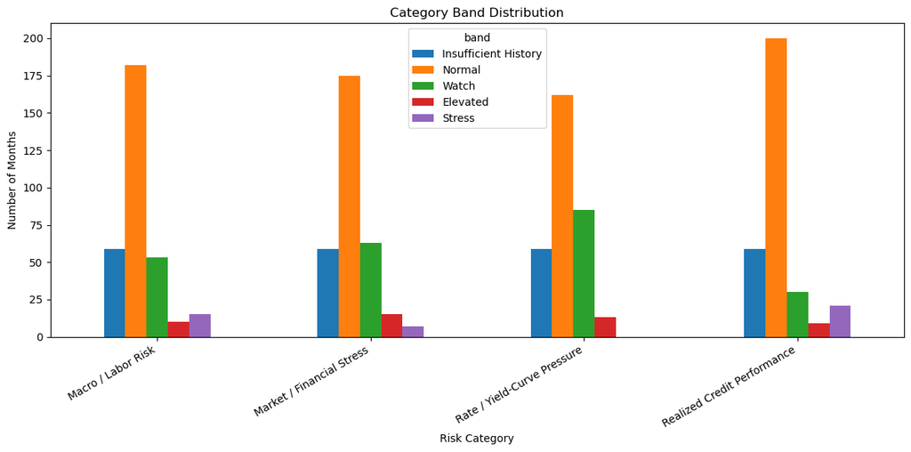

```python
category_band_counts

band_order = ["Insufficient History", "Normal", "Watch", "Elevated", "Stress"]

band_pivot = category_band_counts.pivot(
    index="category",
    columns="band",
    values="month_count"
).reindex(columns=band_order)

band_pivot.plot(
    kind="bar",
    figsize=(12, 6)
)

plt.title("Category Band Distribution")
plt.xlabel("Risk Category")
plt.ylabel("Number of Months")
plt.xticks(rotation=30, ha="right")
plt.tight_layout()
plt.show()
```

### Category Band Distribution Interpretation

The category band distribution shows that the scorecard is not overly aggressive. Most post-warm-up months are classified as Normal, while Watch, Elevated, and Stress periods occur less frequently. This is desirable for a monitoring framework because stress labels should identify unusual risk conditions rather than ordinary monthly noise.

The Rate / Yield-Curve Pressure category has a relatively high number of Watch months, which is reasonable because rate pressure and yield-curve inversion can persist for extended periods before realized credit deterioration appears. The Realized Credit Performance category shows fewer Watch and Elevated months but more Stress months than some other categories, reflecting the lagging nature of delinquency and charge-off data. Once realized credit deterioration appears, it can remain elevated after the initial market shock.

The category results support the intended structure of the dashboard: market and rate indicators provide faster-moving warning signals, while labor and realized credit indicators provide confirmation that stress is broadening into the real economy and bank credit performance.

### Recession vs. Non-Recession Category Score Check

This validation check compares average category risk scores during NBER recession months against non-recession months. The goal is to test whether the category framework produces economically sensible separation between normal periods and recession periods.

This is not a predictive model test yet. It is a reasonableness check. If the scoring framework is useful, stress-sensitive categories should generally show higher average scores during recession periods than during non-recession periods.

```python
recession_band_summary = pd.read_sql_query(
    """
    SELECT
        CASE
            WHEN usrec = 1 THEN 'Recession'
            ELSE 'Non-Recession'
        END AS recession_status,

        AVG(market_financial_stress_score_expanding) AS avg_market_financial_stress_score,
        AVG(macro_labor_risk_score_expanding) AS avg_macro_labor_risk_score,
        AVG(rate_yield_curve_pressure_score_expanding) AS avg_rate_yield_curve_pressure_score,
        AVG(realized_credit_performance_score_expanding) AS avg_realized_credit_performance_score,

        COUNT(*) AS month_count
    FROM credit_risk_category_scores
    WHERE expanding_percentile_coverage_pct = 100
    GROUP BY recession_status;
    """,
    conn
)

recession_band_summary
```

|  | recession_status | avg_market_financial_stress_score | avg_macro_labor_risk_score | avg_rate_yield_curve_pressure_score | avg_realized_credit_performance_score | month_count |
| --- | --- | --- | --- | --- | --- | --- |
| 0 | Non-Recession | 43.784217 | 39.705382 | 46.980699 | 41.330958 | 235 |
| 1 | Recession | 73.389233 | 85.159415 | 28.009758 | 92.698303 | 20 |

### Recession vs Non-Recession Category Score Validation

The recession comparison provides an initial validation check for the category score framework. Market / Financial Stress, Macro / Labor Risk, and Realized Credit Performance all show materially higher average scores during recession months than during non-recession months. This supports the interpretation that the category scores are capturing economically meaningful stress conditions rather than random noise.

The Rate / Yield-Curve Pressure category behaves differently. Its average score is lower during recession months than non-recession months. This does not necessarily invalidate the category. Rate and yield-curve pressure can act as a pre-recession warning signal rather than a recession-month confirmation signal. Yield-curve inversion and long-rate pressure often appear before recession periods, while rate cuts and curve steepening can occur once recession conditions begin.

### 7.6 Composite Credit-Risk Score

The composite credit-risk score combines the four category-level scores into one final monthly risk indicator. The purpose is to create a single dashboard KPI that summarizes the overall state of macro-credit conditions while preserving the category-level detail used for interpretation.

The baseline composite score uses equal category weights:

- Market / Financial Stress: 25%
- Macro / Labor Risk: 25%
- Rate / Yield-Curve Pressure: 25%
- Realized Credit Performance: 25%

Equal weighting is used as the first version because it is transparent, easy to explain, and avoids overfitting weights before validation. Later sections can test whether alternative weighting schemes improve recession separation or forward-market interpretation. The composite score uses the expanding-percentile category scores. Retrospective percentiles are not used in the final operational composite because they would use information from the full sample and introduce lookahead bias.

The composite score answers the following questions:

1. What is the overall credit-risk regime in each month?
2. Which category is driving the current risk score?
3. Are risk conditions normal, watch-level, elevated, or stressed?
4. Is the score based on complete input coverage or a provisional data state?
5. Does the composite score behave sensibly during known stress periods?

This section constructs the score. It does not yet prove predictive power. Validation against recession periods and forward S&P 500 returns is handled in the next section.

### Composite Score Construction

The following code creates the composite score from `credit_risk_category_scores`. Missing category scores are not replaced with zero. The score is calculated from available category scores, and a coverage percentage is retained to show whether the score is complete or provisional.

```python
composite_scores = pd.read_sql_query(
    """
    SELECT
        month_end,

        market_financial_stress_score_expanding,
        macro_labor_risk_score_expanding,
        rate_yield_curve_pressure_score_expanding,
        realized_credit_performance_score_expanding,

        market_financial_stress_band_expanding,
        macro_labor_risk_band_expanding,
        rate_yield_curve_pressure_band_expanding,
        realized_credit_performance_band_expanding,

        input_coverage_pct,
        expanding_percentile_coverage_pct,
        provisional_input_flag,

        usrec,
        sp500_forward_1m_return,
        sp500_forward_3m_return,
        sp500_forward_6m_return

    FROM credit_risk_category_scores
    ORDER BY month_end;
    """,
    conn
)

composite_scores["month_end"] = pd.to_datetime(composite_scores["month_end"])

category_score_columns = [
    "market_financial_stress_score_expanding",
    "macro_labor_risk_score_expanding",
    "rate_yield_curve_pressure_score_expanding",
    "realized_credit_performance_score_expanding"
]

# Equal-weight composite score.
# mean() skips missing values by default.
composite_scores["composite_credit_risk_score"] = (
    composite_scores[category_score_columns]
    .mean(axis=1, skipna=True)
)

# Coverage: how many category scores are available for the composite.
composite_scores["composite_score_coverage_pct"] = (
    composite_scores[category_score_columns]
    .notna()
    .mean(axis=1)
    * 100
)

def assign_composite_regime(score):
    if pd.isna(score):
        return "Insufficient History"
    elif score < 50:
        return "Normal"
    elif score < 75:
        return "Watch"
    elif score < 90:
        return "Elevated"
    else:
        return "Stress"

composite_scores["composite_credit_risk_regime"] = (
    composite_scores["composite_credit_risk_score"]
    .apply(assign_composite_regime)
)

# Flag incomplete composite scores.
composite_scores["provisional_composite_flag"] = (
    (composite_scores["composite_score_coverage_pct"] < 100) |
    (composite_scores["provisional_input_flag"] == 1)
).astype(int)

composite_scores_sql = composite_scores.copy()
composite_scores_sql["month_end"] = (
    composite_scores_sql["month_end"]
    .dt.strftime("%Y-%m-%d")
)

composite_scores_sql.to_sql(
    "credit_risk_composite_scores",
    conn,
    if_exists="replace",
    index=False
)

conn.commit()

print("Created SQLite table: credit_risk_composite_scores")
print("Rows:", len(composite_scores_sql))
```

```
Created SQLite table: credit_risk_composite_scores
Rows: 319
```

```python
composite_preview = pd.read_sql_query(
    """
    SELECT
        month_end,
        composite_credit_risk_score,
        composite_credit_risk_regime,
        composite_score_coverage_pct,
        provisional_composite_flag,

        market_financial_stress_score_expanding,
        macro_labor_risk_score_expanding,
        rate_yield_curve_pressure_score_expanding,
        realized_credit_performance_score_expanding,

        usrec
    FROM credit_risk_composite_scores
    ORDER BY month_end
    LIMIT 80;
    """,
    conn
)

composite_preview
```

|  | month_end | composite_credit_risk_score | composite_credit_risk_regime | composite_score_coverage_pct | provisional_composite_flag | market_financial_stress_score_expanding | macro_labor_risk_score_expanding | rate_yield_curve_pressure_score_expanding | realized_credit_performance_score_expanding | usrec |
| --- | --- | --- | --- | --- | --- | --- | --- | --- | --- | --- |
| 0 | 2000-01-31 | NaN | Insufficient History | 0.0 | 1 | NaN | NaN | NaN | NaN | 0.0 |
| 1 | 2000-02-29 | NaN | Insufficient History | 0.0 | 1 | NaN | NaN | NaN | NaN | 0.0 |
| 2 | 2000-03-31 | NaN | Insufficient History | 0.0 | 1 | NaN | NaN | NaN | NaN | 0.0 |
| 3 | 2000-04-30 | NaN | Insufficient History | 0.0 | 1 | NaN | NaN | NaN | NaN | 0.0 |
| 4 | 2000-05-31 | NaN | Insufficient History | 0.0 | 1 | NaN | NaN | NaN | NaN | 0.0 |
| 5 | 2000-06-30 | NaN | Insufficient History | 0.0 | 1 | NaN | NaN | NaN | NaN | 0.0 |
| 6 | 2000-07-31 | NaN | Insufficient History | 0.0 | 1 | NaN | NaN | NaN | NaN | 0.0 |
| 7 | 2000-08-31 | NaN | Insufficient History | 0.0 | 1 | NaN | NaN | NaN | NaN | 0.0 |
| 8 | 2000-09-30 | NaN | Insufficient History | 0.0 | 1 | NaN | NaN | NaN | NaN | 0.0 |
| 9 | 2000-10-31 | NaN | Insufficient History | 0.0 | 1 | NaN | NaN | NaN | NaN | 0.0 |
| 10 | 2000-11-30 | NaN | Insufficient History | 0.0 | 1 | NaN | NaN | NaN | NaN | 0.0 |
| 11 | 2000-12-31 | NaN | Insufficient History | 0.0 | 1 | NaN | NaN | NaN | NaN | 0.0 |
| 12 | 2001-01-31 | NaN | Insufficient History | 0.0 | 1 | NaN | NaN | NaN | NaN | 0.0 |
| 13 | 2001-02-28 | NaN | Insufficient History | 0.0 | 1 | NaN | NaN | NaN | NaN | 0.0 |
| 14 | 2001-03-31 | NaN | Insufficient History | 0.0 | 1 | NaN | NaN | NaN | NaN | 0.0 |
| 15 | 2001-04-30 | NaN | Insufficient History | 0.0 | 1 | NaN | NaN | NaN | NaN | 1.0 |
| 16 | 2001-05-31 | NaN | Insufficient History | 0.0 | 1 | NaN | NaN | NaN | NaN | 1.0 |
| 17 | 2001-06-30 | NaN | Insufficient History | 0.0 | 1 | NaN | NaN | NaN | NaN | 1.0 |
| 18 | 2001-07-31 | NaN | Insufficient History | 0.0 | 1 | NaN | NaN | NaN | NaN | 1.0 |
| 19 | 2001-08-31 | NaN | Insufficient History | 0.0 | 1 | NaN | NaN | NaN | NaN | 1.0 |
| 20 | 2001-09-30 | NaN | Insufficient History | 0.0 | 1 | NaN | NaN | NaN | NaN | 1.0 |
| 21 | 2001-10-31 | NaN | Insufficient History | 0.0 | 1 | NaN | NaN | NaN | NaN | 1.0 |
| 22 | 2001-11-30 | NaN | Insufficient History | 0.0 | 1 | NaN | NaN | NaN | NaN | 1.0 |
| 23 | 2001-12-31 | NaN | Insufficient History | 0.0 | 1 | NaN | NaN | NaN | NaN | 0.0 |
| 24 | 2002-01-31 | NaN | Insufficient History | 0.0 | 1 | NaN | NaN | NaN | NaN | 0.0 |
| 25 | 2002-02-28 | NaN | Insufficient History | 0.0 | 1 | NaN | NaN | NaN | NaN | 0.0 |
| 26 | 2002-03-31 | NaN | Insufficient History | 0.0 | 1 | NaN | NaN | NaN | NaN | 0.0 |
| 27 | 2002-04-30 | NaN | Insufficient History | 0.0 | 1 | NaN | NaN | NaN | NaN | 0.0 |
| 28 | 2002-05-31 | NaN | Insufficient History | 0.0 | 1 | NaN | NaN | NaN | NaN | 0.0 |
| 29 | 2002-06-30 | NaN | Insufficient History | 0.0 | 1 | NaN | NaN | NaN | NaN | 0.0 |
| 30 | 2002-07-31 | NaN | Insufficient History | 0.0 | 1 | NaN | NaN | NaN | NaN | 0.0 |
| 31 | 2002-08-31 | NaN | Insufficient History | 0.0 | 1 | NaN | NaN | NaN | NaN | 0.0 |
| 32 | 2002-09-30 | NaN | Insufficient History | 0.0 | 1 | NaN | NaN | NaN | NaN | 0.0 |
| 33 | 2002-10-31 | NaN | Insufficient History | 0.0 | 1 | NaN | NaN | NaN | NaN | 0.0 |
| 34 | 2002-11-30 | NaN | Insufficient History | 0.0 | 1 | NaN | NaN | NaN | NaN | 0.0 |
| 35 | 2002-12-31 | NaN | Insufficient History | 0.0 | 1 | NaN | NaN | NaN | NaN | 0.0 |
| 36 | 2003-01-31 | NaN | Insufficient History | 0.0 | 1 | NaN | NaN | NaN | NaN | 0.0 |
| 37 | 2003-02-28 | NaN | Insufficient History | 0.0 | 1 | NaN | NaN | NaN | NaN | 0.0 |
| 38 | 2003-03-31 | NaN | Insufficient History | 0.0 | 1 | NaN | NaN | NaN | NaN | 0.0 |
| 39 | 2003-04-30 | NaN | Insufficient History | 0.0 | 1 | NaN | NaN | NaN | NaN | 0.0 |
| 40 | 2003-05-31 | NaN | Insufficient History | 0.0 | 1 | NaN | NaN | NaN | NaN | 0.0 |
| 41 | 2003-06-30 | NaN | Insufficient History | 0.0 | 1 | NaN | NaN | NaN | NaN | 0.0 |
| 42 | 2003-07-31 | NaN | Insufficient History | 0.0 | 1 | NaN | NaN | NaN | NaN | 0.0 |
| 43 | 2003-08-31 | NaN | Insufficient History | 0.0 | 1 | NaN | NaN | NaN | NaN | 0.0 |
| 44 | 2003-09-30 | NaN | Insufficient History | 0.0 | 1 | NaN | NaN | NaN | NaN | 0.0 |
| 45 | 2003-10-31 | NaN | Insufficient History | 0.0 | 1 | NaN | NaN | NaN | NaN | 0.0 |
| 46 | 2003-11-30 | NaN | Insufficient History | 0.0 | 1 | NaN | NaN | NaN | NaN | 0.0 |
| 47 | 2003-12-31 | NaN | Insufficient History | 0.0 | 1 | NaN | NaN | NaN | NaN | 0.0 |
| 48 | 2004-01-31 | NaN | Insufficient History | 0.0 | 1 | NaN | NaN | NaN | NaN | 0.0 |
| 49 | 2004-02-29 | NaN | Insufficient History | 0.0 | 1 | NaN | NaN | NaN | NaN | 0.0 |
| 50 | 2004-03-31 | NaN | Insufficient History | 0.0 | 1 | NaN | NaN | NaN | NaN | 0.0 |
| 51 | 2004-04-30 | NaN | Insufficient History | 0.0 | 1 | NaN | NaN | NaN | NaN | 0.0 |
| 52 | 2004-05-31 | NaN | Insufficient History | 0.0 | 1 | NaN | NaN | NaN | NaN | 0.0 |
| 53 | 2004-06-30 | NaN | Insufficient History | 0.0 | 1 | NaN | NaN | NaN | NaN | 0.0 |
| 54 | 2004-07-31 | NaN | Insufficient History | 0.0 | 1 | NaN | NaN | NaN | NaN | 0.0 |
| 55 | 2004-08-31 | NaN | Insufficient History | 0.0 | 1 | NaN | NaN | NaN | NaN | 0.0 |
| 56 | 2004-09-30 | NaN | Insufficient History | 0.0 | 1 | NaN | NaN | NaN | NaN | 0.0 |
| 57 | 2004-10-31 | NaN | Insufficient History | 0.0 | 1 | NaN | NaN | NaN | NaN | 0.0 |
| 58 | 2004-11-30 | NaN | Insufficient History | 0.0 | 1 | NaN | NaN | NaN | NaN | 0.0 |
| 59 | 2004-12-31 | 21.562500 | Normal | 100.0 | 0 | 3.333333 | 42.500000 | 35.833333 | 4.583333 | 0.0 |
| 60 | 2005-01-31 | 20.901639 | Normal | 100.0 | 0 | 3.278689 | 39.344262 | 39.344262 | 1.639344 | 0.0 |
| 61 | 2005-02-28 | 20.833333 | Normal | 100.0 | 0 | 2.688172 | 39.516129 | 38.709677 | 2.419355 | 0.0 |
| 62 | 2005-03-31 | 27.807540 | Normal | 100.0 | 0 | 24.113757 | 24.880952 | 41.481481 | 20.753968 | 0.0 |
| 63 | 2005-04-30 | 33.322127 | Normal | 100.0 | 0 | 34.076161 | 35.572490 | 42.981557 | 20.658299 | 0.0 |
| 64 | 2005-05-31 | 32.316222 | Normal | 100.0 | 0 | 42.287014 | 19.305211 | 46.559140 | 21.113524 | 0.0 |
| 65 | 2005-06-30 | 28.702201 | Normal | 100.0 | 0 | 39.718615 | 24.170274 | 29.365079 | 21.554834 | 0.0 |
| 66 | 2005-07-31 | 32.152470 | Normal | 100.0 | 0 | 25.618004 | 23.449160 | 37.235697 | 42.307020 | 0.0 |
| 67 | 2005-08-31 | 36.211114 | Normal | 100.0 | 0 | 24.490950 | 28.484163 | 49.457014 | 42.412330 | 0.0 |
| 68 | 2005-09-30 | 43.456988 | Normal | 100.0 | 0 | 32.465964 | 42.061924 | 56.785244 | 42.514822 | 0.0 |
| 69 | 2005-10-31 | 43.496357 | Normal | 100.0 | 0 | 42.043355 | 42.174840 | 58.834399 | 30.932836 | 0.0 |
| 70 | 2005-11-30 | 44.755636 | Normal | 100.0 | 0 | 38.936067 | 49.958575 | 58.927092 | 31.200808 | 0.0 |
| 71 | 2005-12-31 | 40.120521 | Normal | 100.0 | 0 | 36.191626 | 34.797705 | 58.031401 | 31.461353 | 0.0 |
| 72 | 2006-01-31 | 26.515615 | Normal | 100.0 | 0 | 24.337900 | 17.925636 | 50.078278 | 13.720646 | 0.0 |
| 73 | 2006-02-28 | 26.837489 | Normal | 100.0 | 0 | 24.993656 | 21.583555 | 46.555006 | 14.217739 | 0.0 |
| 74 | 2006-03-31 | 28.811921 | Normal | 100.0 | 0 | 22.351852 | 21.638889 | 56.555556 | 14.701389 | 0.0 |
| 75 | 2006-04-30 | 43.219967 | Normal | 100.0 | 0 | 28.457702 | 40.857066 | 65.296804 | 38.268295 | 0.0 |
| 76 | 2006-05-31 | 40.891358 | Normal | 100.0 | 0 | 36.138411 | 21.081959 | 67.930268 | 38.414795 | 0.0 |
| 77 | 2006-06-30 | 45.485577 | Normal | 100.0 | 0 | 43.111111 | 28.153846 | 72.119658 | 38.557692 | 0.0 |
| 78 | 2006-07-31 | 49.473268 | Normal | 100.0 | 0 | 42.513324 | 40.277315 | 66.705530 | 48.396902 | 0.0 |
| 79 | 2006-08-31 | 46.458333 | Normal | 100.0 | 0 | 37.161797 | 50.738636 | 49.523810 | 48.409091 | 0.0 |

### Composite Score Warm-Up Interpretation

The initial rows of the composite score table show `NaN` values because the model uses expanding historical percentiles. These percentiles require a warm-up period before enough historical observations exist to calculate operational category scores.

During the warm-up period, the composite score is labeled `Insufficient History`, the composite score coverage is 0%, and the provisional composite flag equals 1. Once all four category scores are available, the composite score coverage rises to 100% and the provisional flag switches to 0.

These missing values are expected and do not indicate a data failure. They show that the model is avoiding lookahead bias by not assigning operational scores before enough historical information exists.

```python
first_operational_composite_scores = pd.read_sql_query(
    """
    SELECT
        month_end,
        composite_credit_risk_score,
        composite_credit_risk_regime,
        composite_score_coverage_pct,
        provisional_composite_flag,

        market_financial_stress_score_expanding,
        macro_labor_risk_score_expanding,
        rate_yield_curve_pressure_score_expanding,
        realized_credit_performance_score_expanding,

        usrec
    FROM credit_risk_composite_scores
    WHERE composite_score_coverage_pct = 100
    ORDER BY month_end
    LIMIT 21;
    """,
    conn
)

first_operational_composite_scores
```

|  | month_end | composite_credit_risk_score | composite_credit_risk_regime | composite_score_coverage_pct | provisional_composite_flag | market_financial_stress_score_expanding | macro_labor_risk_score_expanding | rate_yield_curve_pressure_score_expanding | realized_credit_performance_score_expanding | usrec |
| --- | --- | --- | --- | --- | --- | --- | --- | --- | --- | --- |
| 0 | 2004-12-31 | 21.562500 | Normal | 100.0 | 0 | 3.333333 | 42.500000 | 35.833333 | 4.583333 | 0.0 |
| 1 | 2005-01-31 | 20.901639 | Normal | 100.0 | 0 | 3.278689 | 39.344262 | 39.344262 | 1.639344 | 0.0 |
| 2 | 2005-02-28 | 20.833333 | Normal | 100.0 | 0 | 2.688172 | 39.516129 | 38.709677 | 2.419355 | 0.0 |
| 3 | 2005-03-31 | 27.807540 | Normal | 100.0 | 0 | 24.113757 | 24.880952 | 41.481481 | 20.753968 | 0.0 |
| 4 | 2005-04-30 | 33.322127 | Normal | 100.0 | 0 | 34.076161 | 35.572490 | 42.981557 | 20.658299 | 0.0 |
| 5 | 2005-05-31 | 32.316222 | Normal | 100.0 | 0 | 42.287014 | 19.305211 | 46.559140 | 21.113524 | 0.0 |
| 6 | 2005-06-30 | 28.702201 | Normal | 100.0 | 0 | 39.718615 | 24.170274 | 29.365079 | 21.554834 | 0.0 |
| 7 | 2005-07-31 | 32.152470 | Normal | 100.0 | 0 | 25.618004 | 23.449160 | 37.235697 | 42.307020 | 0.0 |
| 8 | 2005-08-31 | 36.211114 | Normal | 100.0 | 0 | 24.490950 | 28.484163 | 49.457014 | 42.412330 | 0.0 |
| 9 | 2005-09-30 | 43.456988 | Normal | 100.0 | 0 | 32.465964 | 42.061924 | 56.785244 | 42.514822 | 0.0 |
| 10 | 2005-10-31 | 43.496357 | Normal | 100.0 | 0 | 42.043355 | 42.174840 | 58.834399 | 30.932836 | 0.0 |
| 11 | 2005-11-30 | 44.755636 | Normal | 100.0 | 0 | 38.936067 | 49.958575 | 58.927092 | 31.200808 | 0.0 |
| 12 | 2005-12-31 | 40.120521 | Normal | 100.0 | 0 | 36.191626 | 34.797705 | 58.031401 | 31.461353 | 0.0 |
| 13 | 2006-01-31 | 26.515615 | Normal | 100.0 | 0 | 24.337900 | 17.925636 | 50.078278 | 13.720646 | 0.0 |
| 14 | 2006-02-28 | 26.837489 | Normal | 100.0 | 0 | 24.993656 | 21.583555 | 46.555006 | 14.217739 | 0.0 |
| 15 | 2006-03-31 | 28.811921 | Normal | 100.0 | 0 | 22.351852 | 21.638889 | 56.555556 | 14.701389 | 0.0 |
| 16 | 2006-04-30 | 43.219967 | Normal | 100.0 | 0 | 28.457702 | 40.857066 | 65.296804 | 38.268295 | 0.0 |
| 17 | 2006-05-31 | 40.891358 | Normal | 100.0 | 0 | 36.138411 | 21.081959 | 67.930268 | 38.414795 | 0.0 |
| 18 | 2006-06-30 | 45.485577 | Normal | 100.0 | 0 | 43.111111 | 28.153846 | 72.119658 | 38.557692 | 0.0 |
| 19 | 2006-07-31 | 49.473268 | Normal | 100.0 | 0 | 42.513324 | 40.277315 | 66.705530 | 48.396902 | 0.0 |
| 20 | 2006-08-31 | 46.458333 | Normal | 100.0 | 0 | 37.161797 | 50.738636 | 49.523810 | 48.409091 | 0.0 |

```python
latest_composite_scores = pd.read_sql_query(
    """
    SELECT
        month_end,
        composite_credit_risk_score,
        composite_credit_risk_regime,
        composite_score_coverage_pct,
        provisional_composite_flag,

        market_financial_stress_score_expanding,
        macro_labor_risk_score_expanding,
        rate_yield_curve_pressure_score_expanding,
        realized_credit_performance_score_expanding,

        usrec
    FROM credit_risk_composite_scores
    WHERE composite_score_coverage_pct = 100
    ORDER BY month_end DESC
    LIMIT 12;
    """,
    conn
)

latest_composite_scores
```

|  | month_end | composite_credit_risk_score | composite_credit_risk_regime | composite_score_coverage_pct | provisional_composite_flag | market_financial_stress_score_expanding | macro_labor_risk_score_expanding | rate_yield_curve_pressure_score_expanding | realized_credit_performance_score_expanding | usrec |
| --- | --- | --- | --- | --- | --- | --- | --- | --- | --- | --- |
| 0 | 2026-07-31 | 43.135887 | Normal | 100.0 | 0 | 27.541896 | 25.745762 | 74.943785 | 44.312106 | 0.0 |
| 1 | 2026-06-30 | 42.840783 | Normal | 100.0 | 0 | 17.559649 | 37.393755 | 72.115404 | 44.294325 | 0.0 |
| 2 | 2026-05-31 | 47.093258 | Normal | 100.0 | 0 | 36.193045 | 33.103312 | 74.800244 | 44.276432 | 0.0 |
| 3 | 2026-04-30 | 52.923240 | Watch | 100.0 | 0 | 54.767562 | 44.854797 | 67.812176 | 44.258427 | 0.0 |
| 4 | 2026-03-31 | 49.484414 | Normal | 100.0 | 0 | 55.651201 | 33.790323 | 66.539479 | 41.956654 | 0.0 |
| 5 | 2026-02-28 | 45.234477 | Normal | 100.0 | 0 | 34.700746 | 38.823872 | 65.482213 | 41.931078 | 0.0 |
| 6 | 2026-01-31 | 44.851528 | Normal | 100.0 | 1 | 36.571507 | 31.789137 | 69.140128 | 41.905339 | 0.0 |
| 7 | 2025-12-31 | 49.122852 | Normal | 100.0 | 0 | 48.005352 | 46.454587 | 64.405444 | 37.626027 | 0.0 |
| 8 | 2025-11-30 | 51.700071 | Watch | 100.0 | 0 | 54.278024 | 58.984101 | 55.952033 | 37.586128 | 0.0 |
| 9 | 2025-10-31 | 42.336433 | Normal | 100.0 | 1 | 47.318658 | 31.290323 | 53.190781 | 37.545970 | 0.0 |
| 10 | 2025-09-30 | 50.816498 | Watch | 100.0 | 0 | 36.871523 | 60.226696 | 58.640565 | 47.527207 | 0.0 |
| 11 | 2025-08-31 | 45.480038 | Normal | 100.0 | 0 | 27.536371 | 44.041409 | 62.823079 | 47.519294 | 0.0 |

### Composite Score Output Interpretation

The composite credit-risk score is now the main dashboard KPI. It combines the four category scores into one monthly risk score and assigns a regime label: Normal, Watch, Elevated, or Stress.

The latest operational rows show that the score is calculated with full category coverage when `composite_score_coverage_pct` equals 100 and `provisional_composite_flag` equals 0. These rows are the valid operational dashboard outputs.

The latest score should be interpreted alongside the category drivers. A Normal composite regime does not mean every risk category is benign; it means the equal-weighted average of the category scores remains below the Watch threshold. Category-level scores are retained so the dashboard can identify whether risk is being driven by market stress, labor deterioration, rate/yield-curve pressure, or realized credit performance.

```python
composite_summary = pd.read_sql_query(
    """
    SELECT
        COUNT(*) AS total_rows,
        MIN(month_end) AS first_month,
        MAX(month_end) AS last_month,

        MIN(
            CASE
                WHEN composite_score_coverage_pct = 100
                THEN month_end
            END
        ) AS first_operational_composite_month,

        SUM(
            CASE
                WHEN composite_credit_risk_regime = 'Normal'
                THEN 1 ELSE 0
            END
        ) AS normal_months,

        SUM(
            CASE
                WHEN composite_credit_risk_regime = 'Watch'
                THEN 1 ELSE 0
            END
        ) AS watch_months,

        SUM(
            CASE
                WHEN composite_credit_risk_regime = 'Elevated'
                THEN 1 ELSE 0
            END
        ) AS elevated_months,

        SUM(
            CASE
                WHEN composite_credit_risk_regime = 'Stress'
                THEN 1 ELSE 0
            END
        ) AS stress_months,

        SUM(provisional_composite_flag) AS provisional_months
    FROM credit_risk_composite_scores;
    """,
    conn
)

composite_summary
```

|  | total_rows | first_month | last_month | first_operational_composite_month | normal_months | watch_months | elevated_months | stress_months | provisional_months |
| --- | --- | --- | --- | --- | --- | --- | --- | --- | --- |
| 0 | 319 | 2000-01-31 | 2026-07-31 | 2004-12-31 | 198 | 57 | 5 | 0 | 61 |

### Composite Score Construction Summary

The composite score table confirms the full monthly scoring structure. Early rows remain provisional because the expanding percentile framework requires a historical warm-up period. Once the operational window begins, the model assigns a complete composite score and regime label for each month.

The regime counts provide an initial reasonableness check. A useful monitoring score should classify most months as Normal, some months as Watch, and fewer months as Elevated or Stress. The next section validates whether those regimes align with recession periods and forward market outcomes.

### Composite Score Construction Interpretation

The composite score was successfully constructed from the four category-level risk scores. The score uses equal category weights and produces a monthly regime label: Normal, Watch, Elevated, or Stress.

The summary output shows that most operational months are classified as Normal, with fewer months classified as Watch or Elevated. No months are currently classified as Stress under the initial threshold rule. This does not necessarily mean the model failed. It indicates that the Stress threshold of 90 may be conservative when the composite score is calculated as an equal-weighted average across four categories.

This is an important validation point for the next section. The threshold validation step will test whether the initial regime bands are appropriately calibrated or whether the Stress threshold should be adjusted after comparing score behavior against recession periods and forward market outcomes.

The composite coverage field confirms whether all four category scores are available. Category-level coverage and provisional flags are retained because a complete composite score can still depend on partial category-level information during early calibration periods or months with incomplete source data.

### 7.7 Threshold and Regime Validation

The previous section created the composite credit-risk score by averaging the four category-level risk scores: Market / Financial Stress, Macro / Labor Risk, Rate / Yield-Curve Pressure, and Realized Credit Performance. The composite score is now the main dashboard KPI, but it still needs to be validated before it can be interpreted as a useful monitoring signal.

This section evaluates whether the score behaves reasonably across known historical stress periods and whether the initial regime thresholds are properly calibrated.

The validation focuses on five questions:

1. Did the composite score rise during NBER recession periods?
2. Did higher composite scores align with known credit and market stress episodes?
3. Are the Normal, Watch, Elevated, and Stress thresholds too loose or too strict?
4. Does the score provide useful information beyond any single category score?
5. Do higher-risk regimes provide useful forward S&P 500 return context in the market-context overlay window?

This section does not claim causality and does not create a black-box recession prediction model. The goal is to test whether the transparent scorecard produces economically sensible risk regimes. If the validation shows that the current thresholds are too conservative, the thresholds can be revised and documented.

A key issue already identified is that the initial composite framework produced no Stress months. This may mean that the Stress threshold of 90 is too high for an equal-weighted composite score. The validation step will determine whether that threshold should remain unchanged or be recalibrated.

### 7.7.1 Composite Score vs. Recession Periods

The first validation check compares the composite credit-risk score across recession and non-recession months. If the scorecard is directionally useful, the average composite score should generally be higher during recession months than during non-recession months.

This is a reasonableness check, not a complete forecasting test. Recessions are used as known stress-period labels to evaluate whether the score rises during historically severe macro-credit conditions.

```python
composite_recession_summary = pd.read_sql_query(
    """
    SELECT
        CASE
            WHEN usrec = 1 THEN 'Recession'
            ELSE 'Non-Recession'
        END AS recession_status,

        AVG(composite_credit_risk_score) AS avg_composite_credit_risk_score,
        MIN(composite_credit_risk_score) AS min_composite_credit_risk_score,
        MAX(composite_credit_risk_score) AS max_composite_credit_risk_score,
        COUNT(*) AS month_count
    FROM credit_risk_composite_scores
    WHERE composite_score_coverage_pct = 100
    GROUP BY recession_status;
    """,
    conn
)

composite_recession_summary
```

|  | recession_status | avg_composite_credit_risk_score | min_composite_credit_risk_score | max_composite_credit_risk_score | month_count |
| --- | --- | --- | --- | --- | --- |
| 0 | Non-Recession | 42.682539 | 20.833333 | 67.601320 | 240 |
| 1 | Recession | 69.814177 | 53.893551 | 78.118386 | 20 |

### Composite Score vs. Recession Interpretation

The composite score is materially higher during recession months than during non-recession months. The average recession-month score is approximately 69.8, compared with approximately 42.7 during non-recession months. This supports the scorecardâ€™s directional validity: the composite score rises during historically severe macro-credit stress periods.

The minimum recession-month score is above 50, meaning all fully operational recession observations entered at least the Watch regime. This is a positive validation result because the model does not classify recession months as Normal.

However, the maximum recession-month score is approximately 78.1, which is far below the initial Stress threshold of 90. This suggests that the original Stress threshold may be too conservative for an equal-weighted composite score. The score separates recession and non-recession periods, but the regime bands may need recalibration after additional validation.

At this stage, the result supports the composite score as a useful monitoring KPI, but it also indicates that threshold calibration should be tested before finalizing the dashboard regime labels.

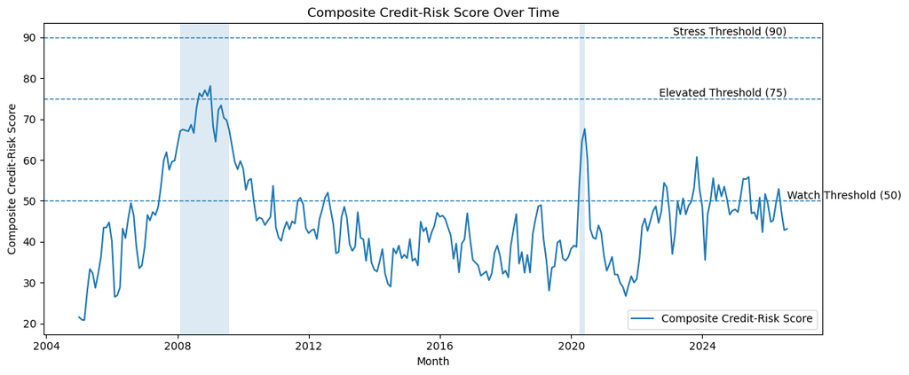

```python
composite_score_visual = pd.read_sql_query(
    """
    SELECT
        month_end,
        composite_credit_risk_score,
        composite_credit_risk_regime,
        usrec
    FROM credit_risk_composite_scores
    WHERE composite_score_coverage_pct = 100
    ORDER BY month_end;
    """,
    conn
)

composite_score_visual["month_end"] = pd.to_datetime(
    composite_score_visual["month_end"]
)

plt.figure(figsize=(12, 5))

plt.plot(
    composite_score_visual["month_end"],
    composite_score_visual["composite_credit_risk_score"],
    label="Composite Credit-Risk Score"
)

recession_months = composite_score_visual[
    composite_score_visual["usrec"] == 1
]

for date in recession_months["month_end"]:
    plt.axvspan(
        date,
        date + pd.offsets.MonthEnd(1),
        alpha=0.15
    )

plt.axhline(50, linestyle="--", linewidth=1)
plt.axhline(75, linestyle="--", linewidth=1)
plt.axhline(90, linestyle="--", linewidth=1)

x_right = composite_score_visual["month_end"].max()

plt.text(x_right, 50, "Watch Threshold (50)", va="bottom", ha="left")
plt.text(x_right, 75, "Elevated Threshold (75)", va="bottom", ha="right")
plt.text(x_right, 90, "Stress Threshold (90)", va="bottom", ha="right")

plt.title("Composite Credit-Risk Score Over Time")
plt.xlabel("Month")
plt.ylabel("Composite Credit-Risk Score")
plt.legend()
plt.tight_layout()
plt.show()
```

### Composite Threshold Recalibration

The initial composite score thresholds used the same 50 / 75 / 90 cutoffs as individual percentile indicators. The validation chart shows that these thresholds are too conservative for an equal-weighted composite score. Because the composite score averages four category-level scores, extreme values in one category are dampened by lower values in other categories.

The original Stress threshold of 90 was not reached even during major historical stress periods. This does not mean the score failed. It means the regime thresholds need to be calibrated to the observed behavior of the composite score.

The revised threshold framework uses lower composite-score cutoffs:

- Below 45: Normal
- 45 to below 55: Watch
- 55 to below 70: Elevated
- 70 and above: Stress

These thresholds preserve the economic ranking of the score while making the regime labels more useful for monitoring. The revised Stress band is reserved for severe historical stress periods, while the Elevated band captures meaningful deterioration such as recessionary or near-recessionary conditions.

```python
composite_recalibrated = pd.read_sql_query(
    """
    SELECT *
    FROM credit_risk_composite_scores
    ORDER BY month_end;
    """,
    conn
)

def assign_revised_composite_regime(score):
    if pd.isna(score):
        return "Insufficient History"
    elif score < 45:
        return "Normal"
    elif score < 55:
        return "Watch"
    elif score < 70:
        return "Elevated"
    else:
        return "Stress"

composite_recalibrated["composite_credit_risk_regime_revised"] = (
    composite_recalibrated["composite_credit_risk_score"]
    .apply(assign_revised_composite_regime)
)

composite_recalibrated.to_sql(
    "credit_risk_composite_scores_revised",
    conn,
    if_exists="replace",
    index=False
)

conn.commit()

print("Created SQLite table: credit_risk_composite_scores_revised")
print("Rows:", len(composite_recalibrated))
```

```
Created SQLite table: credit_risk_composite_scores_revised
Rows: 319
```

```python
revised_regime_summary = pd.read_sql_query(
    """
    SELECT
        composite_credit_risk_regime_revised AS revised_regime,
        COUNT(*) AS month_count,
        AVG(composite_credit_risk_score) AS avg_score,
        MIN(composite_credit_risk_score) AS min_score,
        MAX(composite_credit_risk_score) AS max_score
    FROM credit_risk_composite_scores_revised
    WHERE composite_score_coverage_pct = 100
    GROUP BY composite_credit_risk_regime_revised
    ORDER BY
        CASE composite_credit_risk_regime_revised
            WHEN 'Normal' THEN 1
            WHEN 'Watch' THEN 2
            WHEN 'Elevated' THEN 3
            WHEN 'Stress' THEN 4
            ELSE 5
        END;
    """,
    conn
)

revised_regime_summary
```

|  | revised_regime | month_count | avg_score | min_score | max_score |
| --- | --- | --- | --- | --- | --- |
| 0 | Normal | 142 | 37.042717 | 20.833333 | 44.991948 |
| 1 | Watch | 78 | 48.576221 | 45.013862 | 54.411617 |
| 2 | Elevated | 31 | 61.927560 | 55.013173 | 69.750672 |
| 3 | Stress | 9 | 74.591934 | 70.296494 | 78.118386 |

### Original vs. Revised Composite Threshold Comparison

The composite score calculation remains unchanged. The only change is the regime threshold framework used to classify the score into Normal, Watch, Elevated, or Stress.

The original thresholds used 50 / 75 / 90, which worked for individual percentile-style category scores but proved too conservative for the equal-weighted composite score. The revised thresholds use 45 / 55 / 70 to better reflect the observed historical distribution of the composite score.

This comparison shows the same composite score under both threshold frameworks.

```python
threshold_comparison_summary = pd.read_sql_query(
    """
    SELECT
        threshold_version,
        regime,
        month_count
    FROM (
        SELECT
            'Original thresholds: 50 / 75 / 90' AS threshold_version,
            composite_credit_risk_regime AS regime,
            COUNT(*) AS month_count,
            1 AS threshold_sort,
            CASE composite_credit_risk_regime
                WHEN 'Normal' THEN 1
                WHEN 'Watch' THEN 2
                WHEN 'Elevated' THEN 3
                WHEN 'Stress' THEN 4
                ELSE 5
            END AS regime_sort
        FROM credit_risk_composite_scores_revised
        WHERE composite_score_coverage_pct = 100
        GROUP BY composite_credit_risk_regime

        UNION ALL

        SELECT
            'Revised thresholds: 45 / 55 / 70' AS threshold_version,
            composite_credit_risk_regime_revised AS regime,
            COUNT(*) AS month_count,
            2 AS threshold_sort,
            CASE composite_credit_risk_regime_revised
                WHEN 'Normal' THEN 1
                WHEN 'Watch' THEN 2
                WHEN 'Elevated' THEN 3
                WHEN 'Stress' THEN 4
                ELSE 5
            END AS regime_sort
        FROM credit_risk_composite_scores_revised
        WHERE composite_score_coverage_pct = 100
        GROUP BY composite_credit_risk_regime_revised
    )
    ORDER BY threshold_sort, regime_sort;
    """,
    conn
)

threshold_comparison_summary
```

|  | threshold_version | regime | month_count |
| --- | --- | --- | --- |
| 0 | Original thresholds: 50 / 75 / 90 | Normal | 198 |
| 1 | Original thresholds: 50 / 75 / 90 | Watch | 57 |
| 2 | Original thresholds: 50 / 75 / 90 | Elevated | 5 |
| 3 | Revised thresholds: 45 / 55 / 70 | Normal | 142 |
| 4 | Revised thresholds: 45 / 55 / 70 | Watch | 78 |
| 5 | Revised thresholds: 45 / 55 / 70 | Elevated | 31 |
| 6 | Revised thresholds: 45 / 55 / 70 | Stress | 9 |

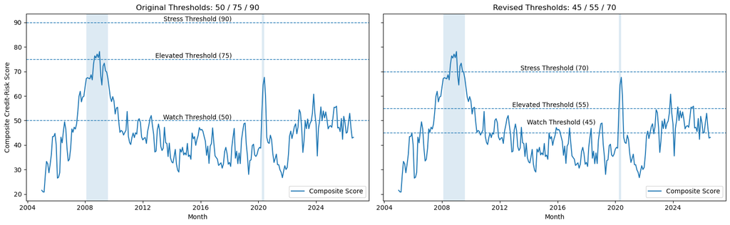

```python
threshold_comparison = pd.read_sql_query(
    """
    SELECT
        month_end,
        composite_credit_risk_score,
        composite_credit_risk_regime,
        composite_credit_risk_regime_revised,
        usrec
    FROM credit_risk_composite_scores_revised
    WHERE composite_score_coverage_pct = 100
    ORDER BY month_end;
    """,
    conn
)

threshold_comparison["month_end"] = pd.to_datetime(
    threshold_comparison["month_end"]
)

fig, axes = plt.subplots(1, 2, figsize=(16, 5), sharey=True)


# Original threshold chart
axes[0].plot(
    threshold_comparison["month_end"],
    threshold_comparison["composite_credit_risk_score"],
    label="Composite Score"
)

for date in threshold_comparison.loc[threshold_comparison["usrec"] == 1, "month_end"]:
    axes[0].axvspan(
        date,
        date + pd.offsets.MonthEnd(1),
        alpha=0.15
    )

axes[0].axhline(50, linestyle="--", linewidth=1)
axes[0].axhline(75, linestyle="--", linewidth=1)
axes[0].axhline(90, linestyle="--", linewidth=1)

# Threshold labels for LEFT plot
axes[0].text(
    0.60, 50, "Watch Threshold (50)",
    transform=axes[0].get_yaxis_transform(),
    va="bottom",
    ha="right"
)

axes[0].text(
    0.60, 75, "Elevated Threshold (75)",
    transform=axes[0].get_yaxis_transform(),
    va="bottom",
    ha="right"
)

axes[0].text(
    0.60, 90, "Stress Threshold (90)",
    transform=axes[0].get_yaxis_transform(),
    va="bottom",
    ha="right"
)

axes[0].set_title("Original Thresholds: 50 / 75 / 90")
axes[0].set_xlabel("Month")
axes[0].set_ylabel("Composite Credit-Risk Score")
axes[0].legend(loc="lower right")



# Revised threshold chart
axes[1].plot(
    threshold_comparison["month_end"],
    threshold_comparison["composite_credit_risk_score"],
    label="Composite Score"
)

for date in threshold_comparison.loc[threshold_comparison["usrec"] == 1, "month_end"]:
    axes[1].axvspan(
        date,
        date + pd.offsets.MonthEnd(1),
        alpha=0.15
    )

axes[1].axhline(45, linestyle="--", linewidth=1)
axes[1].axhline(55, linestyle="--", linewidth=1)
axes[1].axhline(70, linestyle="--", linewidth=1)

# Threshold labels for RIGHT plot
axes[1].text(
    0.62, 48, "Watch Threshold (45)",
    transform=axes[1].get_yaxis_transform(),
    va="bottom",
    ha="right"
)

axes[1].text(
    0.60, 55, "Elevated Threshold (55)",
    transform=axes[1].get_yaxis_transform(),
    va="bottom",
    ha="right"
)

axes[1].text(
    0.60, 70, "Stress Threshold (70)",
    transform=axes[1].get_yaxis_transform(),
    va="bottom",
    ha="right"
)

axes[1].set_title("Revised Thresholds: 45 / 55 / 70")
axes[1].set_xlabel("Month")
axes[1].legend(loc="lower right")

plt.tight_layout()
plt.show()
```

- **Normal:** Broad credit-risk conditions are within the lower historical range of the composite score. Individual categories may still show pressure, but the overall system-level score is not elevated.
- **Watch:** Conditions are above normal and deserve monitoring. A Watch regime does not imply crisis; it means the composite score has moved into a range where one or more categories are showing meaningful deterioration.
- **Elevated:** Conditions are materially stressed and closer to recession-like behavior. Elevated months indicate that risk is broadening across categories or that one or more categories have become severe enough to raise the composite score.
- **Stress:** Conditions resemble the most severe historical macro-credit stress periods in the available sample. Stress is reserved for broad-based deterioration across multiple categories, not just a single market shock.

### Threshold Selection Rationale

The revised composite thresholds were selected after validating the original regime framework against recession and non-recession months. The original 50 / 75 / 90 thresholds were appropriate as an initial percentile-style framework, but they were too conservative for the equal-weighted composite score. Because the composite score averages four category scores, extreme values in one category are dampened by lower values in other categories.

The revised thresholds are:

- Below 45: Normal
- 45 to below 55: Watch
- 55 to below 70: Elevated
- 70 and above: Stress

The thresholds are not regulatory cutoffs and should not be interpreted as causal recession predictors. They are transparent monitoring thresholds designed to translate the composite score into usable dashboard regimes. Category-level scores remain available to explain whether the composite score is being driven by market stress, labor deterioration, rate/yield-curve pressure, or realized credit performance.

### Threshold Sensitivity and Tradeoff

The revised thresholds are intended to classify the composite score as a macro-credit monitoring signal, not as a pure market-stress alarm. Lowering the Stress threshold too aggressively would make the dashboard more sensitive to sudden market shocks, but it would also increase the risk of false stress classifications during non-recession or temporary volatility periods.

The selected 45 / 55 / 70 framework balances sensitivity and conservatism. A Watch threshold of 45 is slightly above the average non-recession composite score, so it identifies above-normal pressure without labeling ordinary conditions as risky. An Elevated threshold of 55 is near the lower bound of observed recession-month composite scores, so it captures recession-like deterioration. A Stress threshold of 70 is near the average recession-month composite score and above the observed non-recession maximum, so it reserves the highest-risk label for broad-based macro-credit stress rather than isolated market volatility.

A lower Stress threshold, such as 60 or 65, would capture more abrupt shock periods, including parts of the COVID episode. However, that would shift the model closer to a market-stress detector. Realized credit performance did not deteriorate during the COVID period in the same way as it did during 2008. Policy intervention, payment forbearance, stimulus, and the short recession length muted the realized credit-loss channel. Therefore, if COVID does not reach the composite Stress regime, that is not necessarily a model failure. It means the model is distinguishing between a market shock / labor shock and a full macro-credit deterioration cycle.

The 70 threshold is retained because the dashboard is designed to identify broad macro-credit deterioration across market stress, labor risk, rate pressure, and realized credit performance.

### Revised Regime vs. Recession Validation Interpretation

The revised regime framework produces economically sensible separation across recession and non-recession months. Normal months contain no recession observations, and Watch months contain only a very small recession share. Elevated months contain a much higher recession share, indicating that the revised Elevated regime captures meaningful macro-credit deterioration.

The Stress regime contains only recession months in this historical sample. This supports the decision to use 70 as the revised Stress threshold because it reserves the highest-risk label for severe broad-based macro-credit stress rather than temporary or isolated market volatility.

This validation does not prove forecasting power because the recession indicator is used as a historical classification label, not as a future outcome. However, it confirms that the revised regime labels align more closely with known recession periods than the original thresholds. The result supports using the revised regime framework for dashboard interpretation.

The next validation step is to test whether revised regime labels provide useful forward-looking market context by comparing future S&P 500 returns across Normal, Watch, Elevated, and Stress regimes.

```python
revised_recession_regime_check = pd.read_sql_query(
    """
    SELECT
        composite_credit_risk_regime_revised AS revised_regime,
        COUNT(*) AS month_count,

        SUM(
            CASE
                WHEN usrec = 1 THEN 1
                ELSE 0
            END
        ) AS recession_months,

        ROUND(
            100.0 * SUM(
                CASE
                    WHEN usrec = 1 THEN 1
                    ELSE 0
                END
            ) / COUNT(*),
            2
        ) AS recession_share_pct,

        AVG(composite_credit_risk_score) AS avg_score,
        MIN(composite_credit_risk_score) AS min_score,
        MAX(composite_credit_risk_score) AS max_score

    FROM credit_risk_composite_scores_revised
    WHERE composite_score_coverage_pct = 100
    GROUP BY composite_credit_risk_regime_revised
    ORDER BY
        CASE composite_credit_risk_regime_revised
            WHEN 'Normal' THEN 1
            WHEN 'Watch' THEN 2
            WHEN 'Elevated' THEN 3
            WHEN 'Stress' THEN 4
            ELSE 5
        END;
    """,
    conn
)

revised_recession_regime_check
```

|  | revised_regime | month_count | recession_months | recession_share_pct | avg_score | min_score | max_score |
| --- | --- | --- | --- | --- | --- | --- | --- |
| 0 | Normal | 142 | 0 | 0.00 | 37.042717 | 20.833333 | 44.991948 |
| 1 | Watch | 78 | 1 | 1.28 | 48.576221 | 45.013862 | 54.411617 |
| 2 | Elevated | 31 | 10 | 32.26 | 61.927560 | 55.013173 | 69.750672 |
| 3 | Stress | 9 | 9 | 100.00 | 74.591934 | 70.296494 | 78.118386 |

### 7.7.2 Forward S&P 500 Return Validation

The recession validation tested whether the revised composite regimes aligned with known macroeconomic stress periods. This next check evaluates the market-context overlay by comparing future S&P 500 returns across the revised risk regimes.

The question is:

> When the dashboard classified conditions as Normal, Watch, or Elevated, did future S&P 500 returns show different return patterns?

This is not a trading rule and does not prove causality. The purpose is to test whether the macro-credit regime contains useful forward-looking market context. If forward S&P 500 returns differ across risk regimes, then the dashboard may have practical value for risk-on / risk-off interpretation, portfolio monitoring, and market-context discussion.

The S&P 500 overlay begins later than the full credit-risk dataset because the FRED S&P 500 series used in this project starts in 2016. Therefore, this validation only uses months where forward S&P 500 return data are available. Some regimes, especially Stress, may have limited or no observations in the S&P 500 overlay window.

> This table compares future S&P 500 returns across the revised composite risk regimes. The goal is to determine whether higher dashboard risk regimes were historically associated with different forward equity-market outcomes in the available S&P 500 market-context window.

> The result should be interpreted carefully because the S&P 500 overlay begins in 2016, while the full credit-risk score begins earlier. As a result, the forward-return validation has fewer observations than the recession validation and may not include all historical stress periods.

> The key evaluation question is whether average forward returns, positive-return shares, and downside outcomes differ as the regime moves from Normal to Watch to Elevated.

```python
forward_sp500_regime_validation = pd.read_sql_query(
    """
    SELECT
        composite_credit_risk_regime_revised AS revised_regime,

        COUNT(*) AS month_count,

        ROUND(100.0 * AVG(sp500_forward_1m_return), 2) AS avg_forward_1m_return_pct,
        ROUND(100.0 * AVG(sp500_forward_3m_return), 2) AS avg_forward_3m_return_pct,
        ROUND(100.0 * AVG(sp500_forward_6m_return), 2) AS avg_forward_6m_return_pct,

        ROUND(100.0 * AVG(
            CASE
                WHEN sp500_forward_1m_return > 0 THEN 1.0
                ELSE 0.0
            END
        ), 2) AS positive_1m_return_share_pct,

        ROUND(100.0 * AVG(
            CASE
                WHEN sp500_forward_3m_return > 0 THEN 1.0
                ELSE 0.0
            END
        ), 2) AS positive_3m_return_share_pct,

        ROUND(100.0 * AVG(
            CASE
                WHEN sp500_forward_6m_return > 0 THEN 1.0
                ELSE 0.0
            END
        ), 2) AS positive_6m_return_share_pct,

        ROUND(100.0 * MIN(sp500_forward_3m_return), 2) AS min_forward_3m_return_pct,
        ROUND(100.0 * MAX(sp500_forward_3m_return), 2) AS max_forward_3m_return_pct

    FROM credit_risk_composite_scores_revised
    WHERE composite_score_coverage_pct = 100
      AND sp500_forward_1m_return IS NOT NULL
      AND sp500_forward_3m_return IS NOT NULL
      AND sp500_forward_6m_return IS NOT NULL

    GROUP BY composite_credit_risk_regime_revised

    ORDER BY
        CASE composite_credit_risk_regime_revised
            WHEN 'Normal' THEN 1
            WHEN 'Watch' THEN 2
            WHEN 'Elevated' THEN 3
            WHEN 'Stress' THEN 4
            ELSE 5
        END;
    """,
    conn
)

forward_sp500_regime_validation
```

|  | revised_regime | month_count | avg_forward_1m_return_pct | avg_forward_3m_return_pct | avg_forward_6m_return_pct | positive_1m_return_share_pct | positive_3m_return_share_pct | positive_6m_return_share_pct | min_forward_3m_return_pct | max_forward_3m_return_pct |
| --- | --- | --- | --- | --- | --- | --- | --- | --- | --- | --- |
| 0 | Normal | 65 | 0.68 | 2.32 | 5.20 | 67.69 | 72.31 | 75.38 | -20.00 | 13.59 |
| 1 | Watch | 41 | 1.13 | 3.23 | 7.23 | 65.85 | 70.73 | 80.49 | -16.45 | 19.95 |
| 2 | Elevated | 8 | 4.49 | 11.83 | 17.95 | 87.50 | 100.00 | 100.00 | 8.47 | 15.54 |

### Forward S&P 500 Return Validation Interpretation

This validation evaluates whether the revised macro-credit risk regimes provide useful forward-looking context for S&P 500 returns. This section is not part of the core credit-risk score. It is a market-context validation layer that tests whether the dashboardâ€™s macro-credit regimes are associated with different future equity-return profiles.

The analysis is a state-conditioned return check. For every month classified as Normal, Watch, or Elevated, the table calculates the following forward S&P 500 outcomes:

- average next 1-month return
- average next 3-month return
- average next 6-month return
- share of observations with positive forward returns
- minimum and maximum observed 3-month forward returns

This answers the question:

> When the dashboard classified the current month as a specific macro-credit regime, what happened to S&P 500 returns afterward?

The results show that the relationship between macro-credit stress and forward equity returns is not one-directional in the available S&P 500 market-context window. Elevated months had stronger average forward returns than Normal or Watch months, and Elevated months also had higher positive-return shares across the 1-month, 3-month, and 6-month forward windows.

This result suggests that elevated macro-credit stress can coincide with rebound conditions rather than only downside conditions. One possible explanation is timing. By the time the dashboard reaches an Elevated regime, markets may have already repriced bad news. Equity markets may then begin responding to stabilization, liquidity support, policy response, improved risk appetite, or expectations that conditions will stop deteriorating.

This does not mean that elevated credit risk is bullish by itself. It means that the composite score measures macro-credit stress, not the full set of variables that determine equity returns. The current composite includes market stress, labor risk, rate/yield-curve pressure, and realized credit performance. It does not include all drivers of equity returns, such as inflation, Federal Reserve policy, bank lending standards, corporate earnings expectations, equity valuation, liquidity conditions, or investor positioning.

Because of that, the correct interpretation is narrower: the dashboard provides macro-credit regime context, and the S&P 500 overlay tests whether those regimes are associated with different forward equity outcomes. The result shows that the score is useful for framing market conditions, but the state-conditioned regime level alone should not be treated as a mechanical equity-return forecast.

The next check evaluates regime transitions directly. That matters because the current table groups together all months inside a regime, including months where the regime just changed, months where the regime persisted, and months where stress may already have started to fade. A transition-based check can test whether moves such as Normal to Watch or Watch to Elevated carry different information than the regime level alone.

### Monetary Policy and Macro Variable Limitation

This first-version composite score includes rate pressure through the 30-year Treasury yield, the 30-year Treasury 3-month change, and yield-curve inversion risk. However, it does not directly include the Federal Funds rate, CPI inflation, core CPI inflation, real interest rates, bank loan demand, bank lending standards, corporate earnings expectations, equity valuation, or investor positioning.

These omitted variables matter for a broader macro-credit monitoring framework. For example, CPI inflation and Federal Reserve policy affect discount rates, borrowing costs, credit conditions, and market liquidity. Bank lending standards and loan demand provide direct information about credit availability. The Federal Reserveâ€™s Senior Loan Officer Opinion Survey is a potential source for lending-standard and loan-demand indicators.

These variables are not added to the first version because the project is designed as a transparent macro-credit monitoring dashboard. Version 1 prioritizes reproducibility, interpretability, and a clear scoring framework before adding additional macro-policy and lending-channel complexity.

Future versions could add Federal Funds rate, CPI inflation, core CPI inflation, real interest rates, SLOOS lending standards, SLOOS loan demand, and credit-to-GDP measures to improve policy, inflation, and lending-channel coverage.

### 7.7.2b Regime Transition Return Check

The prior validation measured forward returns based on the current regime level. This transition check asks a different question: did forward S&P 500 returns differ after the dashboard changed from one regime to another?

Examples include:

- Normal â†’ Watch
- Watch â†’ Elevated
- Elevated â†’ Watch
- Watch â†’ Normal

This is closer to an event-study style check. Instead of asking what happened after all Elevated months, it asks what happened after the dashboard first moved into a different state. This can help identify whether regime changes contain incremental information beyond the regime level alone.

This distinction matters because the state-conditioned table mixes several situations together:

- months where a regime just changed
- months where the same regime persisted
- months where stress was already fading
- months where markets may have already started recovering

The transition table separates those cases more directly. However, transition counts may be small, so the results should be interpreted as exploratory evidence rather than a standalone trading rule.

```python
transition_event_data = pd.read_sql_query(
    """
    WITH regime_history AS (
        SELECT
            month_end,

            composite_credit_risk_score AS current_score,

            LAG(composite_credit_risk_score)
                OVER (ORDER BY month_end) AS prior_score,

            composite_credit_risk_regime_revised AS current_regime,

            LAG(composite_credit_risk_regime_revised)
                OVER (ORDER BY month_end) AS prior_regime,

            usrec,

            sp500_forward_1m_return,
            sp500_forward_3m_return,
            sp500_forward_6m_return

        FROM credit_risk_composite_scores_revised
        WHERE composite_score_coverage_pct = 100
          AND sp500_forward_1m_return IS NOT NULL
          AND sp500_forward_3m_return IS NOT NULL
          AND sp500_forward_6m_return IS NOT NULL
    )

    SELECT
        month_end,
        prior_regime || ' -> ' || current_regime AS regime_transition,
        prior_regime,
        current_regime,
        prior_score,
        current_score,
        current_score - prior_score AS score_change,
        usrec,
        sp500_forward_1m_return,
        sp500_forward_3m_return,
        sp500_forward_6m_return

    FROM regime_history
    WHERE prior_regime IS NOT NULL
      AND prior_regime <> current_regime

    ORDER BY month_end;
    """,
    conn
)

transition_event_data["month_end"] = pd.to_datetime(
    transition_event_data["month_end"]
)

transition_summary_rows = []

for transition, subset in transition_event_data.groupby("regime_transition"):
    transition_count = len(subset)

    if transition_count >= 30:
        sample_strength = "Stronger sample"
    elif transition_count >= 10:
        sample_strength = "Limited sample"
    elif transition_count >= 5:
        sample_strength = "Very limited sample"
    else:
        sample_strength = "Anecdotal sample"

    transition_summary_rows.append({
        "regime_transition": transition,
        "transition_count": transition_count,
        "sample_strength": sample_strength,

        "avg_score_change": subset["score_change"].mean(),
        "recession_share_pct": subset["usrec"].mean() * 100,

        "avg_forward_1m_return_pct": subset["sp500_forward_1m_return"].mean() * 100,
        "avg_forward_3m_return_pct": subset["sp500_forward_3m_return"].mean() * 100,
        "avg_forward_6m_return_pct": subset["sp500_forward_6m_return"].mean() * 100,

        "median_forward_3m_return_pct": subset["sp500_forward_3m_return"].median() * 100,

        "negative_1m_return_share_pct": (subset["sp500_forward_1m_return"] < 0).mean() * 100,
        "negative_3m_return_share_pct": (subset["sp500_forward_3m_return"] < 0).mean() * 100,
        "negative_6m_return_share_pct": (subset["sp500_forward_6m_return"] < 0).mean() * 100,

        "worst_forward_3m_return_pct": subset["sp500_forward_3m_return"].min() * 100
    })

regime_transition_return_check_final = pd.DataFrame(
    transition_summary_rows
)

regime_transition_return_check_final = (
    regime_transition_return_check_final
    .sort_values("transition_count", ascending=False)
    .round(2)
    .reset_index(drop=True)
)

regime_transition_return_check_final
```

|  | regime_transition | transition_count | sample_strength | avg_score_change | recession_share_pct | avg_forward_1m_return_pct | avg_forward_3m_return_pct | avg_forward_6m_return_pct | median_forward_3m_return_pct | negative_1m_return_share_pct | negative_3m_return_share_pct | negative_6m_return_share_pct | worst_forward_3m_return_pct |
| --- | --- | --- | --- | --- | --- | --- | --- | --- | --- | --- | --- | --- | --- |
| 0 | Normal -> Watch | 10 | Limited sample | 6.46 | 10.0 | 0.44 | 3.30 | 6.27 | 4.95 | 40.00 | 20.00 | 30.00 | -16.45 |
| 1 | Watch -> Normal | 9 | Very limited sample | -7.71 | 0.0 | -0.38 | 3.14 | 5.64 | 3.16 | 33.33 | 22.22 | 11.11 | -1.16 |
| 2 | Watch -> Elevated | 4 | Anecdotal sample | 7.09 | 25.0 | 4.37 | 12.02 | 16.21 | 11.44 | 25.00 | 0.00 | 0.00 | 9.66 |
| 3 | Elevated -> Watch | 3 | Anecdotal sample | -7.41 | 0.0 | 3.35 | 8.80 | 13.39 | 7.79 | 0.00 | 0.00 | 0.00 | 7.03 |
| 4 | Elevated -> Normal | 1 | Anecdotal sample | -16.95 | 0.0 | 7.01 | -0.04 | 13.55 | -0.04 | 0.00 | 100.00 | 0.00 | -0.04 |

This transition check should be interpreted as exploratory market-context evidence rather than a formal predictive model. The S&P 500 columns summarize what happened after each regime transition, but the transition counts are small for several categories. Because of this, the table is useful for identifying possible monitoring signals, but it should not be treated as a statistically conclusive relationship between regime changes and future equity returns.

### Regime Transition Metric Definitions

This table evaluates what happened after the dashboard moved from one revised macro-credit regime to another. It does not calculate a correlation coefficient. Instead, it is a transition-conditioned forward return analysis: for each month where the regime changed, the table summarizes the Composite Credit Risk Score movement and the subsequent S&P 500 forward returns.

The `transition_count` column shows how many times each regime transition occurred in the available S&P 500 forward-return window. For example, a Normal â†’ Watch transition means the prior month was classified as Normal and the current month moved into Watch.

The `avg_score_change` column measures the average change in the Composite Credit Risk Score during the transition month. This is measured in score points on the 0-to-100 composite-risk scale. For example, an average score change of 6.48 means the composite score increased by about 6.48 points when that transition occurred.

The `recession_share_pct` column shows the percentage of transition months that occurred during an NBER recession month.

The `avg_forward_1m_return_pct`, `avg_forward_3m_return_pct`, and `avg_forward_6m_return_pct` columns measure the average S&P 500 return after the transition month over the next 1, 3, and 6 months. These are forward market outcomes, not changes in the credit-risk score.

The negative-return share columns measure downside frequency, not downside severity. For example, a negative 1-month return share of 40% means that 40% of the transition observations had a negative 1-month forward S&P 500 return. It does not show how large those negative returns were.

For the 3-month and 6-month negative-return share columns, the calculation checks whether the full cumulative forward return over that horizon was negative. It does not count whether any single month inside the forward window was negative.

The `median_forward_3m_return_pct` column reports the middle 3-month forward S&P 500 return after each transition. The 3-month median is included as a practical medium-term monitoring measure because it is less noisy than the 1-month return and less extended than the 6-month return.

The `worst_forward_3m_return_pct` column reports the worst observed cumulative 3-month S&P 500 return after each transition. This gives one downside-severity measure at the transition level. Negative-return share shows how often downside occurred, while worst forward return shows the largest observed downside event in that horizon.

This transition table should be interpreted as exploratory market-context evidence. It is useful for identifying possible monitoring signals, but several transition groups have small sample sizes, so the results should not be treated as statistically conclusive.

### Regime Transition Return Check Interpretation

This transition check evaluates whether changes in the revised macro-credit regime contain additional information beyond the regime level alone. Instead of grouping every month by its current regime, this table focuses only on months where the dashboard changed from one regime to another.

The table is intentionally focused on practical risk-monitoring metrics: transition count, average composite score change, recession share, average forward S&P 500 returns, negative-return shares, and worst observed 3-month forward return. Standard deviation is excluded from the final display because several transition groups contain very few observations, making dispersion statistics less stable and harder to interpret.

The **Watch â†’ Elevated** transition occurred **4** times and had an average composite score increase of **7.10** points. It also had a **25.0%** recession-month share. Forward S&P 500 returns were strong in this small sample, averaging **4.37%** over 1 month, **12.02%** over 3 months, and **16.21%** over 6 months. The worst observed 3-month forward return was still positive at **9.66%**. This result should not be overinterpreted because the sample is small. It suggests that some transitions into Elevated may occur after market stress has already been priced in, with forward returns improving as conditions stabilize or policy/liquidity support becomes more visible.

The **Elevated â†’ Normal** transition has only one observation and should not be used for inference. It is included for transparency, but the sample size is too small to interpret as a recurring pattern.

Overall, the transition results support using the dashboard as a macro-credit monitoring tool with market-context validation. The transition analysis shows that **Normal â†’ Watch** is the clearest early-warning move because it had the worst observed 3-month downside and the highest short-window negative-return frequency. **Watch â†’ Elevated** and de-escalation transitions showed positive average forward returns in this sample, which suggests that the S&P 500 relationship is timing-dependent and not mechanically bearish.

The correct conclusion is not that regime transitions reliably predict S&P 500 returns. The correct conclusion is that regime transitions provide market-context information. They can help frame whether conditions are moving into a more fragile macro-credit state, but they should not be treated as standalone trading rules.

### 7.7.3 Forward Return Downside Validation

The previous checks evaluated average forward S&P 500 returns by regime level and by regime transition. This section focuses more directly on downside risk.

Average returns can hide important information. A regime may have a positive average return while still containing larger downside events, higher negative-return frequency, or wider risk exposure. For a macro-credit monitoring dashboard, the more relevant question is not only whether forward returns were positive or negative on average, but whether higher-risk regimes were associated with greater downside risk.

This validation compares forward S&P 500 downside behavior across revised composite regimes using:

- month count
- recession share
- average forward returns
- median forward returns
- negative-return shares
- worst observed forward returns

This section helps determine whether the composite regime provides useful risk-context information even when average forward returns are positive.

```python
forward_downside_data = pd.read_sql_query(
    """
    SELECT
        month_end,
        composite_credit_risk_regime_revised AS revised_regime,
        composite_credit_risk_score,
        usrec,
        sp500_forward_1m_return,
        sp500_forward_3m_return,
        sp500_forward_6m_return
    FROM credit_risk_composite_scores_revised
    WHERE composite_score_coverage_pct = 100
      AND sp500_forward_1m_return IS NOT NULL
      AND sp500_forward_3m_return IS NOT NULL
      AND sp500_forward_6m_return IS NOT NULL
    ORDER BY month_end;
    """,
    conn
)

forward_downside_data["month_end"] = pd.to_datetime(
    forward_downside_data["month_end"]
)

regime_order = ["Normal", "Watch", "Elevated", "Stress"]

downside_summary_rows = []

for regime in regime_order:
    subset = forward_downside_data[
        forward_downside_data["revised_regime"] == regime
    ]

    month_count = len(subset)

    if month_count == 0:
        continue

    if month_count >= 30:
        sample_strength = "Stronger sample"
    elif month_count >= 10:
        sample_strength = "Limited sample"
    elif month_count >= 5:
        sample_strength = "Very limited sample"
    else:
        sample_strength = "Anecdotal sample"

    downside_summary_rows.append({
        "revised_regime": regime,
        "month_count": month_count,
        "sample_strength": sample_strength,

        "avg_composite_score": subset["composite_credit_risk_score"].mean(),
        "recession_share_pct": subset["usrec"].mean() * 100,

        "avg_forward_1m_return_pct": subset["sp500_forward_1m_return"].mean() * 100,
        "avg_forward_3m_return_pct": subset["sp500_forward_3m_return"].mean() * 100,
        "avg_forward_6m_return_pct": subset["sp500_forward_6m_return"].mean() * 100,

        "median_forward_1m_return_pct": subset["sp500_forward_1m_return"].median() * 100,
        "median_forward_3m_return_pct": subset["sp500_forward_3m_return"].median() * 100,
        "median_forward_6m_return_pct": subset["sp500_forward_6m_return"].median() * 100,

        "negative_1m_return_share_pct": (subset["sp500_forward_1m_return"] < 0).mean() * 100,
        "negative_3m_return_share_pct": (subset["sp500_forward_3m_return"] < 0).mean() * 100,
        "negative_6m_return_share_pct": (subset["sp500_forward_6m_return"] < 0).mean() * 100,

        "worst_forward_1m_return_pct": subset["sp500_forward_1m_return"].min() * 100,
        "worst_forward_3m_return_pct": subset["sp500_forward_3m_return"].min() * 100,
        "worst_forward_6m_return_pct": subset["sp500_forward_6m_return"].min() * 100
    })

forward_return_downside_validation = pd.DataFrame(
    downside_summary_rows
)

forward_return_downside_validation = (
    forward_return_downside_validation
    .round(2)
    .reset_index(drop=True)
)

forward_return_downside_validation
```

|  | revised_regime | month_count | sample_strength | avg_composite_score | recession_share_pct | avg_forward_1m_return_pct | avg_forward_3m_return_pct | avg_forward_6m_return_pct | median_forward_1m_return_pct | median_forward_3m_return_pct | median_forward_6m_return_pct | negative_1m_return_share_pct | negative_3m_return_share_pct | negative_6m_return_share_pct | worst_forward_1m_return_pct | worst_forward_3m_return_pct | worst_forward_6m_return_pct |
| --- | --- | --- | --- | --- | --- | --- | --- | --- | --- | --- | --- | --- | --- | --- | --- | --- | --- |
| 0 | Normal | 65 | Stronger sample | 36.29 | 0.00 | 0.68 | 2.32 | 5.20 | 1.31 | 3.16 | 6.92 | 32.31 | 27.69 | 24.62 | -12.51 | -20.00 | -20.58 |
| 1 | Watch | 41 | Stronger sample | 49.13 | 2.44 | 1.13 | 3.23 | 7.23 | 2.02 | 5.28 | 7.71 | 34.15 | 29.27 | 19.51 | -9.18 | -16.45 | -20.85 |
| 2 | Elevated | 8 | Very limited sample | 59.39 | 12.50 | 4.49 | 11.83 | 17.95 | 4.88 | 11.44 | 19.07 | 12.50 | 0.00 | 0.00 | -0.76 | 8.47 | 12.28 |

### Forward Return Downside Validation Interpretation

This downside validation evaluates whether higher revised macro-credit regimes were associated with weaker or riskier forward S&P 500 outcomes. The goal is not only to compare average returns, but also to examine downside frequency and worst observed forward returns.

The results show clearer separation for macro stress than for equity downside. Recession share rises across the regimes: Normal has a 0.00% recession share, Watch has a 2.44% recession share, and Elevated has a 12.50% recession share. This supports the interpretation that higher composite regimes are associated with greater macro-credit stress.

The Watch regime provides the more useful caution signal. Watch months had a higher average composite score than Normal months, a higher recession share, and a slightly higher negative 1-month return share. This suggests that Watch may capture early deterioration or unstable conditions, even though average forward returns remained positive.

The Elevated result should be interpreted carefully because it contains only 8 observations, making it a very limited sample. The absence of negative 3-month or 6-month returns in Elevated does not prove that Elevated conditions are low risk. It indicates that, in the available overlay window, Elevated observations often occurred after market stress had already been reflected in prices and forward returns improved afterward.

Overall, this validation supports the dashboard as a macro-credit monitoring framework with useful market-context information. The composite regime is effective for identifying rising macro-credit stress, but the S&P 500 overlay does not support treating higher regimes as automatic equity downside signals. The equity interpretation is more nuanced: elevated macro-credit stress can coincide with market drawdowns, but it can also appear near rebound periods after conditions have already deteriorated.

### 7.7.4 Final Threshold Validation Conclusion

The threshold validation supports using the revised 45 / 55 / 70 composite regime framework for the first version of the dashboard.

The original 50 / 75 / 90 thresholds were useful as an initial percentile-style structure, but they were too conservative for an equal-weighted composite score. Because the composite averages four category scores, extreme values in one category can be dampened by lower values in other categories. As a result, the original framework produced no Stress months, even during major historical stress periods.

The revised thresholds create a more practical regime structure:

- **Normal:** below 45
- **Watch:** 45 to below 55
- **Elevated:** 55 to below 70
- **Stress:** 70 and above

The recession validation provides the strongest support for the revised thresholds. Normal months had a 0.00% recession share, Watch months had a low recession share, Elevated months had a materially higher recession share, and Stress months were concentrated in recession periods. This indicates that the revised regimes create economically sensible separation across known macroeconomic stress periods.

The S&P 500 overlay provides additional market-context validation, but the results are more nuanced. State-conditioned and transition-based return checks show that higher macro-credit regimes do not mechanically translate into weaker future S&P 500 returns. In several cases, Elevated regimes were followed by strong forward returns, likely because markets had already repriced stress or were beginning to respond to stabilization, policy support, liquidity improvement, or recovering risk appetite.

This distinction is important for interpreting the dashboard correctly. The composite score is not a standalone equity-market forecasting model. It is a macro-credit risk monitoring framework with a light S&P 500 overlay. The primary purpose is to evaluate whether macro-credit conditions are deteriorating, stabilizing, or improving. The equity overlay helps provide context for market behavior around those regimes, but it should not be treated as a mechanical buy/sell signal.

Overall, the revised threshold framework is retained because it improves regime classification, aligns better with recession-period stress, and supports clearer dashboard interpretation. The final Version 1 model should be positioned as a transparent macro-credit monitoring dashboard that summarizes market stress, labor risk, rate/yield-curve pressure, and realized credit performance into an interpretable composite regime score.

### 7.8 Section 6â€“7 Implementation Recap

Sections 6 and 7 converted the cleaned monthly macro-credit dataset into a structured credit-risk monitoring framework. The main objective was to transform raw economic and financial indicators into comparable risk signals, aggregate them into category scores, construct a composite credit-risk score, and validate whether the resulting regimes behaved sensibly during known stress periods.

The first question was: **how should different indicators be made comparable?**  
The project solved this by converting raw variables into directional risk features where higher values consistently represent higher risk. For example, higher VIX, financial stress, unemployment, credit spreads, delinquency rates, and charge-off rates already represent higher risk. The yield-curve feature was transformed so that inversion pressure also maps to higher risk.

The second question was: **how should the score avoid lookahead bias?**  
The project created expanding percentile features rather than relying only on full-sample retrospective percentiles. Retrospective percentiles are useful for historical visualization, but expanding percentiles are more appropriate for monitoring because each month is compared only against information available up to that point. A 60-month warm-up window was used before operational expanding-percentile scoring begins.

The third question was: **how should indicators be grouped?**  
The model groups indicators into four risk categories:

- Market / Financial Stress
- Macro / Labor Risk
- Rate / Yield-Curve Pressure
- Realized Credit Performance

These categories allow the dashboard to show both the overall composite score and the underlying drivers of that score. This is important because two months can have the same composite score but very different risk compositions.

The fourth question was: **how should the composite score be calculated?**  
The composite score is calculated as an equal-weighted average of the four category scores. This creates a transparent score from 0 to 100, where higher values indicate more severe macro-credit stress. The equal-weighted structure was chosen for interpretability and to avoid overfitting a small number of historical stress episodes.

The fifth question was: **what thresholds should define Normal, Watch, Elevated, and Stress regimes?**  
The original 50 / 75 / 90 threshold framework was useful as an initial percentile-style structure, but it was too conservative for an equal-weighted composite score. Because the composite averages four category scores, extreme values in one category can be dampened by lower values in other categories. The original framework produced no Stress months, even during major historical stress periods.

The revised thresholds were set to:

- Normal: below 45
- Watch: 45 to below 55
- Elevated: 55 to below 70
- Stress: 70 and above

The sixth question was: **did the revised regimes align with known recession periods?**  
The recession validation supported the revised framework. Normal months had a 0.00% recession share, Watch months had a 1.28% recession share, Elevated months had a 32.26% recession share, and Stress months had a 100.00% recession share in the scored sample. This indicates that the revised thresholds create stronger economic separation across known stress periods.

The seventh question was: **did the S&P 500 overlay show a simple relationship between higher credit-risk regimes and weaker forward equity returns?**  
The answer was no. In the available S&P 500 overlay window, Elevated months had stronger average forward returns than Normal or Watch months. This suggests that the composite score should not be interpreted as a direct equity-market sell signal. Instead, the equity overlay provides market-context evidence around macro-credit regimes.

Several implementation issues were also identified and addressed. Early missing values were expected because 3-month changes require lagged observations. Expanding percentile scores required a warm-up period before becoming operational. Forward S&P 500 returns were unavailable before the FRED S&P 500 series begins and unavailable at the end of the sample where future returns are not yet known. These missing values were not treated as data errors; they were documented as structural limitations of the feature and validation design.

Overall, Sections 6 and 7 establish the core framework of the project. The dashboard now has a reproducible pipeline that transforms public macro-credit indicators into category scores, combines them into a composite credit-risk score, assigns interpretable regimes, and validates those regimes against recession periods and S&P 500 forward-return behavior. The resulting model is best positioned as a macro-credit risk monitoring dashboard with a light S&P 500 overlay.

## 8. Credit Risk Score

Section 8 converts the revised scoring framework into the final dashboard-ready credit-risk score output. The goal is to summarize the latest composite score, latest regime, category-level drivers, recent score momentum, and a simple forward risk outlook.

The forward outlook in this section is not a stock-price forecast. It is a baseline credit-risk score projection based on recent composite-score momentum. The purpose is to determine whether macro-credit conditions are currently improving, stabilizing, or deteriorating over the next 1-month, 3-month, and 6-month monitoring windows.

### 8.1 Final Credit Risk Score Table

The final credit-risk score table combines the revised composite score, revised regime label, four category-level risk scores, recession indicator, score coverage, provisional flag, and recent score changes.

Each category score is measured on a 0 to 100 scale. A higher value means that category is showing higher historical risk pressure relative to its own expanding historical distribution. These category scores are not regression coefficients. They are percentile-based risk scores designed to make indicators with different units comparable.

The four category scores are:

- **Market / Financial Stress Score:** captures market volatility, financial stress, and credit-spread pressure.
- **Macro / Labor Risk Score:** captures labor-market deterioration, mainly through unemployment-related features.
- **Rate / Yield-Curve Pressure Score:** captures interest-rate pressure and yield-curve inversion risk.
- **Realized Credit Performance Score:** captures observed credit deterioration through delinquency and charge-off indicators.

The composite score is calculated as the equal-weighted average of the four category scores. Because each category contributes one-fourth of the final score, the composite score summarizes broad macro-credit stress while still allowing the dashboard to identify which category is driving the current reading.

The `composite_score_coverage_pct` field shows whether all category scores are available for that month. A value of 100 means the composite score is fully covered. The `provisional_composite_flag` identifies months where the score should be interpreted cautiously because of warm-up periods, missing feature history, or incomplete scoring inputs.

The 1-month, 3-month, and 6-month score changes are point-to-point changes in the composite score, not rolling averages. For example, the 3-month change equals the current composite score minus the composite score from three months earlier.

```python
dashboard_score_data = pd.read_sql_query(
    """
    SELECT
        month_end,

        composite_credit_risk_score,
        composite_credit_risk_regime_revised,

        market_financial_stress_score_expanding AS market_financial_stress_score,
        macro_labor_risk_score_expanding AS macro_labor_risk_score,
        rate_yield_curve_pressure_score_expanding AS rate_yield_curve_pressure_score,
        realized_credit_performance_score_expanding AS realized_credit_performance_score,

        composite_score_coverage_pct,
        provisional_composite_flag,
        usrec

    FROM credit_risk_composite_scores_revised
    WHERE composite_score_coverage_pct = 100
    ORDER BY month_end;
    """,
    conn
)

dashboard_score_data["month_end"] = pd.to_datetime(
    dashboard_score_data["month_end"]
)

dashboard_score_data["composite_score_change_1m"] = (
    dashboard_score_data["composite_credit_risk_score"].diff(1)
)

dashboard_score_data["composite_score_change_3m"] = (
    dashboard_score_data["composite_credit_risk_score"].diff(3)
)

dashboard_score_data["composite_score_change_6m"] = (
    dashboard_score_data["composite_credit_risk_score"].diff(6)
)

dashboard_score_data = dashboard_score_data.round(2)

dashboard_score_data.tail(12)
```

|  | month_end | composite_credit_risk_score | composite_credit_risk_regime_revised | market_financial_stress_score | macro_labor_risk_score | rate_yield_curve_pressure_score | realized_credit_performance_score | composite_score_coverage_pct | provisional_composite_flag | usrec | composite_score_change_1m | composite_score_change_3m | composite_score_change_6m |
| --- | --- | --- | --- | --- | --- | --- | --- | --- | --- | --- | --- | --- | --- |
| 248 | 2025-08-31 | 45.48 | Watch | 27.54 | 44.04 | 62.82 | 47.52 | 100.0 | 0 | 0.0 | -1.74 | -10.37 | -5.35 |
| 249 | 2025-09-30 | 50.82 | Watch | 36.87 | 60.23 | 58.64 | 47.53 | 100.0 | 0 | 0.0 | 5.34 | 3.86 | -4.60 |
| 250 | 2025-10-31 | 42.34 | Normal | 47.32 | 31.29 | 53.19 | 37.55 | 100.0 | 1 | 0.0 | -8.48 | -4.89 | -12.96 |
| 251 | 2025-11-30 | 51.70 | Watch | 54.28 | 58.98 | 55.95 | 37.59 | 100.0 | 0 | 0.0 | 9.36 | 6.22 | -4.15 |
| 252 | 2025-12-31 | 49.12 | Watch | 48.01 | 46.45 | 64.41 | 37.63 | 100.0 | 0 | 0.0 | -2.58 | -1.69 | 2.17 |
| 253 | 2026-01-31 | 44.85 | Normal | 36.57 | 31.79 | 69.14 | 41.91 | 100.0 | 1 | 0.0 | -4.27 | 2.52 | -2.37 |
| 254 | 2026-02-28 | 45.23 | Watch | 34.70 | 38.82 | 65.48 | 41.93 | 100.0 | 0 | 0.0 | 0.38 | -6.47 | -0.25 |
| 255 | 2026-03-31 | 49.48 | Watch | 55.65 | 33.79 | 66.54 | 41.96 | 100.0 | 0 | 0.0 | 4.25 | 0.36 | -1.33 |
| 256 | 2026-04-30 | 52.92 | Watch | 54.77 | 44.85 | 67.81 | 44.26 | 100.0 | 0 | 0.0 | 3.44 | 8.07 | 10.59 |
| 257 | 2026-05-31 | 47.09 | Watch | 36.19 | 33.10 | 74.80 | 44.28 | 100.0 | 0 | 0.0 | -5.83 | 1.86 | -4.61 |
| 258 | 2026-06-30 | 42.84 | Normal | 17.56 | 37.39 | 72.12 | 44.29 | 100.0 | 0 | 0.0 | -4.25 | -6.64 | -6.28 |
| 259 | 2026-07-31 | 43.14 | Normal | 27.54 | 25.75 | 74.94 | 44.31 | 100.0 | 0 | 0.0 | 0.30 | -9.79 | -1.72 |

The `provisional_composite_flag` identifies months where the Composite Credit Risk Score should be interpreted cautiously. A provisional score may occur during early calibration periods or when one or more expected category inputs are unavailable. The score is still calculated using the available category information, but the flag separates fully covered operational scores from scores that depend on partial information.

### 8.2 Current Credit Risk Snapshot and Category Drivers

This section summarizes the latest dashboard reading and identifies which components are driving the current credit-risk score. It combines the current composite score, current regime, recent score changes, and category-level drivers into one dashboard-ready snapshot.

This section answers two current-state monitoring questions:

> Are macro-credit conditions currently improving, stabilizing, or deteriorating?

> Which part of the credit-risk environment is contributing most to the current score?

The composite score is the equal-weighted average of the four category scores. Each category score is measured on a 0 to 100 scale, where higher values indicate greater historical risk pressure in that category.

The score-change columns are point-to-point changes, not rolling averages:

- **1-month change:** current score minus the score from one month earlier
- **3-month change:** current score minus the score from three months earlier
- **6-month change:** current score minus the score from six months earlier

A positive change means risk pressure increased over that lookback window. A negative change means risk pressure declined. A stable reading means the score changed by less than one point.

This structure allows the dashboard to separate the overall risk level from the underlying drivers. For example, the composite score may be Normal, while one individual category may still be elevated. That distinction is important because it shows whether risk is broad-based across the system or concentrated in one part of the macro-credit environment.

```python
latest_row = dashboard_score_data.iloc[-1]

score_component_columns = {
    "Composite Credit Risk Score": "composite_credit_risk_score",
    "Market / Financial Stress": "market_financial_stress_score",
    "Macro / Labor Risk": "macro_labor_risk_score",
    "Rate / Yield-Curve Pressure": "rate_yield_curve_pressure_score",
    "Realized Credit Performance": "realized_credit_performance_score"
}

snapshot_rows = []

for component_name, column_name in score_component_columns.items():
    latest_score = dashboard_score_data[column_name].iloc[-1]
    prior_1m_score = dashboard_score_data[column_name].iloc[-2]
    prior_3m_score = dashboard_score_data[column_name].iloc[-4]
    prior_6m_score = dashboard_score_data[column_name].iloc[-7]

    change_1m = latest_score - prior_1m_score
    change_3m = latest_score - prior_3m_score
    change_6m = latest_score - prior_6m_score

    if change_1m > 1:
        one_month_direction = "Deteriorating"
    elif change_1m < -1:
        one_month_direction = "Improving"
    else:
        one_month_direction = "Stable"

    snapshot_rows.append({
        "score_component": component_name,
        "latest_score": latest_score,
        "prior_month_score": prior_1m_score,
        "change_1m": change_1m,
        "change_3m": change_3m,
        "change_6m": change_6m,
        "one_month_direction": one_month_direction
    })

current_credit_risk_snapshot = pd.DataFrame(snapshot_rows)

current_credit_risk_snapshot.insert(
    0,
    "latest_month",
    latest_row["month_end"].strftime("%Y-%m-%d")
)

current_credit_risk_snapshot.insert(
    2,
    "current_composite_regime",
    latest_row["composite_credit_risk_regime_revised"]
)

current_credit_risk_snapshot = (
    current_credit_risk_snapshot
    .round(2)
)

current_credit_risk_snapshot
```

|  | latest_month | score_component | current_composite_regime | latest_score | prior_month_score | change_1m | change_3m | change_6m | one_month_direction |
| --- | --- | --- | --- | --- | --- | --- | --- | --- | --- |
| 0 | 2026-07-31 | Composite Credit Risk Score | Normal | 43.14 | 42.84 | 0.30 | -9.78 | -1.71 | Stable |
| 1 | 2026-07-31 | Market / Financial Stress | Normal | 27.54 | 17.56 | 9.98 | -27.23 | -9.03 | Deteriorating |
| 2 | 2026-07-31 | Macro / Labor Risk | Normal | 25.75 | 37.39 | -11.64 | -19.10 | -6.04 | Improving |
| 3 | 2026-07-31 | Rate / Yield-Curve Pressure | Normal | 74.94 | 72.12 | 2.82 | 7.13 | 5.80 | Deteriorating |
| 4 | 2026-07-31 | Realized Credit Performance | Normal | 44.31 | 44.29 | 0.02 | 0.05 | 2.40 | Stable |

### 8.3 Forward Credit Risk Outlook

This section creates a forward credit-risk outlook for the composite score and each category score. The purpose is to estimate whether macro-credit pressure is likely to improve, stabilize, or deteriorate over the next 1-month, 3-month, and 6-month monitoring windows.

The forecast is applied to the dashboardâ€™s own risk scores, not to S&P 500 prices. The goal is to project the composite score and the four category scores forward so the dashboard can provide a short-term macro-credit risk outlook.

The forecast should be interpreted as a monitoring outlook, not a guaranteed prediction. The purpose is to show whether the current score path points toward improving, stable, or deteriorating conditions and whether projected scores remain comfortably within the current regime or approach a higher-risk threshold.

```python
import statsmodels.api as sm

def assign_composite_regime(score):
    if pd.isna(score):
        return "Insufficient Data"
    elif score < 45:
        return "Normal"
    elif score < 55:
        return "Watch"
    elif score < 70:
        return "Elevated"
    else:
        return "Stress"


def assign_category_band(score):
    if pd.isna(score):
        return "Insufficient Data"
    elif score < 50:
        return "Normal"
    elif score < 75:
        return "Watch"
    elif score < 90:
        return "Elevated"
    else:
        return "Stress"


score_columns = {
    "Composite Credit Risk Score": "composite_credit_risk_score",
    "Market / Financial Stress": "market_financial_stress_score",
    "Macro / Labor Risk": "macro_labor_risk_score",
    "Rate / Yield-Curve Pressure": "rate_yield_curve_pressure_score",
    "Realized Credit Performance": "realized_credit_performance_score"
}

forecast_horizons = {
    "Current": 0,
    "Projected 1-month": 1,
    "Projected 3-month": 3,
    "Projected 6-month": 6
}

forward_outlook_rows = []
forecast_model_diagnostics = []

for component_name, score_col in score_columns.items():
    model_data = dashboard_score_data[
        ["month_end", score_col]
    ].dropna().copy()

    model_data["lag_score"] = model_data[score_col].shift(1)
    model_data = model_data.dropna()

    y = model_data[score_col]
    X = sm.add_constant(model_data["lag_score"])

    ar1_model = sm.OLS(y, X).fit()

    intercept = ar1_model.params["const"]
    beta = ar1_model.params["lag_score"]
    residual_std = ar1_model.resid.std()

    latest_score = dashboard_score_data[score_col].iloc[-1]

    recursive_forecasts = {
        "Current": latest_score
    }

    forecast_score = latest_score

    for step in range(1, 7):
        forecast_score = intercept + beta * forecast_score
        forecast_score = min(max(forecast_score, 0), 100)

        if step == 1:
            recursive_forecasts["Projected 1-month"] = forecast_score
        elif step == 3:
            recursive_forecasts["Projected 3-month"] = forecast_score
        elif step == 6:
            recursive_forecasts["Projected 6-month"] = forecast_score

    for outlook_window, projected_score in recursive_forecasts.items():
        if component_name == "Composite Credit Risk Score":
            projected_classification = assign_composite_regime(projected_score)
        else:
            projected_classification = assign_category_band(projected_score)

        forward_outlook_rows.append({
            "score_component": component_name,
            "outlook_window": outlook_window,
            "projected_score": projected_score,
            "projected_classification": projected_classification
        })

    forecast_model_diagnostics.append({
        "score_component": component_name,
        "ar1_intercept": intercept,
        "ar1_beta": beta,
        "residual_std": residual_std,
        "r_squared": ar1_model.rsquared
    })

forward_credit_risk_outlook = pd.DataFrame(forward_outlook_rows)

forward_credit_risk_outlook = (
    forward_credit_risk_outlook
    .round(2)
)

forecast_model_diagnostics = pd.DataFrame(
    forecast_model_diagnostics
).round(4)

forward_credit_risk_outlook
```

|  | score_component | outlook_window | projected_score | projected_classification |
| --- | --- | --- | --- | --- |
| 0 | Composite Credit Risk Score | Current | 43.14 | Normal |
| 1 | Composite Credit Risk Score | Projected 1-month | 43.38 | Normal |
| 2 | Composite Credit Risk Score | Projected 3-month | 43.80 | Normal |
| 3 | Composite Credit Risk Score | Projected 6-month | 44.28 | Normal |
| 4 | Market / Financial Stress | Current | 27.54 | Normal |
| 5 | Market / Financial Stress | Projected 1-month | 31.63 | Normal |
| 6 | Market / Financial Stress | Projected 3-month | 37.30 | Normal |
| 7 | Market / Financial Stress | Projected 6-month | 41.92 | Normal |
| 8 | Macro / Labor Risk | Current | 25.75 | Normal |
| 9 | Macro / Labor Risk | Projected 1-month | 28.56 | Normal |
| 10 | Macro / Labor Risk | Projected 3-month | 32.87 | Normal |
| 11 | Macro / Labor Risk | Projected 6-month | 37.03 | Normal |
| 12 | Rate / Yield-Curve Pressure | Current | 74.94 | Watch |
| 13 | Rate / Yield-Curve Pressure | Projected 1-month | 72.53 | Watch |
| 14 | Rate / Yield-Curve Pressure | Projected 3-month | 68.33 | Watch |
| 15 | Rate / Yield-Curve Pressure | Projected 6-month | 63.29 | Watch |
| 16 | Realized Credit Performance | Current | 44.31 | Normal |
| 17 | Realized Credit Performance | Projected 1-month | 44.48 | Normal |
| 18 | Realized Credit Performance | Projected 3-month | 44.81 | Normal |
| 19 | Realized Credit Performance | Projected 6-month | 45.26 | Normal |

### 8.3.1 Forward Credit Risk Outlook with ARIMA Model Selection

This section creates a forward credit-risk outlook for the composite score and each category score. The purpose is to estimate whether macro-credit pressure is likely to improve, stabilize, or deteriorate over the next 1-month, 3-month, and 6-month monitoring windows.

This forecast is applied to the dashboardâ€™s own risk scores, not to S&P 500 prices. The model forecasts the composite credit-risk score and the four category scores directly:

- Composite Credit Risk Score
- Market / Financial Stress
- Macro / Labor Risk
- Rate / Yield-Curve Pressure
- Realized Credit Performance

The main question is:

> Based on the historical behavior of each risk score, what is the projected risk level over the next 1, 3, and 6 months?

A small ARIMA model-selection process is used instead of manually choosing one fixed model for every score component. ARIMA models are useful here because the score series are time-ordered, persistent, and may contain short-term autocorrelation. The model uses past score behavior to create a baseline forecast for the dashboardâ€™s own risk scores.

The ARIMA structure is written as ARIMA(p, d, q):

- **p** is the autoregressive order. It controls how many prior values of the score are used.
- **d** is the differencing order. It controls whether the model uses the score level or the change in the score.
- **q** is the moving-average order. It controls how many prior forecast errors are used.

This project tests low-order ARIMA candidates where:

- p = 0, 1, or 2
- d = 0 or 1
- q = 0, 1, or 2

Including both `d = 0` and `d = 1` is important. A model with `d = 0` treats the score as stable enough to forecast in levels. A model with `d = 1` forecasts changes in the score instead, which can be more appropriate if the score behaves like a non-stationary or drifting process. Testing both allows the data to determine whether differencing improves the model fit.

Candidate models are compared using AIC and BIC. Both are information criteria where lower values indicate a better balance between model fit and complexity.

- **AIC** rewards fit but allows somewhat more model complexity.
- **BIC** penalizes model complexity more strongly, especially as sample size increases.

BIC is used as the primary selection criterion because this is a monthly dashboard series with a limited number of operational observations. A simpler model is preferred unless a more complex ARIMA structure provides enough improvement to justify the additional parameters. AIC is still reported as a secondary diagnostic.

For each score component, the selected ARIMA model produces a six-month forecast path. The dashboard reports the current score, projected 1-month score, projected 3-month score, and projected 6-month score. Each projected score is then mapped back into the appropriate risk classification.

The forecast should be interpreted as a baseline monitoring outlook, not a guaranteed prediction. It does not include external future shocks such as geopolitical events, oil-price shocks, fiscal-policy changes, sudden liquidity events, or unexpected monetary-policy changes. Those variables could be added in a future SARIMAX or ARIMAX version with exogenous predictors.

```python
import warnings
import numpy as np
import pandas as pd
from statsmodels.tsa.arima.model import ARIMA

warnings.filterwarnings("ignore")


def assign_composite_regime(score):
    if pd.isna(score):
        return "Insufficient Data"
    elif score < 45:
        return "Normal"
    elif score < 55:
        return "Watch"
    elif score < 70:
        return "Elevated"
    else:
        return "Stress"


def assign_category_band(score):
    if pd.isna(score):
        return "Insufficient Data"
    elif score < 50:
        return "Normal"
    elif score < 75:
        return "Watch"
    elif score < 90:
        return "Elevated"
    else:
        return "Stress"


score_columns = {
    "Composite Credit Risk Score": "composite_credit_risk_score",
    "Market / Financial Stress": "market_financial_stress_score",
    "Macro / Labor Risk": "macro_labor_risk_score",
    "Rate / Yield-Curve Pressure": "rate_yield_curve_pressure_score",
    "Realized Credit Performance": "realized_credit_performance_score"
}


candidate_orders = []

for p in [0, 1, 2]:
    for d in [0, 1]:
        for q in [0, 1, 2]:
            candidate_orders.append((p, d, q))


model_selection_rows = []
forecast_rows = []
composite_forecast_interval_rows = []

for component_name, score_col in score_columns.items():

    series_data = (
        dashboard_score_data[["month_end", score_col]]
        .dropna()
        .copy()
        .set_index("month_end")
    )

    y = series_data[score_col].astype(float)

    best_model_fit = None
    best_order = None
    best_bic = np.inf
    best_aic = np.inf

    for order in candidate_orders:
        try:
            model = ARIMA(
                y,
                order=order,
                enforce_stationarity=False,
                enforce_invertibility=False
            )

            model_fit = model.fit()

            model_selection_rows.append({
                "score_component": component_name,
                "arima_order": str(order),
                "aic": model_fit.aic,
                "bic": model_fit.bic
            })

            if model_fit.bic < best_bic:
                best_bic = model_fit.bic
                best_aic = model_fit.aic
                best_order = order
                best_model_fit = model_fit

        except Exception:
            continue

    if best_model_fit is None:
        raise ValueError(f"No ARIMA model could be fit for {component_name}")

    forecast_result = best_model_fit.get_forecast(steps=6)
    forecast_mean = forecast_result.predicted_mean
    forecast_ci = forecast_result.conf_int()

    current_score = y.iloc[-1]

    selected_forecast_steps = {
        "Current": 0,
        "Projected 1-month": 1,
        "Projected 3-month": 3,
        "Projected 6-month": 6
    }

    for outlook_window, step in selected_forecast_steps.items():

        if step == 0:
            projected_score = current_score
            lower_range = np.nan
            upper_range = np.nan
        else:
            projected_score = forecast_mean.iloc[step - 1]
            projected_score = min(max(projected_score, 0), 100)

            lower_range = forecast_ci.iloc[step - 1, 0]
            upper_range = forecast_ci.iloc[step - 1, 1]

            lower_range = min(max(lower_range, 0), 100)
            upper_range = min(max(upper_range, 0), 100)

        if component_name == "Composite Credit Risk Score":
            projected_classification = assign_composite_regime(projected_score)
        else:
            projected_classification = assign_category_band(projected_score)

        forecast_rows.append({
            "score_component": component_name,
            "selected_arima_order": str(best_order),
            "selection_criterion": "BIC",
            "outlook_window": outlook_window,
            "projected_score": projected_score,
            "projected_classification": projected_classification
        })

        if component_name == "Composite Credit Risk Score":
            composite_forecast_interval_rows.append({
                "outlook_window": outlook_window,
                "selected_arima_order": str(best_order),
                "projected_score": projected_score,
                "lower_range": lower_range,
                "upper_range": upper_range,
                "projected_regime": projected_classification
            })


arima_model_selection_results = pd.DataFrame(model_selection_rows)

arima_selected_models = (
    arima_model_selection_results
    .sort_values(["score_component", "bic"])
    .groupby("score_component")
    .head(1)
    .reset_index(drop=True)
    .round(2)
)

forward_credit_risk_outlook = (
    pd.DataFrame(forecast_rows)
    .round(2)
)

composite_outlook_only = (
    pd.DataFrame(composite_forecast_interval_rows)
    .round(2)
)

arima_selected_models
```

|  | score_component | arima_order | aic | bic |
| --- | --- | --- | --- | --- |
| 0 | Composite Credit Risk Score | (2, 0, 2) | 1493.17 | 1514.47 |
| 1 | Macro / Labor Risk | (2, 1, 2) | 1977.45 | 1995.18 |
| 2 | Market / Financial Stress | (1, 0, 2) | 1890.66 | 1908.41 |
| 3 | Rate / Yield-Curve Pressure | (2, 1, 2) | 1720.31 | 1738.03 |
| 4 | Realized Credit Performance | (0, 1, 2) | 1584.32 | 1594.96 |

### ARIMA Model Selection Results

The ARIMA model-selection process selected a separate time-series specification for each score component. This is more defensible than applying the same model structure to every score because each risk component can behave differently over time.

The selected models show that some score components are forecast in levels, while others are forecast using differenced values. The Composite Credit Risk Score and Market / Financial Stress score were selected with `d = 0`, meaning the models forecast the score level directly. Macro / Labor Risk, Rate / Yield-Curve Pressure, and Realized Credit Performance were selected with `d = 1`, meaning the models forecast changes in the score.

This distinction is useful because market stress can move quickly and mean-revert, while labor risk, rate pressure, and realized credit performance may behave more persistently. The selected model structures reflect these differences rather than forcing one forecasting structure across all score components.

The selected ARIMA models improve the forward outlook methodology compared with a simple rolling-average or momentum extrapolation. However, AIC and BIC are model-selection criteria, not full proof of forecasting accuracy. Forecast accuracy should be evaluated in a later validation step using out-of-sample forecast errors, directional accuracy, and regime-classification accuracy.

```python
forward_credit_risk_outlook
```

|  | score_component | selected_arima_order | selection_criterion | outlook_window | projected_score | projected_classification |
| --- | --- | --- | --- | --- | --- | --- |
| 0 | Composite Credit Risk Score | (2, 0, 2) | BIC | Current | 43.14 | Normal |
| 1 | Composite Credit Risk Score | (2, 0, 2) | BIC | Projected 1-month | 44.30 | Normal |
| 2 | Composite Credit Risk Score | (2, 0, 2) | BIC | Projected 3-month | 44.83 | Normal |
| 3 | Composite Credit Risk Score | (2, 0, 2) | BIC | Projected 6-month | 45.21 | Watch |
| 4 | Market / Financial Stress | (1, 0, 2) | BIC | Current | 27.54 | Normal |
| 5 | Market / Financial Stress | (1, 0, 2) | BIC | Projected 1-month | 41.02 | Normal |
| 6 | Market / Financial Stress | (1, 0, 2) | BIC | Projected 3-month | 46.63 | Normal |
| 7 | Market / Financial Stress | (1, 0, 2) | BIC | Projected 6-month | 46.10 | Normal |
| 8 | Macro / Labor Risk | (2, 1, 2) | BIC | Current | 25.75 | Normal |
| 9 | Macro / Labor Risk | (2, 1, 2) | BIC | Projected 1-month | 31.80 | Normal |
| 10 | Macro / Labor Risk | (2, 1, 2) | BIC | Projected 3-month | 34.34 | Normal |
| 11 | Macro / Labor Risk | (2, 1, 2) | BIC | Projected 6-month | 34.12 | Normal |
| 12 | Rate / Yield-Curve Pressure | (2, 1, 2) | BIC | Current | 74.94 | Watch |
| 13 | Rate / Yield-Curve Pressure | (2, 1, 2) | BIC | Projected 1-month | 73.51 | Watch |
| 14 | Rate / Yield-Curve Pressure | (2, 1, 2) | BIC | Projected 3-month | 69.75 | Watch |
| 15 | Rate / Yield-Curve Pressure | (2, 1, 2) | BIC | Projected 6-month | 69.08 | Watch |
| 16 | Realized Credit Performance | (0, 1, 2) | BIC | Current | 44.31 | Normal |
| 17 | Realized Credit Performance | (0, 1, 2) | BIC | Projected 1-month | 44.31 | Normal |
| 18 | Realized Credit Performance | (0, 1, 2) | BIC | Projected 3-month | 44.31 | Normal |
| 19 | Realized Credit Performance | (0, 1, 2) | BIC | Projected 6-month | 44.31 | Normal |

### Realized Credit Performance Forecast Limitation

The Realized Credit Performance component is based on slower-moving credit outcomes such as delinquency and charge-off indicators. These indicators are reported at lower frequency than market and rate variables and are forward-filled into the monthly dashboard framework.

For the first version of the dashboard, the Realized Credit Performance outlook is interpreted as a conservative nowcast: the latest value is carried forward until new credit-performance data updates the category score. Future versions could improve this component by forecasting it at quarterly frequency, adding loan-level credit performance data, or incorporating forward-looking credit indicators such as lending standards, loan demand, bankruptcy filings, or credit-spread changes.

```python
realized_credit_change_check = dashboard_score_data[
    [
        "month_end",
        "realized_credit_performance_score"
    ]
].copy()

realized_credit_change_check["realized_credit_change_1m"] = (
    realized_credit_change_check["realized_credit_performance_score"].diff()
)

realized_credit_change_summary = pd.DataFrame({
    "metric": [
        "Total observations",
        "Unique score values",
        "Months with no score change",
        "Share of months with no score change (%)",
        "Average absolute monthly change",
        "Maximum absolute monthly change"
    ],
    "value": [
        realized_credit_change_check["realized_credit_performance_score"].count(),
        realized_credit_change_check["realized_credit_performance_score"].nunique(),
        (realized_credit_change_check["realized_credit_change_1m"] == 0).sum(),
        100 * (realized_credit_change_check["realized_credit_change_1m"] == 0).mean(),
        realized_credit_change_check["realized_credit_change_1m"].abs().mean(),
        realized_credit_change_check["realized_credit_change_1m"].abs().max()
    ]
})

realized_credit_change_summary.round(4)
```

|  | metric | value |
| --- | --- | --- |
| 0 | Total observations | 260.0000 |
| 1 | Unique score values | 248.0000 |
| 2 | Months with no score change | 7.0000 |
| 3 | Share of months with no score change (%) | 2.6923 |
| 4 | Average absolute monthly change | 2.2653 |
| 5 | Maximum absolute monthly change | 32.4500 |

```python
realized_credit_change_check.tail(18)
```

|  | month_end | realized_credit_performance_score | realized_credit_change_1m |
| --- | --- | --- | --- |
| 242 | 2025-02-28 | 50.45 | 0.00 |
| 243 | 2025-03-31 | 50.45 | 0.00 |
| 244 | 2025-04-30 | 39.26 | -11.19 |
| 245 | 2025-05-31 | 39.30 | 0.04 |
| 246 | 2025-06-30 | 39.33 | 0.03 |
| 247 | 2025-07-31 | 47.51 | 8.18 |
| 248 | 2025-08-31 | 47.52 | 0.01 |
| 249 | 2025-09-30 | 47.53 | 0.01 |
| 250 | 2025-10-31 | 37.55 | -9.98 |
| 251 | 2025-11-30 | 37.59 | 0.04 |
| 252 | 2025-12-31 | 37.63 | 0.04 |
| 253 | 2026-01-31 | 41.91 | 4.28 |
| 254 | 2026-02-28 | 41.93 | 0.02 |
| 255 | 2026-03-31 | 41.96 | 0.03 |
| 256 | 2026-04-30 | 44.26 | 2.30 |
| 257 | 2026-05-31 | 44.28 | 0.02 |
| 258 | 2026-06-30 | 44.29 | 0.01 |
| 259 | 2026-07-31 | 44.31 | 0.02 |

```python
from statsmodels.stats.diagnostic import acorr_ljungbox
from statsmodels.tsa.stattools import adfuller, kpss

diagnostic_rows = []

for _, row in arima_selected_models.iterrows():
    component_name = row["score_component"]
    selected_order = eval(row["arima_order"])

    score_col = score_columns[component_name]

    y = (
        dashboard_score_data[["month_end", score_col]]
        .dropna()
        .set_index("month_end")[score_col]
        .astype(float)
    )

    model = ARIMA(
        y,
        order=selected_order,
        enforce_stationarity=False,
        enforce_invertibility=False
    )

    model_fit = model.fit()

    residuals = model_fit.resid.dropna()

    try:
        lb_result = acorr_ljungbox(
            residuals,
            lags=[6],
            return_df=True
        )
        ljung_box_pvalue = lb_result["lb_pvalue"].iloc[0]
    except Exception:
        ljung_box_pvalue = np.nan

    try:
        adf_pvalue = adfuller(y.dropna(), autolag="AIC")[1]
    except Exception:
        adf_pvalue = np.nan

    try:
        kpss_pvalue = kpss(y.dropna(), regression="c", nlags="auto")[1]
    except Exception:
        kpss_pvalue = np.nan

    diagnostic_rows.append({
        "score_component": component_name,
        "selected_arima_order": selected_order,
        "ljung_box_pvalue_lag6": ljung_box_pvalue,
        "adf_pvalue": adf_pvalue,
        "kpss_pvalue": kpss_pvalue,
        "residual_mean": residuals.mean(),
        "residual_std": residuals.std()
    })

arima_diagnostic_summary = pd.DataFrame(diagnostic_rows).round(4)

arima_diagnostic_summary
```

|  | score_component | selected_arima_order | ljung_box_pvalue_lag6 | adf_pvalue | kpss_pvalue | residual_mean | residual_std |
| --- | --- | --- | --- | --- | --- | --- | --- |
| 0 | Composite Credit Risk Score | (2, 0, 2) | 0.2075 | 0.1288 | 0.1000 | -0.1848 | 4.7070 |
| 1 | Macro / Labor Risk | (2, 1, 2) | 0.0000 | 0.1706 | 0.0165 | 0.1405 | 11.5698 |
| 2 | Market / Financial Stress | (1, 0, 2) | 0.2818 | 0.0032 | 0.1000 | -0.4028 | 10.0738 |
| 3 | Rate / Yield-Curve Pressure | (2, 1, 2) | 0.1114 | 0.6126 | 0.0100 | 0.3523 | 7.2372 |
| 4 | Realized Credit Performance | (0, 1, 2) | 0.5167 | 0.1811 | 0.0517 | 0.1704 | 5.3786 |

```python
composite_outlook_only
```

|  | outlook_window | selected_arima_order | projected_score | lower_range | upper_range | projected_regime |
| --- | --- | --- | --- | --- | --- | --- |
| 0 | Current | (2, 0, 2) | 43.14 | NaN | NaN | Normal |
| 1 | Projected 1-month | (2, 0, 2) | 44.30 | 35.85 | 52.75 | Normal |
| 2 | Projected 3-month | (2, 0, 2) | 44.83 | 28.41 | 61.25 | Normal |
| 3 | Projected 6-month | (2, 0, 2) | 45.21 | 25.50 | 64.92 | Watch |

### 8.3.2 ARIMA Forecast Diagnostics and Realized Credit Performance Check

The Realized Credit Performance score is derived from realized bank credit-performance indicators, including delinquency-rate and charge-off-rate measures. These inputs come from Federal Reserve / FRED credit-performance series such as delinquency rates and charge-off rates on loans at commercial banks. These series are reported at quarterly frequency, which makes this category slower-moving than market variables such as VIX, credit spreads, or Treasury-rate changes. [1]

However, the most recent observations show very small monthly movements. In early 2026, Realized Credit Performance moved from 41.91 in January to 41.93 in February, 41.96 in March, 44.26 in April, 44.28 in May, and 44.29 in June. This recent pattern explains why the selected ARIMA model projects little to no short-term movement. The forecast is not saying that realized credit performance cannot change. It is saying that, based on the recent behavior of this specific score series, the model does not detect enough near-term movement to project deterioration or improvement.

This is economically reasonable because Realized Credit Performance is based on lagging credit outcomes such as delinquency and charge-off indicators. These indicators usually move more slowly than market volatility, spreads, or rate/yield-curve indicators. Because some of the underlying credit-performance inputs are lower-frequency series aligned into a monthly dashboard framework, the near-term signal can appear smoother than faster-moving market or rate variables.

The ARIMA diagnostics were reviewed to test whether the selected models are producing reasonable baseline forecasts. These diagnostics do not prove perfect forecast accuracy, but they help identify whether a model is obviously misspecified.

The ADF and KPSS tests do not always agree. When they conflict, the series may be borderline stationary, persistent, or regime-dependent. For this reason, the forecast process did not assume one fixed differencing structure for every score. The ARIMA grid allowed both `d = 0` and `d = 1`, and the final specification was selected by BIC.

Overall, the ARIMA forecast layer is a defensible baseline for Version 1 because it tests multiple model structures and selects the final specification using BIC. The diagnostics support using the Composite Credit Risk Score forecast as a baseline monitoring outlook. The Realized Credit Performance forecast is stable because the recent score history contains very little movement, not because the variable is broken. The Macro / Labor Risk forecast should be interpreted more cautiously because its residuals still show autocorrelation.

Future versions could improve this forecast layer by adding exogenous predictors such as CPI inflation, federal funds rate, oil prices, SLOOS lending standards, loan demand, bankruptcy filings, or credit-spread changes through a SARIMAX or ARIMAX framework. The Federal Reserveâ€™s Senior Loan Officer Opinion Survey is especially relevant because it tracks lending standards, lending terms, and loan demand across business and household lending categories. [1]

**Source**

[1] Federal Reserve / FRED credit-performance and lending-condition data. FRED reports delinquency-rate and charge-off-rate series for commercial bank loans at quarterly frequency, and the Federal Reserveâ€™s Senior Loan Officer Opinion Survey tracks lending standards, terms, and demand for bank loans.

### 8.4 Historical Composite Score with Forward ARIMA Outlook

This visualization combines the historical Composite Credit Risk Score with the ARIMA-based forward outlook. The chart shows the actual historical composite score, the fitted ARIMA baseline, and the projected score path over the next six months.

This view is more useful than only plotting the forecast table because it places the forecast in historical context. It allows the dashboard to show whether the projected score is unusually high, unusually low, near a regime threshold, or consistent with recent score behavior.

The fitted ARIMA line should not be interpreted as a perfect historical prediction. It is an in-sample fitted baseline showing how the selected ARIMA model tracks the historical composite score. The forward section extends the selected model beyond the latest available month and adds a forecast range around the projected values.

The chart includes the revised composite regime thresholds:

- Watch threshold: 45
- Elevated threshold: 55
- Stress threshold: 70

This helps determine whether the projected score remains inside the current regime or approaches a higher-risk regime over the forecast window.

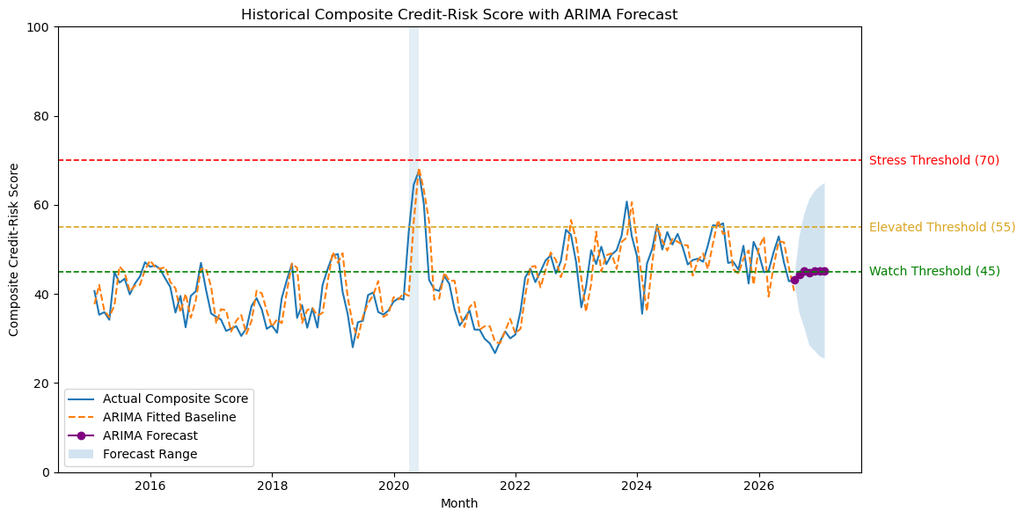

```python
# Build historical composite series

composite_history = dashboard_score_data[
    [
        "month_end",
        "composite_credit_risk_score",
        "composite_credit_risk_regime_revised",
        "usrec"
    ]
].copy()

composite_history["month_end"] = pd.to_datetime(
    composite_history["month_end"]
)

composite_history = composite_history.sort_values("month_end")

# Use 2015 onward for readability.
# The ARIMA model is still trained on the full available operational composite-score history.

chart_start_date = "2015-01-01"

composite_chart_history = composite_history[
    composite_history["month_end"] >= chart_start_date
].copy()

# Refit selected composite ARIMA model on full available composite score history

selected_composite_order = eval(
    arima_selected_models.loc[
        arima_selected_models["score_component"] == "Composite Credit Risk Score",
        "arima_order"
    ].iloc[0]
)

composite_series = (
    composite_history
    .set_index("month_end")["composite_credit_risk_score"]
    .astype(float)
)

composite_arima_model = ARIMA(
    composite_series,
    order=selected_composite_order,
    enforce_stationarity=False,
    enforce_invertibility=False
)

composite_arima_fit = composite_arima_model.fit()

# In-sample fitted values

composite_fitted = pd.DataFrame({
    "month_end": composite_series.index,
    "fitted_score": composite_arima_fit.fittedvalues
}).reset_index(drop=True)

composite_fitted_chart = composite_fitted[
    composite_fitted["month_end"] >= chart_start_date
].copy()

# Six-month forecast

forecast_steps = 6

forecast_result = composite_arima_fit.get_forecast(
    steps=forecast_steps
)

forecast_mean = forecast_result.predicted_mean
forecast_ci = forecast_result.conf_int()

last_actual_date = composite_series.index[-1]

forecast_dates = pd.date_range(
    start=last_actual_date + pd.offsets.MonthEnd(1),
    periods=forecast_steps,
    freq="M"
)

forecast_display = pd.DataFrame({
    "month_end": forecast_dates,
    "forecast_score": forecast_mean.values,
    "lower_range": forecast_ci.iloc[:, 0].values,
    "upper_range": forecast_ci.iloc[:, 1].values
})

forecast_display["forecast_score"] = forecast_display["forecast_score"].clip(
    lower=0,
    upper=100
)

forecast_display["lower_range"] = forecast_display["lower_range"].clip(
    lower=0,
    upper=100
)

forecast_display["upper_range"] = forecast_display["upper_range"].clip(
    lower=0,
    upper=100
)

# Add latest actual point to connect historical line and forecast line

forecast_connector = pd.DataFrame({
    "month_end": [last_actual_date],
    "forecast_score": [composite_series.iloc[-1]],
    "lower_range": [composite_series.iloc[-1]],
    "upper_range": [composite_series.iloc[-1]]
})

forecast_display_with_connector = pd.concat(
    [
        forecast_connector,
        forecast_display
    ],
    ignore_index=True
)

# Plot

fig, ax = plt.subplots(figsize=(12, 6))

ax.plot(
    composite_chart_history["month_end"],
    composite_chart_history["composite_credit_risk_score"],
    label="Actual Composite Score"
)

ax.plot(
    composite_fitted_chart["month_end"],
    composite_fitted_chart["fitted_score"],
    linestyle="--",
    label="ARIMA Fitted Baseline"
)

ax.plot(
    forecast_display_with_connector["month_end"],
    forecast_display_with_connector["forecast_score"],
    marker="o",
    color="purple",
    label="ARIMA Forecast"
)

ax.fill_between(
    forecast_display_with_connector["month_end"],
    forecast_display_with_connector["lower_range"],
    forecast_display_with_connector["upper_range"],
    alpha=0.20,
    label="Forecast Range"
)

# Recession shading

for date in composite_chart_history.loc[
    composite_chart_history["usrec"] == 1,
    "month_end"
]:
    ax.axvspan(
        date,
        date + pd.offsets.MonthEnd(1),
        alpha=0.12
    )

# Revised composite thresholds
# Labels are excluded from the legend and placed directly on the chart.

watch_color = "green"
elevated_color = "goldenrod"
stress_color = "red"

ax.axhline(
    45,
    linestyle="--",
    linewidth=1.2,
    color=watch_color,
    label="_nolegend_"
)

ax.axhline(
    55,
    linestyle="--",
    linewidth=1.2,
    color=elevated_color,
    label="_nolegend_"
)

ax.axhline(
    70,
    linestyle="--",
    linewidth=1.2,
    color=stress_color,
    label="_nolegend_"
)

# Place threshold labels just outside the right edge of the plot.
# x=1.01 means slightly to the right of the plotting area.
# y-values use the actual score scale.

threshold_label_x = 1.01

ax.text(
    threshold_label_x,
    45,
    "Watch Threshold (45)",
    transform=ax.get_yaxis_transform(),
    va="center",
    ha="left",
    color=watch_color,
    clip_on=False,
    bbox=dict(facecolor="white", alpha=0.75, edgecolor="none")
)

ax.text(
    threshold_label_x,
    55,
    "Elevated Threshold (55)",
    transform=ax.get_yaxis_transform(),
    va="center",
    ha="left",
    color=elevated_color,
    clip_on=False,
    bbox=dict(facecolor="white", alpha=0.75, edgecolor="none")
)

ax.text(
    threshold_label_x,
    70,
    "Stress Threshold (70)",
    transform=ax.get_yaxis_transform(),
    va="center",
    ha="left",
    color=stress_color,
    clip_on=False,
    bbox=dict(facecolor="white", alpha=0.75, edgecolor="none")
)

ax.set_title("Historical Composite Credit-Risk Score with ARIMA Forecast")
ax.set_xlabel("Month")
ax.set_ylabel("Composite Credit-Risk Score")
ax.set_ylim(0, 100)

# Keep only the actual/model/forecast items in the legend.
ax.legend(loc="lower left")

# Leave room on the right side for threshold labels.
plt.tight_layout()
fig.subplots_adjust(right=0.82)

plt.show()
```

The ARIMA model is trained on the full available operational composite-score history, while the visualization begins in 2015 for readability and to emphasize the recent forecast window.

### 8.5 Save Dashboard Score Tables

This section saves the final dashboard-ready outputs to SQLite tables. These tables will be used for the visualization section and for the later interactive dashboard layer.

The saved outputs include the full monthly dashboard score table, the current credit-risk snapshot, ARIMA model-selection results, forward score outlooks, composite forecast ranges, ARIMA diagnostics, and realized credit-performance diagnostic checks.

```python
# Convert tuple/list/object values into SQLite-safe strings before saving

def make_sqlite_safe(df):
    df_safe = df.copy()

    for col in df_safe.columns:
        df_safe[col] = df_safe[col].apply(
            lambda x: str(x) if isinstance(x, (tuple, list, dict)) else x
        )

    return df_safe


dashboard_score_data_sql = make_sqlite_safe(dashboard_score_data)
current_credit_risk_snapshot_sql = make_sqlite_safe(current_credit_risk_snapshot)
arima_selected_models_sql = make_sqlite_safe(arima_selected_models)
forward_credit_risk_outlook_sql = make_sqlite_safe(forward_credit_risk_outlook)
composite_outlook_only_sql = make_sqlite_safe(composite_outlook_only)
arima_diagnostic_summary_sql = make_sqlite_safe(arima_diagnostic_summary)
realized_credit_change_summary_sql = make_sqlite_safe(realized_credit_change_summary)
forecast_display_with_connector_sql = make_sqlite_safe(forecast_display_with_connector)
```

```python
dashboard_score_data_sql.to_sql(
    "dashboard_credit_risk_score",
    conn,
    if_exists="replace",
    index=False
)

current_credit_risk_snapshot_sql.to_sql(
    "dashboard_current_credit_risk_snapshot",
    conn,
    if_exists="replace",
    index=False
)

arima_selected_models_sql.to_sql(
    "dashboard_arima_selected_models",
    conn,
    if_exists="replace",
    index=False
)

forward_credit_risk_outlook_sql.to_sql(
    "dashboard_forward_credit_risk_outlook",
    conn,
    if_exists="replace",
    index=False
)

composite_outlook_only_sql.to_sql(
    "dashboard_composite_forward_outlook_range",
    conn,
    if_exists="replace",
    index=False
)

arima_diagnostic_summary_sql.to_sql(
    "dashboard_arima_diagnostic_summary",
    conn,
    if_exists="replace",
    index=False
)

realized_credit_change_summary_sql.to_sql(
    "dashboard_realized_credit_change_summary",
    conn,
    if_exists="replace",
    index=False
)

forecast_display_with_connector_sql.to_sql(
    "dashboard_composite_forecast_chart_data",
    conn,
    if_exists="replace",
    index=False
)

print("Dashboard score tables saved successfully.")
```

```
Dashboard score tables saved successfully.
```

```python
saved_dashboard_tables_check = pd.read_sql_query(
    """
    SELECT
        name AS table_name
    FROM sqlite_master
    WHERE type = 'table'
      AND name LIKE 'dashboard_%'
    ORDER BY name;
    """,
    conn
)

saved_dashboard_tables_check
```

|  | table_name |
| --- | --- |
| 0 | dashboard_arima_diagnostic_summary |
| 1 | dashboard_arima_selected_models |
| 2 | dashboard_composite_forecast_chart_data |
| 3 | dashboard_composite_forward_outlook_range |
| 4 | dashboard_credit_risk_score |
| 5 | dashboard_current_credit_risk_snapshot |
| 6 | dashboard_forward_credit_risk_outlook |
| 7 | dashboard_realized_credit_change_summary |
| 8 | dashboard_visualization_output_summary |

```python
dashboard_table_names = saved_dashboard_tables_check["table_name"].tolist()

for table_name in dashboard_table_names:
    row_count = pd.read_sql_query(
        f"""
        SELECT COUNT(*) AS row_count
        FROM {table_name};
        """,
        conn
    )["row_count"].iloc[0]

    print("\n" + "=" * 100)
    print(f"TABLE: {table_name}")
    print(f"ROWS: {row_count}")
    print("=" * 100)

    if row_count <= 25:
        query = f"""
        SELECT *
        FROM {table_name};
        """
    else:
        query = f"""
        SELECT *
        FROM {table_name}
        LIMIT 10;
        """

    table_preview = pd.read_sql_query(query, conn)
    display(table_preview)
```

```
====================================================================================================
TABLE: dashboard_arima_diagnostic_summary
ROWS: 5
====================================================================================================
```

|  | score_component | selected_arima_order | ljung_box_pvalue_lag6 | adf_pvalue | kpss_pvalue | residual_mean | residual_std |
| --- | --- | --- | --- | --- | --- | --- | --- |
| 0 | Composite Credit Risk Score | (2, 0, 2) | 0.2075 | 0.1288 | 0.1000 | -0.1848 | 4.7070 |
| 1 | Macro / Labor Risk | (2, 1, 2) | 0.0000 | 0.1706 | 0.0165 | 0.1405 | 11.5698 |
| 2 | Market / Financial Stress | (1, 0, 2) | 0.2818 | 0.0032 | 0.1000 | -0.4028 | 10.0738 |
| 3 | Rate / Yield-Curve Pressure | (2, 1, 2) | 0.1114 | 0.6126 | 0.0100 | 0.3523 | 7.2372 |
| 4 | Realized Credit Performance | (0, 1, 2) | 0.5167 | 0.1811 | 0.0517 | 0.1704 | 5.3786 |

```
====================================================================================================
TABLE: dashboard_arima_selected_models
ROWS: 5
====================================================================================================
```

|  | score_component | arima_order | aic | bic |
| --- | --- | --- | --- | --- |
| 0 | Composite Credit Risk Score | (2, 0, 2) | 1493.17 | 1514.47 |
| 1 | Macro / Labor Risk | (2, 1, 2) | 1977.45 | 1995.18 |
| 2 | Market / Financial Stress | (1, 0, 2) | 1890.66 | 1908.41 |
| 3 | Rate / Yield-Curve Pressure | (2, 1, 2) | 1720.31 | 1738.03 |
| 4 | Realized Credit Performance | (0, 1, 2) | 1584.32 | 1594.96 |

```
====================================================================================================
TABLE: dashboard_composite_forecast_chart_data
ROWS: 7
====================================================================================================
```

|  | month_end | forecast_score | lower_range | upper_range |
| --- | --- | --- | --- | --- |
| 0 | 2026-07-31 00:00:00 | 43.140000 | 43.140000 | 43.140000 |
| 1 | 2026-08-31 00:00:00 | 44.300862 | 35.854135 | 52.747590 |
| 2 | 2026-09-30 00:00:00 | 45.233416 | 32.528801 | 57.938030 |
| 3 | 2026-10-31 00:00:00 | 44.831175 | 28.413416 | 61.248934 |
| 4 | 2026-11-30 00:00:00 | 45.177688 | 27.310365 | 63.045011 |
| 5 | 2026-12-31 00:00:00 | 45.070291 | 25.999123 | 64.141459 |
| 6 | 2027-01-31 00:00:00 | 45.209273 | 25.498598 | 64.919948 |

```
====================================================================================================
TABLE: dashboard_composite_forward_outlook_range
ROWS: 4
====================================================================================================
```

|  | outlook_window | selected_arima_order | projected_score | lower_range | upper_range | projected_regime |
| --- | --- | --- | --- | --- | --- | --- |
| 0 | Current | (2, 0, 2) | 43.14 | NaN | NaN | Normal |
| 1 | Projected 1-month | (2, 0, 2) | 44.30 | 35.85 | 52.75 | Normal |
| 2 | Projected 3-month | (2, 0, 2) | 44.83 | 28.41 | 61.25 | Normal |
| 3 | Projected 6-month | (2, 0, 2) | 45.21 | 25.50 | 64.92 | Watch |

```
====================================================================================================
TABLE: dashboard_credit_risk_score
ROWS: 260
====================================================================================================
```

|  | month_end | composite_credit_risk_score | composite_credit_risk_regime_revised | market_financial_stress_score | macro_labor_risk_score | rate_yield_curve_pressure_score | realized_credit_performance_score | composite_score_coverage_pct | provisional_composite_flag | usrec | composite_score_change_1m | composite_score_change_3m | composite_score_change_6m |
| --- | --- | --- | --- | --- | --- | --- | --- | --- | --- | --- | --- | --- | --- |
| 0 | 2004-12-31 00:00:00 | 21.56 | Normal | 3.33 | 42.50 | 35.83 | 4.58 | 100.0 | 0 | 0.0 | NaN | NaN | NaN |
| 1 | 2005-01-31 00:00:00 | 20.90 | Normal | 3.28 | 39.34 | 39.34 | 1.64 | 100.0 | 0 | 0.0 | -0.66 | NaN | NaN |
| 2 | 2005-02-28 00:00:00 | 20.83 | Normal | 2.69 | 39.52 | 38.71 | 2.42 | 100.0 | 0 | 0.0 | -0.07 | NaN | NaN |
| 3 | 2005-03-31 00:00:00 | 27.81 | Normal | 24.11 | 24.88 | 41.48 | 20.75 | 100.0 | 0 | 0.0 | 6.97 | 6.25 | NaN |
| 4 | 2005-04-30 00:00:00 | 33.32 | Normal | 34.08 | 35.57 | 42.98 | 20.66 | 100.0 | 0 | 0.0 | 5.51 | 12.42 | NaN |
| 5 | 2005-05-31 00:00:00 | 32.32 | Normal | 42.29 | 19.31 | 46.56 | 21.11 | 100.0 | 0 | 0.0 | -1.01 | 11.48 | NaN |
| 6 | 2005-06-30 00:00:00 | 28.70 | Normal | 39.72 | 24.17 | 29.37 | 21.55 | 100.0 | 0 | 0.0 | -3.61 | 0.89 | 7.14 |
| 7 | 2005-07-31 00:00:00 | 32.15 | Normal | 25.62 | 23.45 | 37.24 | 42.31 | 100.0 | 0 | 0.0 | 3.45 | -1.17 | 11.25 |
| 8 | 2005-08-31 00:00:00 | 36.21 | Normal | 24.49 | 28.48 | 49.46 | 42.41 | 100.0 | 0 | 0.0 | 4.06 | 3.89 | 15.38 |
| 9 | 2005-09-30 00:00:00 | 43.46 | Normal | 32.47 | 42.06 | 56.79 | 42.51 | 100.0 | 0 | 0.0 | 7.25 | 14.75 | 15.65 |

```
====================================================================================================
TABLE: dashboard_current_credit_risk_snapshot
ROWS: 5
====================================================================================================
```

|  | latest_month | score_component | current_composite_regime | latest_score | prior_month_score | change_1m | change_3m | change_6m | one_month_direction |
| --- | --- | --- | --- | --- | --- | --- | --- | --- | --- |
| 0 | 2026-07-31 | Composite Credit Risk Score | Normal | 43.14 | 42.84 | 0.30 | -9.78 | -1.71 | Stable |
| 1 | 2026-07-31 | Market / Financial Stress | Normal | 27.54 | 17.56 | 9.98 | -27.23 | -9.03 | Deteriorating |
| 2 | 2026-07-31 | Macro / Labor Risk | Normal | 25.75 | 37.39 | -11.64 | -19.10 | -6.04 | Improving |
| 3 | 2026-07-31 | Rate / Yield-Curve Pressure | Normal | 74.94 | 72.12 | 2.82 | 7.13 | 5.80 | Deteriorating |
| 4 | 2026-07-31 | Realized Credit Performance | Normal | 44.31 | 44.29 | 0.02 | 0.05 | 2.40 | Stable |

```
====================================================================================================
TABLE: dashboard_forward_credit_risk_outlook
ROWS: 20
====================================================================================================
```

|  | score_component | selected_arima_order | selection_criterion | outlook_window | projected_score | projected_classification |
| --- | --- | --- | --- | --- | --- | --- |
| 0 | Composite Credit Risk Score | (2, 0, 2) | BIC | Current | 43.14 | Normal |
| 1 | Composite Credit Risk Score | (2, 0, 2) | BIC | Projected 1-month | 44.30 | Normal |
| 2 | Composite Credit Risk Score | (2, 0, 2) | BIC | Projected 3-month | 44.83 | Normal |
| 3 | Composite Credit Risk Score | (2, 0, 2) | BIC | Projected 6-month | 45.21 | Watch |
| 4 | Market / Financial Stress | (1, 0, 2) | BIC | Current | 27.54 | Normal |
| 5 | Market / Financial Stress | (1, 0, 2) | BIC | Projected 1-month | 41.02 | Normal |
| 6 | Market / Financial Stress | (1, 0, 2) | BIC | Projected 3-month | 46.63 | Normal |
| 7 | Market / Financial Stress | (1, 0, 2) | BIC | Projected 6-month | 46.10 | Normal |
| 8 | Macro / Labor Risk | (2, 1, 2) | BIC | Current | 25.75 | Normal |
| 9 | Macro / Labor Risk | (2, 1, 2) | BIC | Projected 1-month | 31.80 | Normal |
| 10 | Macro / Labor Risk | (2, 1, 2) | BIC | Projected 3-month | 34.34 | Normal |
| 11 | Macro / Labor Risk | (2, 1, 2) | BIC | Projected 6-month | 34.12 | Normal |
| 12 | Rate / Yield-Curve Pressure | (2, 1, 2) | BIC | Current | 74.94 | Watch |
| 13 | Rate / Yield-Curve Pressure | (2, 1, 2) | BIC | Projected 1-month | 73.51 | Watch |
| 14 | Rate / Yield-Curve Pressure | (2, 1, 2) | BIC | Projected 3-month | 69.75 | Watch |
| 15 | Rate / Yield-Curve Pressure | (2, 1, 2) | BIC | Projected 6-month | 69.08 | Watch |
| 16 | Realized Credit Performance | (0, 1, 2) | BIC | Current | 44.31 | Normal |
| 17 | Realized Credit Performance | (0, 1, 2) | BIC | Projected 1-month | 44.31 | Normal |
| 18 | Realized Credit Performance | (0, 1, 2) | BIC | Projected 3-month | 44.31 | Normal |
| 19 | Realized Credit Performance | (0, 1, 2) | BIC | Projected 6-month | 44.31 | Normal |

```
====================================================================================================
TABLE: dashboard_realized_credit_change_summary
ROWS: 6
====================================================================================================
```

|  | metric | value |
| --- | --- | --- |
| 0 | Total observations | 260.000000 |
| 1 | Unique score values | 248.000000 |
| 2 | Months with no score change | 7.000000 |
| 3 | Share of months with no score change (%) | 2.692308 |
| 4 | Average absolute monthly change | 2.265290 |
| 5 | Maximum absolute monthly change | 32.450000 |

```
====================================================================================================
TABLE: dashboard_visualization_output_summary
ROWS: 5
====================================================================================================
```

|  | figure_name | figure_path | file_size_kb |
| --- | --- | --- | --- |
| 0 | category_risk_scores_over_time.png | [LOCAL_USER_PATH]\Downloads\Data Analytic Projects\credit_risk_detection_and_monitor_dashboard\outputs\figures\category_risk_scores_over_time.png | 827.60 |
| 1 | composite_credit_risk_regime_distribution.png | [LOCAL_USER_PATH]\Downloads\Data Analytic Projects\credit_risk_detection_and_monitor_dashboard\outputs\figures\composite_credit_risk_regime_distribution.png | 115.43 |
| 2 | full_history_composite_credit_risk_score_revised_thresholds.png | [LOCAL_USER_PATH]\Downloads\Data Analytic Projects\credit_risk_detection_and_monitor_dashboard\outputs\figures\full_history_composite_credit_risk_score_revised_thresholds.png | 282.14 |
| 3 | historical_composite_credit_risk_score_arima_forecast.png | [LOCAL_USER_PATH]\Downloads\Data Analytic Projects\credit_risk_detection_and_monitor_dashboard\outputs\figures\historical_composite_credit_risk_score_arima_forecast.png | 344.60 |
| 4 | latest_category_risk_drivers.png | [LOCAL_USER_PATH]\Downloads\Data Analytic Projects\credit_risk_detection_and_monitor_dashboard\outputs\figures\latest_category_risk_drivers.png | 159.41 |

```python
for table_name in dashboard_table_names:
    print("\n" + "=" * 100)
    print(f"SCHEMA: {table_name}")
    print("=" * 100)

    table_schema = pd.read_sql_query(
        f"""
        PRAGMA table_info({table_name});
        """,
        conn
    )

    display(table_schema)
```

```
====================================================================================================
SCHEMA: dashboard_arima_diagnostic_summary
====================================================================================================
```

|  | cid | name | type | notnull | dflt_value | pk |
| --- | --- | --- | --- | --- | --- | --- |
| 0 | 0 | score_component | TEXT | 0 | None | 0 |
| 1 | 1 | selected_arima_order | TEXT | 0 | None | 0 |
| 2 | 2 | ljung_box_pvalue_lag6 | REAL | 0 | None | 0 |
| 3 | 3 | adf_pvalue | REAL | 0 | None | 0 |
| 4 | 4 | kpss_pvalue | REAL | 0 | None | 0 |
| 5 | 5 | residual_mean | REAL | 0 | None | 0 |
| 6 | 6 | residual_std | REAL | 0 | None | 0 |

```
====================================================================================================
SCHEMA: dashboard_arima_selected_models
====================================================================================================
```

|  | cid | name | type | notnull | dflt_value | pk |
| --- | --- | --- | --- | --- | --- | --- |
| 0 | 0 | score_component | TEXT | 0 | None | 0 |
| 1 | 1 | arima_order | TEXT | 0 | None | 0 |
| 2 | 2 | aic | REAL | 0 | None | 0 |
| 3 | 3 | bic | REAL | 0 | None | 0 |

```
====================================================================================================
SCHEMA: dashboard_composite_forecast_chart_data
====================================================================================================
```

|  | cid | name | type | notnull | dflt_value | pk |
| --- | --- | --- | --- | --- | --- | --- |
| 0 | 0 | month_end | TIMESTAMP | 0 | None | 0 |
| 1 | 1 | forecast_score | REAL | 0 | None | 0 |
| 2 | 2 | lower_range | REAL | 0 | None | 0 |
| 3 | 3 | upper_range | REAL | 0 | None | 0 |

```
====================================================================================================
SCHEMA: dashboard_composite_forward_outlook_range
====================================================================================================
```

|  | cid | name | type | notnull | dflt_value | pk |
| --- | --- | --- | --- | --- | --- | --- |
| 0 | 0 | outlook_window | TEXT | 0 | None | 0 |
| 1 | 1 | selected_arima_order | TEXT | 0 | None | 0 |
| 2 | 2 | projected_score | REAL | 0 | None | 0 |
| 3 | 3 | lower_range | REAL | 0 | None | 0 |
| 4 | 4 | upper_range | REAL | 0 | None | 0 |
| 5 | 5 | projected_regime | TEXT | 0 | None | 0 |

```
====================================================================================================
SCHEMA: dashboard_credit_risk_score
====================================================================================================
```

|  | cid | name | type | notnull | dflt_value | pk |
| --- | --- | --- | --- | --- | --- | --- |
| 0 | 0 | month_end | TIMESTAMP | 0 | None | 0 |
| 1 | 1 | composite_credit_risk_score | REAL | 0 | None | 0 |
| 2 | 2 | composite_credit_risk_regime_revised | TEXT | 0 | None | 0 |
| 3 | 3 | market_financial_stress_score | REAL | 0 | None | 0 |
| 4 | 4 | macro_labor_risk_score | REAL | 0 | None | 0 |
| 5 | 5 | rate_yield_curve_pressure_score | REAL | 0 | None | 0 |
| 6 | 6 | realized_credit_performance_score | REAL | 0 | None | 0 |
| 7 | 7 | composite_score_coverage_pct | REAL | 0 | None | 0 |
| 8 | 8 | provisional_composite_flag | INTEGER | 0 | None | 0 |
| 9 | 9 | usrec | REAL | 0 | None | 0 |
| 10 | 10 | composite_score_change_1m | REAL | 0 | None | 0 |
| 11 | 11 | composite_score_change_3m | REAL | 0 | None | 0 |
| 12 | 12 | composite_score_change_6m | REAL | 0 | None | 0 |

```
====================================================================================================
SCHEMA: dashboard_current_credit_risk_snapshot
====================================================================================================
```

|  | cid | name | type | notnull | dflt_value | pk |
| --- | --- | --- | --- | --- | --- | --- |
| 0 | 0 | latest_month | TEXT | 0 | None | 0 |
| 1 | 1 | score_component | TEXT | 0 | None | 0 |
| 2 | 2 | current_composite_regime | TEXT | 0 | None | 0 |
| 3 | 3 | latest_score | REAL | 0 | None | 0 |
| 4 | 4 | prior_month_score | REAL | 0 | None | 0 |
| 5 | 5 | change_1m | REAL | 0 | None | 0 |
| 6 | 6 | change_3m | REAL | 0 | None | 0 |
| 7 | 7 | change_6m | REAL | 0 | None | 0 |
| 8 | 8 | one_month_direction | TEXT | 0 | None | 0 |

```
====================================================================================================
SCHEMA: dashboard_forward_credit_risk_outlook
====================================================================================================
```

|  | cid | name | type | notnull | dflt_value | pk |
| --- | --- | --- | --- | --- | --- | --- |
| 0 | 0 | score_component | TEXT | 0 | None | 0 |
| 1 | 1 | selected_arima_order | TEXT | 0 | None | 0 |
| 2 | 2 | selection_criterion | TEXT | 0 | None | 0 |
| 3 | 3 | outlook_window | TEXT | 0 | None | 0 |
| 4 | 4 | projected_score | REAL | 0 | None | 0 |
| 5 | 5 | projected_classification | TEXT | 0 | None | 0 |

```
====================================================================================================
SCHEMA: dashboard_realized_credit_change_summary
====================================================================================================
```

|  | cid | name | type | notnull | dflt_value | pk |
| --- | --- | --- | --- | --- | --- | --- |
| 0 | 0 | metric | TEXT | 0 | None | 0 |
| 1 | 1 | value | REAL | 0 | None | 0 |

```
====================================================================================================
SCHEMA: dashboard_visualization_output_summary
====================================================================================================
```

|  | cid | name | type | notnull | dflt_value | pk |
| --- | --- | --- | --- | --- | --- | --- |
| 0 | 0 | figure_name | TEXT | 0 | None | 0 |
| 1 | 1 | figure_path | TEXT | 0 | None | 0 |
| 2 | 2 | file_size_kb | REAL | 0 | None | 0 |

### 8.5.1 Dashboard Table Outputs

The dashboard output tables saved in Section 8 organize the final scoring, forecasting, diagnostic, and visualization-support data into reusable SQLite tables. These tables allow the notebook outputs to be reused later in a dashboard application without rerunning the full data-ingestion, feature-engineering, scoring, and model-selection pipeline.

The saved dashboard tables include the final Composite Credit Risk Score, the latest score snapshot, selected ARIMA model orders, the forward credit-risk outlook, the composite forecast range, forecast diagnostics, realized credit-performance stability checks, and chart-ready composite forecast data.

The main dashboard table is `dashboard_credit_risk_score`. This table contains the full operational monthly score history, including the revised composite regime, category scores, recession indicator, score coverage, and provisional-score flag.

The `dashboard_current_credit_risk_snapshot` table summarizes the latest dashboard reading. It is designed to support current-state interpretation by showing the latest composite score, latest category scores, prior-month scores, and recent 1-month, 3-month, and 6-month changes.

The `dashboard_forward_credit_risk_outlook` table stores the current, 1-month, 3-month, and 6-month forecast values for the composite score and category components. This table supports the forward-looking monitoring layer of the dashboard.

The `dashboard_composite_forward_outlook_range` table stores the composite score forecast range. This table is useful because the forecast range provides uncertainty context around the ARIMA point forecast.

The `dashboard_arima_selected_models` and `dashboard_arima_diagnostic_summary` tables document the selected ARIMA specifications and diagnostic checks used for the baseline forecast layer. These outputs make the forecast process more transparent and easier to audit.

The `dashboard_realized_credit_change_summary` table documents the recent behavior of the realized credit-performance component. This is useful because realized credit indicators such as delinquency and charge-off measures move more slowly than market and rate variables.

The `dashboard_composite_forecast_chart_data` table stores chart-ready data for the historical composite score and ARIMA forecast visualization.

Together, these tables separate the final dashboard outputs from the raw pipeline. This makes the project easier to extend into Streamlit because the dashboard can read from saved SQLite outputs instead of rebuilding every intermediate step.

### 8.6 Section 8 Wrap-Up

Section 8 converts the scored macro-credit framework into dashboard-ready outputs.

The section begins by organizing the final Composite Credit Risk Score and revised regime labels into a clean score table. This table provides the monthly history of the dashboardâ€™s primary risk measure, along with the four underlying category scores: Market / Financial Stress, Macro / Labor Risk, Rate / Yield-Curve Pressure, and Realized Credit Performance.

The latest snapshot table then converts the historical score table into a current monitoring view. It shows the latest composite score, current regime, category-level drivers, and recent 1-month, 3-month, and 6-month changes. This helps answer whether macro-credit conditions are currently improving, stabilizing, or deteriorating.

Section 8 also creates the forward-looking baseline outlook using ARIMA model selection. Instead of forcing one model structure onto every score component, each composite or category score is evaluated using a common ARIMA candidate grid, and the selected model is chosen using information criteria. The Composite Credit Risk Score selected an ARIMA(2, 0, 2) specification, while individual category scores selected their own model orders based on their different time-series behavior.

The ARIMA forecast is used as a baseline monitoring path, not as a full stress scenario. The 1-month forecast is the most directly useful forecast window, the 3-month forecast is a reasonable monitoring baseline, and the 6-month forecast should be interpreted more cautiously because macro-credit conditions can shift quickly.

The section also documents forecast limitations. Realized Credit Performance is slower-moving because delinquency and charge-off indicators are reported at lower frequency and are forward-filled into the monthly dashboard structure. As a result, the realized credit-performance forecast may appear flat in the near term. This is treated as a limitation of the Version 1 forecast layer, not as a coding error.

The historical composite score with ARIMA forecast visualization provides the main forward-looking chart for the dashboard. It shows the recent composite score path, revised regime thresholds, baseline forecast, and forecast range.

Finally, Section 8 saves all dashboard-ready tables to SQLite. These saved outputs create the bridge between the analytical notebook and the future Streamlit dashboard. Instead of rebuilding the entire workflow each time, the dashboard can load the final score, snapshot, forecast, diagnostics, and chart-ready tables directly from the database.

The main result of Section 8 is a complete dashboard output layer: current score, current drivers, recent changes, forecast outlook, forecast diagnostics, visualization-ready data, and reusable SQLite tables.

## 9. Visualizations

Section 9 converts the dashboard-ready SQLite outputs into final visualizations. These charts are designed to communicate the current macro-credit risk score, historical regime behavior, category-level drivers, and forward ARIMA outlook.

The visualizations are built from the saved `dashboard_%` tables created in Section 8. This keeps the project workflow reproducible: earlier sections create and validate the scores, while this section focuses only on presenting those results clearly.

The goal of this section is to create presentation-ready charts that can be used in the final notebook, GitHub repository, and future interactive dashboard.

### 9.1 Visualization Setup

This section loads the saved dashboard tables from SQLite and sets the output location for saved chart files. Final chart images will be exported to the `outputs/figures/` folder so they can be used in the GitHub README, portfolio materials, and later Streamlit dashboard development.

```python
from pathlib import Path
import matplotlib.pyplot as plt
import pandas as pd
import numpy as np

figures_dir = project_root / "outputs" / "figures"
figures_dir.mkdir(parents=True, exist_ok=True)

dashboard_credit_risk_score = pd.read_sql_query(
    """
    SELECT *
    FROM dashboard_credit_risk_score
    ORDER BY month_end;
    """,
    conn
)

dashboard_current_credit_risk_snapshot = pd.read_sql_query(
    """
    SELECT *
    FROM dashboard_current_credit_risk_snapshot;
    """,
    conn
)

dashboard_arima_selected_models = pd.read_sql_query(
    """
    SELECT *
    FROM dashboard_arima_selected_models;
    """,
    conn
)

dashboard_forward_credit_risk_outlook = pd.read_sql_query(
    """
    SELECT *
    FROM dashboard_forward_credit_risk_outlook;
    """,
    conn
)

dashboard_composite_forward_outlook_range = pd.read_sql_query(
    """
    SELECT *
    FROM dashboard_composite_forward_outlook_range;
    """,
    conn
)

dashboard_composite_forecast_chart_data = pd.read_sql_query(
    """
    SELECT *
    FROM dashboard_composite_forecast_chart_data
    ORDER BY month_end;
    """,
    conn
)

dashboard_credit_risk_score["month_end"] = pd.to_datetime(
    dashboard_credit_risk_score["month_end"]
)

dashboard_composite_forecast_chart_data["month_end"] = pd.to_datetime(
    dashboard_composite_forecast_chart_data["month_end"]
)

print("Dashboard visualization tables loaded successfully.")
print(f"Figures will be saved to: {figures_dir}")
```

```
Dashboard visualization tables loaded successfully.
Figures will be saved to: [LOCAL_USER_PATH]\Downloads\Data Analytic Projects\credit_risk_detection_and_monitor_dashboard\outputs\figures
```

### 9.2 Historical Composite Credit-Risk Score with ARIMA Forecast

This chart shows the historical Composite Credit Risk Score, the selected ARIMA fitted baseline, and the six-month forward ARIMA forecast. The visualization begins in 2015 for readability, while the selected ARIMA model was trained using the full available operational composite-score history.

The chart includes revised regime thresholds for Watch, Elevated, and Stress. The forecast line and uncertainty range show whether the projected score remains within the current regime or approaches a higher-risk threshold.

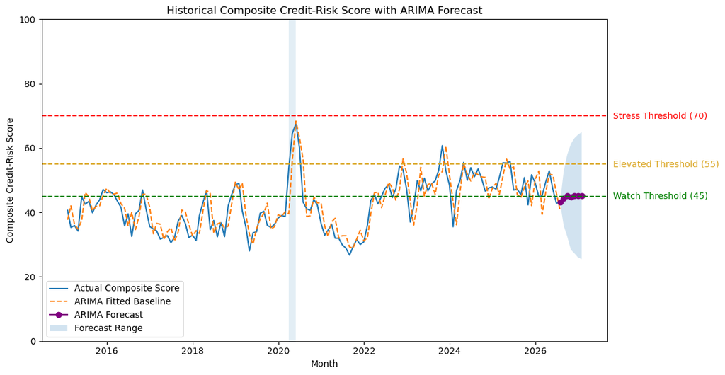

```
Saved figure to: [LOCAL_USER_PATH]\Downloads\Data Analytic Projects\credit_risk_detection_and_monitor_dashboard\outputs\figures\historical_composite_credit_risk_score_arima_forecast.png
```

```python
# Rebuild the historical + fitted + forecast visualization from saved dashboard outputs

chart_start_date = "2015-01-01"

composite_chart_history = dashboard_credit_risk_score[
    dashboard_credit_risk_score["month_end"] >= chart_start_date
].copy()

# Refit selected composite ARIMA model for fitted values
selected_composite_order = eval(
    dashboard_arima_selected_models.loc[
        dashboard_arima_selected_models["score_component"] == "Composite Credit Risk Score",
        "arima_order"
    ].iloc[0]
)

composite_series = (
    dashboard_credit_risk_score
    .set_index("month_end")["composite_credit_risk_score"]
    .astype(float)
)

composite_arima_model = ARIMA(
    composite_series,
    order=selected_composite_order,
    enforce_stationarity=False,
    enforce_invertibility=False
)

composite_arima_fit = composite_arima_model.fit()

composite_fitted = pd.DataFrame({
    "month_end": composite_series.index,
    "fitted_score": composite_arima_fit.fittedvalues
}).reset_index(drop=True)

composite_fitted_chart = composite_fitted[
    composite_fitted["month_end"] >= chart_start_date
].copy()

forecast_display_with_connector = dashboard_composite_forecast_chart_data.copy()

# Plot
fig, ax = plt.subplots(figsize=(12, 6))

ax.plot(
    composite_chart_history["month_end"],
    composite_chart_history["composite_credit_risk_score"],
    label="Actual Composite Score"
)

ax.plot(
    composite_fitted_chart["month_end"],
    composite_fitted_chart["fitted_score"],
    linestyle="--",
    label="ARIMA Fitted Baseline"
)

ax.plot(
    forecast_display_with_connector["month_end"],
    forecast_display_with_connector["forecast_score"],
    marker="o",
    color="purple",
    label="ARIMA Forecast"
)

ax.fill_between(
    forecast_display_with_connector["month_end"],
    forecast_display_with_connector["lower_range"],
    forecast_display_with_connector["upper_range"],
    alpha=0.20,
    label="Forecast Range"
)

# Recession shading
for date in composite_chart_history.loc[
    composite_chart_history["usrec"] == 1,
    "month_end"
]:
    ax.axvspan(
        date,
        date + pd.offsets.MonthEnd(1),
        alpha=0.12
    )

# Thresholds
watch_threshold = 45
elevated_threshold = 55
stress_threshold = 70

watch_color = "green"
elevated_color = "goldenrod"
stress_color = "red"

ax.axhline(
    watch_threshold,
    linestyle="--",
    linewidth=1.3,
    color=watch_color,
    label="_nolegend_"
)

ax.axhline(
    elevated_threshold,
    linestyle="--",
    linewidth=1.3,
    color=elevated_color,
    label="_nolegend_"
)

ax.axhline(
    stress_threshold,
    linestyle="--",
    linewidth=1.3,
    color=stress_color,
    label="_nolegend_"
)

threshold_label_x = 1.01

ax.text(
    threshold_label_x,
    watch_threshold,
    "Watch Threshold (45)",
    transform=ax.get_yaxis_transform(),
    va="center",
    ha="left",
    color=watch_color,
    clip_on=False,
    bbox=dict(facecolor="white", alpha=0.75, edgecolor="none")
)

ax.text(
    threshold_label_x,
    elevated_threshold,
    "Elevated Threshold (55)",
    transform=ax.get_yaxis_transform(),
    va="center",
    ha="left",
    color=elevated_color,
    clip_on=False,
    bbox=dict(facecolor="white", alpha=0.75, edgecolor="none")
)

ax.text(
    threshold_label_x,
    stress_threshold,
    "Stress Threshold (70)",
    transform=ax.get_yaxis_transform(),
    va="center",
    ha="left",
    color=stress_color,
    clip_on=False,
    bbox=dict(facecolor="white", alpha=0.75, edgecolor="none")
)

ax.set_title("Historical Composite Credit-Risk Score with ARIMA Forecast")
ax.set_xlabel("Month")
ax.set_ylabel("Composite Credit-Risk Score")
ax.set_ylim(0, 100)
ax.legend(loc="lower left")

plt.tight_layout()
fig.subplots_adjust(right=0.80)

figure_path = figures_dir / "historical_composite_credit_risk_score_arima_forecast.png"

plt.savefig(
    figure_path,
    dpi=300,
    bbox_inches="tight"
)

plt.show()

print(f"Saved figure to: {figure_path}")
```

### 9.3 Full-History Composite Score with Revised Thresholds

This chart shows the full operational history of the Composite Credit Risk Score using the revised 45 / 55 / 70 regime thresholds. Unlike the ARIMA forecast chart, which begins in 2015 for readability, this chart starts at the first fully operational composite-score month.

The purpose of this visualization is to show how the revised regime thresholds behave across the full historical sample. This is especially important for validating the Stress threshold because the 2008 credit crisis provides a broad macro-credit stress episode for comparison.

The chart includes recession shading and the revised threshold lines:

- Watch threshold: 45
- Elevated threshold: 55
- Stress threshold: 70

This chart helps answer whether the revised thresholds create economically sensible separation across normal periods, watch periods, elevated-risk periods, and severe stress periods.

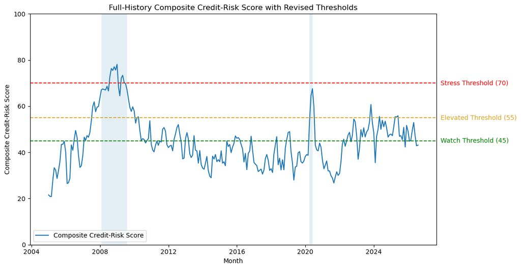

```
Saved figure to: [LOCAL_USER_PATH]\Downloads\Data Analytic Projects\credit_risk_detection_and_monitor_dashboard\outputs\figures\full_history_composite_credit_risk_score_revised_thresholds.png
```

```python
full_history_composite = dashboard_credit_risk_score.copy()

full_history_composite["month_end"] = pd.to_datetime(
    full_history_composite["month_end"]
)

full_history_composite = full_history_composite.sort_values("month_end")

fig, ax = plt.subplots(figsize=(12, 6))

ax.plot(
    full_history_composite["month_end"],
    full_history_composite["composite_credit_risk_score"],
    label="Composite Credit-Risk Score"
)

# Recession shading
for date in full_history_composite.loc[
    full_history_composite["usrec"] == 1,
    "month_end"
]:
    ax.axvspan(
        date,
        date + pd.offsets.MonthEnd(1),
        alpha=0.12
    )

# Revised composite thresholds
watch_threshold = 45
elevated_threshold = 55
stress_threshold = 70

watch_color = "green"
elevated_color = "goldenrod"
stress_color = "red"

ax.axhline(
    watch_threshold,
    linestyle="--",
    linewidth=1.3,
    color=watch_color,
    label="_nolegend_"
)

ax.axhline(
    elevated_threshold,
    linestyle="--",
    linewidth=1.3,
    color=elevated_color,
    label="_nolegend_"
)

ax.axhline(
    stress_threshold,
    linestyle="--",
    linewidth=1.3,
    color=stress_color,
    label="_nolegend_"
)

# Place threshold labels outside the right side of the plot
threshold_label_x = 1.01

ax.text(
    threshold_label_x,
    watch_threshold,
    "Watch Threshold (45)",
    transform=ax.get_yaxis_transform(),
    va="center",
    ha="left",
    color=watch_color,
    clip_on=False,
    bbox=dict(facecolor="white", alpha=0.75, edgecolor="none")
)

ax.text(
    threshold_label_x,
    elevated_threshold,
    "Elevated Threshold (55)",
    transform=ax.get_yaxis_transform(),
    va="center",
    ha="left",
    color=elevated_color,
    clip_on=False,
    bbox=dict(facecolor="white", alpha=0.75, edgecolor="none")
)

ax.text(
    threshold_label_x,
    stress_threshold,
    "Stress Threshold (70)",
    transform=ax.get_yaxis_transform(),
    va="center",
    ha="left",
    color=stress_color,
    clip_on=False,
    bbox=dict(facecolor="white", alpha=0.75, edgecolor="none")
)

ax.set_title("Full-History Composite Credit-Risk Score with Revised Thresholds")
ax.set_xlabel("Month")
ax.set_ylabel("Composite Credit-Risk Score")
ax.set_ylim(0, 100)
ax.legend(loc="lower left")

plt.tight_layout()
fig.subplots_adjust(right=0.80)

figure_path = figures_dir / "full_history_composite_credit_risk_score_revised_thresholds.png"

plt.savefig(
    figure_path,
    dpi=300,
    bbox_inches="tight"
)

plt.show()

print(f"Saved figure to: {figure_path}")
```

### Full-History Composite Score Interpretation

The full-history composite chart shows how the revised 45 / 55 / 70 thresholds classify macro-credit conditions across the operational sample. The revised thresholds are useful because they identify both moderate deterioration and severe broad-based stress without requiring the composite score to reach the original 90-point Stress threshold.

The 2008 credit crisis period reaches the Stress range under the revised framework, which supports the decision to use 70 as the Stress threshold. This indicates that the Stress label is reserved for severe broad-based macro-credit deterioration rather than ordinary volatility.

The 2020 recession period shows a sharp increase in the composite score, but it does not behave identically to the 2008 credit cycle. This is consistent with the interpretation that 2020 was a severe market and labor shock, while 2008 was a broader credit-system stress event.

Overall, the full-history chart supports the revised threshold framework. The composite score rises during known stress periods, separates severe credit-cycle stress from lower-risk environments, and provides a clearer historical context for interpreting the latest dashboard reading.

### 9.4 Latest Category Driver Visualization

This chart shows the latest category-level risk scores that make up the Composite Credit Risk Score. The purpose is to identify which part of the macro-credit environment is contributing most to the current dashboard reading.

The four category scores are measured on a 0 to 100 scale:

- Market / Financial Stress
- Macro / Labor Risk
- Rate / Yield-Curve Pressure
- Realized Credit Performance

This visualization helps separate the overall composite score from its underlying drivers. A composite score can remain Normal even when one category is elevated, so the category driver view is necessary for understanding where risk is concentrated.

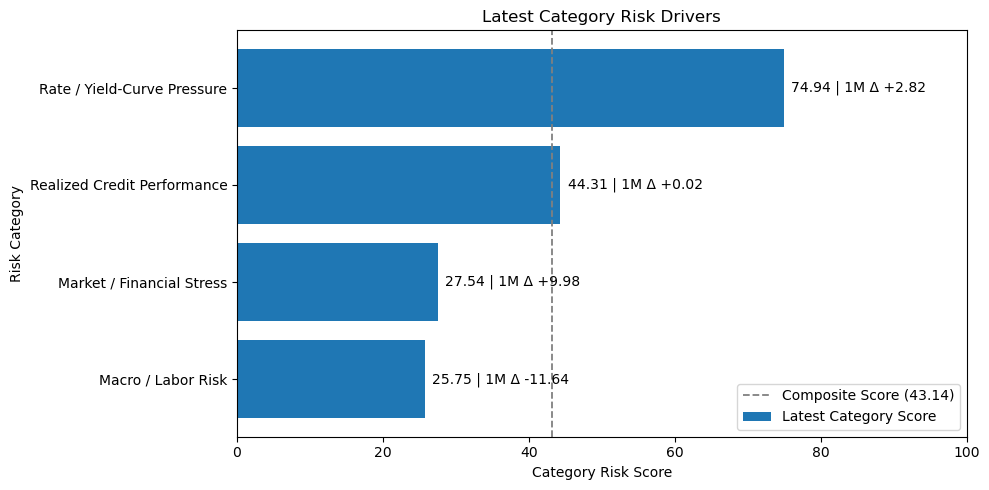

```
Saved figure to: [LOCAL_USER_PATH]\Downloads\Data Analytic Projects\credit_risk_detection_and_monitor_dashboard\outputs\figures\latest_category_risk_drivers.png
```

```python
latest_category_driver_chart_data = dashboard_current_credit_risk_snapshot[
    dashboard_current_credit_risk_snapshot["score_component"] != "Composite Credit Risk Score"
].copy()

latest_category_driver_chart_data = (
    latest_category_driver_chart_data
    .sort_values("latest_score", ascending=True)
    .reset_index(drop=True)
)

latest_composite_score = dashboard_current_credit_risk_snapshot.loc[
    dashboard_current_credit_risk_snapshot["score_component"] == "Composite Credit Risk Score",
    "latest_score"
].iloc[0]

fig, ax = plt.subplots(figsize=(10, 5))

bars = ax.barh(
    latest_category_driver_chart_data["score_component"],
    latest_category_driver_chart_data["latest_score"],
    label="Latest Category Score"
)

# Composite score reference line
ax.axvline(
    latest_composite_score,
    linestyle="--",
    linewidth=1.3,
    color="gray",
    label=f"Composite Score ({latest_composite_score:.2f})"
)

# Add latest score and 1-month change labels to each bar
for i, row in latest_category_driver_chart_data.iterrows():
    score = row["latest_score"]
    change = row["change_1m"]

    if change > 0:
        change_text = f"+{change:.2f}"
    else:
        change_text = f"{change:.2f}"

    ax.text(
        score + 1,
        i,
        f"{score:.2f} | 1M Î” {change_text}",
        va="center",
        ha="left"
    )

ax.set_title("Latest Category Risk Drivers")
ax.set_xlabel("Category Risk Score")
ax.set_ylabel("Risk Category")
ax.set_xlim(0, 100)
ax.legend(loc="lower right")

plt.tight_layout()

figure_path = figures_dir / "latest_category_risk_drivers.png"

plt.savefig(
    figure_path,
    dpi=300,
    bbox_inches="tight"
)

plt.show()

print(f"Saved figure to: {figure_path}")
```

### 9.4 Latest Category Driver Interpretation

This chart explains **what is driving the current Composite Credit Risk Score** by breaking the composite into its four underlying category scores:

- **Market / Financial Stress**
- **Macro / Labor Risk**
- **Rate / Yield-Curve Pressure**
- **Realized Credit Performance**

Each category score is a **percentile-based risk score from 0 to 100**, where higher values indicate greater historical risk pressure in that part of the macro-credit environment. These are **not raw data values** and they are **not regression coefficients**. Instead, they are constructed through the projectâ€™s scoring framework:

1. Raw macro-credit indicators are collected from public sources.
2. Daily, monthly, and quarterly series are aligned into a monthly dashboard structure.
3. Features are engineered using levels, moving averages, and point-to-point changes.
4. Each feature is directionally transformed so that higher values consistently represent higher risk.
5. Each feature is converted into an **expanding percentile score** to avoid lookahead bias.
6. Related feature percentile scores are averaged into category scores.
7. The four category scores are then averaged into the **Composite Credit Risk Score**.

This percentile-based approach makes indicators with different units comparable. For example, VIX, unemployment, Treasury yields, credit spreads, delinquency rates, and charge-off rates all have different scales, so converting them into percentile risk scores places them onto a common 0â€“100 framework.

The four category drivers represent different channels of macro-credit stress:

- **Market / Financial Stress** captures fast-moving financial stress through indicators such as VIX, corporate credit spread pressure, and the St. Louis Fed Financial Stress Index.
- **Macro / Labor Risk** captures labor-market deterioration, primarily through unemployment-related features, which matter because weakening employment can eventually pressure borrower repayment capacity.
- **Rate / Yield-Curve Pressure** captures interest-rate pressure and yield-curve stress, including the transformed inversion-risk signal.
- **Realized Credit Performance** captures observed credit deterioration through delinquency and charge-off indicators. These are the most direct credit-performance measures, but they tend to move more slowly than market variables because they are more lagging in nature.

This chart is designed to identify the **current risk drivers**, not to assign final regimes to each category. The final dashboard regime is based on the **Composite Credit Risk Score**, which is the equal-weighted average of the four category scores.

The vertical dashed reference line shows the **current Composite Credit Risk Score**. Category scores above the composite line are contributing more heavily to the current reading, while category scores below the composite line are contributing less.

The **“1M Î””** label next to each bar shows the **one-month point-to-point change** in that category score. A positive value means that category’s risk pressure increased over the prior month, while a negative value means that risk pressure declined.

In the latest reading, **Rate / Yield-Curve Pressure** is the largest category driver, while **Market / Financial Stress** and **Macro / Labor Risk** are lower contributors. This indicates that the current composite score is not being driven by broad-based stress across all categories. Instead, the primary pressure is concentrated in the **rate/yield-curve component**.

```python
category_driver_methodology = pd.DataFrame({
    "category_driver": [
        "Market / Financial Stress",
        "Macro / Labor Risk",
        "Rate / Yield-Curve Pressure",
        "Realized Credit Performance"
    ],
    "main_inputs": [
        "VIXCLS, BAA10Y, STLFSI4, 3-month averages, 3-month changes",
        "UNRATE, unemployment 3-month average, unemployment 3-month change",
        "DGS30, DGS30 3-month change, transformed T10Y2Y inversion risk",
        "DRALACBS, CORALACBS, delinquency and charge-off levels / changes"
    ],
    "risk_channel": [
        "Market volatility, spread pressure, and broad financial stress",
        "Labor-market deterioration and borrower repayment pressure",
        "Interest-rate pressure, refinancing pressure, and yield-curve stress",
        "Observed borrower delinquency and bank credit-loss performance"
    ],
    "interpretation": [
        "Higher score means market and financial conditions are more stressed.",
        "Higher score means labor conditions are weakening relative to history.",
        "Higher score means rate and curve conditions are more restrictive or inverted.",
        "Higher score means realized credit performance is deteriorating."
    ]
})

category_driver_methodology
```

|  | category_driver | main_inputs | risk_channel | interpretation |
| --- | --- | --- | --- | --- |
| 0 | Market / Financial Stress | VIXCLS, BAA10Y, STLFSI4, 3-month averages, 3-month changes | Market volatility, spread pressure, and broad financial stress | Higher score means market and financial conditions are more stressed. |
| 1 | Macro / Labor Risk | UNRATE, unemployment 3-month average, unemployment 3-month change | Labor-market deterioration and borrower repayment pressure | Higher score means labor conditions are weakening relative to history. |
| 2 | Rate / Yield-Curve Pressure | DGS30, DGS30 3-month change, transformed T10Y2Y inversion risk | Interest-rate pressure, refinancing pressure, and yield-curve stress | Higher score means rate and curve conditions are more restrictive or inverted. |
| 3 | Realized Credit Performance | DRALACBS, CORALACBS, delinquency and charge-off levels / changes | Observed borrower delinquency and bank credit-loss performance | Higher score means realized credit performance is deteriorating. |

### 9.5 Category Risk Scores Over Time

This chart shows the historical movement of the four category-level risk scores that make up the Composite Credit Risk Score. Each category is measured on the same 0 to 100 percentile-risk scale, where higher values indicate greater historical risk pressure.

The purpose of this visualization is to show that the four risk categories do not always move together. Market stress can move quickly, labor risk can lag, rate/yield-curve pressure can appear before realized credit deterioration, and realized credit performance can move more slowly as delinquencies and charge-offs materialize.

This chart helps explain why the composite score is useful: it summarizes broad macro-credit stress while still allowing the dashboard to identify which category is driving the score during different periods.

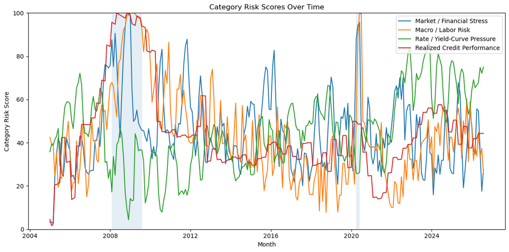

```
Saved figure to: [LOCAL_USER_PATH]\Downloads\Data Analytic Projects\credit_risk_detection_and_monitor_dashboard\outputs\figures\category_risk_scores_over_time.png
```

```python
category_score_history = dashboard_credit_risk_score[
    [
        "month_end",
        "market_financial_stress_score",
        "macro_labor_risk_score",
        "rate_yield_curve_pressure_score",
        "realized_credit_performance_score",
        "usrec"
    ]
].copy()

category_score_history["month_end"] = pd.to_datetime(
    category_score_history["month_end"]
)

category_score_history = category_score_history.sort_values("month_end")

fig, ax = plt.subplots(figsize=(12, 6))

ax.plot(
    category_score_history["month_end"],
    category_score_history["market_financial_stress_score"],
    label="Market / Financial Stress"
)

ax.plot(
    category_score_history["month_end"],
    category_score_history["macro_labor_risk_score"],
    label="Macro / Labor Risk"
)

ax.plot(
    category_score_history["month_end"],
    category_score_history["rate_yield_curve_pressure_score"],
    label="Rate / Yield-Curve Pressure"
)

ax.plot(
    category_score_history["month_end"],
    category_score_history["realized_credit_performance_score"],
    label="Realized Credit Performance"
)

# Recession shading
for date in category_score_history.loc[
    category_score_history["usrec"] == 1,
    "month_end"
]:
    ax.axvspan(
        date,
        date + pd.offsets.MonthEnd(1),
        alpha=0.12
    )

ax.set_title("Category Risk Scores Over Time")
ax.set_xlabel("Month")
ax.set_ylabel("Category Risk Score")
ax.set_ylim(0, 100)
ax.legend(loc="upper right")

plt.tight_layout()

figure_path = figures_dir / "category_risk_scores_over_time.png"

plt.savefig(
    figure_path,
    dpi=300,
    bbox_inches="tight"
)

plt.show()

print(f"Saved figure to: {figure_path}")
```

### Category Risk Score Trend Interpretation

The category score trend chart shows that the four components of the composite score behave differently across the credit cycle. This supports the decision to keep category-level scores visible instead of relying only on the final composite score.

Market / Financial Stress tends to move quickly during periods of market volatility, liquidity stress, and credit-spread pressure. This category is useful for identifying faster-moving stress signals because market prices and volatility indicators can adjust quickly when investors reprice risk.

Macro / Labor Risk tends to rise during or after economic deterioration because labor-market stress often develops after financial conditions have already weakened. In this dashboard, labor risk is therefore more useful as a confirmation and persistence signal than as the earliest warning signal.

Rate / Yield-Curve Pressure can behave differently from the other categories because rate pressure and yield-curve inversion may appear before realized credit losses. A higher score in this category means the rate/yield-curve channel is contributing more macro-credit risk relative to its own historical distribution. This can happen before recession conditions are fully visible in labor or credit-performance data.

Realized Credit Performance tends to move more slowly because delinquency and charge-off indicators are observed credit outcomes. These indicators confirm that credit deterioration has reached borrowers and bank loan performance, but they may lag faster-moving market, rate, and labor signals.

This chart helps explain why the composite score can remain moderate even when one category is elevated. A high score in one category does not automatically mean broad-based credit stress. The dashboard becomes more concerning when multiple categories rise together.

**Source note:** The interpretation of yield-curve pressure as an early macro-risk signal is consistent with Federal Reserve research describing the Treasury yield curve slope and inversion as leading recession indicators. The interpretation of realized credit performance as a slower-moving confirmation channel is based on the Federal Reserveâ€™s charge-off and delinquency rate data, where delinquency and charge-off measures represent observed credit-performance outcomes rather than forward-looking market prices.

### 9.5B Trailing 12-Month Category Score Zoom

This chart zooms in on the most recent 12 months of category-level risk scores. The full-history category chart is useful for long-term validation, but the trailing 12-month view is better for interpreting the current dashboard reading.

The purpose of this chart is to show whether the latest composite score is improving, deteriorating, or being driven by one concentrated category. It also helps explain whether the current risk environment is broad-based or isolated within a specific risk channel.

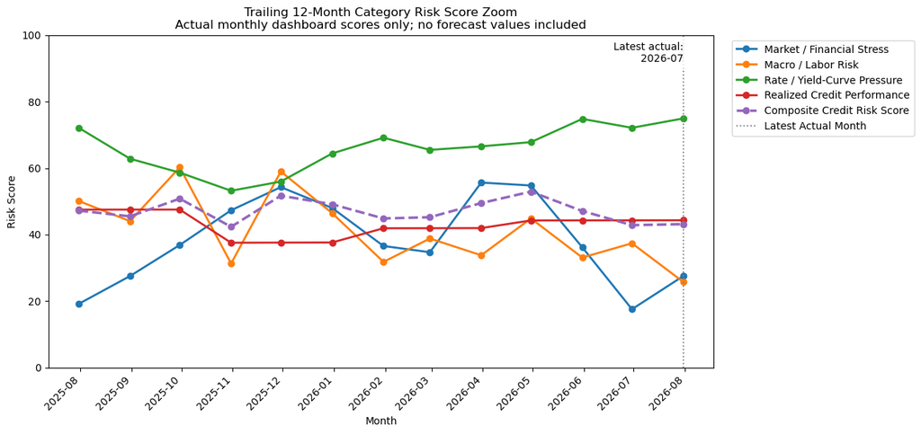

```
Saved figure to: [LOCAL_USER_PATH]\Downloads\Data Analytic Projects\credit_risk_detection_and_monitor_dashboard\outputs\figures\trailing_12_month_category_risk_score_zoom.png
```

```python
import matplotlib.dates as mdates

category_score_zoom = dashboard_credit_risk_score[
    [
        "month_end",
        "composite_credit_risk_score",
        "market_financial_stress_score",
        "macro_labor_risk_score",
        "rate_yield_curve_pressure_score",
        "realized_credit_performance_score",
        "usrec"
    ]
].copy()

category_score_zoom["month_end"] = pd.to_datetime(category_score_zoom["month_end"])
category_score_zoom = category_score_zoom.sort_values("month_end")

latest_month = category_score_zoom["month_end"].max()
zoom_start_month = latest_month - pd.DateOffset(months=12)

category_score_zoom_12m = category_score_zoom[
    category_score_zoom["month_end"] >= zoom_start_month
].copy()

fig, ax = plt.subplots(figsize=(13, 6))

ax.plot(
    category_score_zoom_12m["month_end"],
    category_score_zoom_12m["market_financial_stress_score"],
    marker="o",
    linewidth=2,
    label="Market / Financial Stress"
)

ax.plot(
    category_score_zoom_12m["month_end"],
    category_score_zoom_12m["macro_labor_risk_score"],
    marker="o",
    linewidth=2,
    label="Macro / Labor Risk"
)

ax.plot(
    category_score_zoom_12m["month_end"],
    category_score_zoom_12m["rate_yield_curve_pressure_score"],
    marker="o",
    linewidth=2,
    label="Rate / Yield-Curve Pressure"
)

ax.plot(
    category_score_zoom_12m["month_end"],
    category_score_zoom_12m["realized_credit_performance_score"],
    marker="o",
    linewidth=2,
    label="Realized Credit Performance"
)

ax.plot(
    category_score_zoom_12m["month_end"],
    category_score_zoom_12m["composite_credit_risk_score"],
    marker="o",
    linestyle="--",
    linewidth=2.5,
    label="Composite Credit Risk Score"
)

# Recession shading, if any recession months are present
for date in category_score_zoom_12m.loc[
    category_score_zoom_12m["usrec"] == 1,
    "month_end"
]:
    ax.axvspan(
        date,
        date + pd.offsets.MonthEnd(1),
        alpha=0.12
    )

# Force monthly x-axis labels
ax.xaxis.set_major_locator(mdates.MonthLocator(interval=1))
ax.xaxis.set_major_formatter(mdates.DateFormatter("%Y-%m"))

plt.setp(
    ax.get_xticklabels(),
    rotation=45,
    ha="right"
)

# Mark latest actual observation
latest_actual_row = category_score_zoom_12m[
    category_score_zoom_12m["month_end"] == latest_month
].iloc[0]

ax.axvline(
    latest_month,
    linestyle=":",
    linewidth=1.3,
    color="gray",
    label="Latest Actual Month"
)

ax.text(
    latest_month,
    98,
    f"Latest actual:\n{latest_month.strftime('%Y-%m')}",
    ha="right",
    va="top",
    bbox=dict(facecolor="white", alpha=0.80, edgecolor="none")
)

ax.set_title(
    "Trailing 12-Month Category Risk Score Zoom\nActual monthly dashboard scores only; no forecast values included"
)

ax.set_xlabel("Month")
ax.set_ylabel("Risk Score")
ax.set_ylim(0, 100)

ax.legend(
    loc="upper left",
    bbox_to_anchor=(1.02, 1)
)

plt.tight_layout()
fig.subplots_adjust(right=0.75)

figure_path = figures_dir / "trailing_12_month_category_risk_score_zoom.png"

plt.savefig(
    figure_path,
    dpi=300,
    bbox_inches="tight"
)

plt.show()

print(f"Saved figure to: {figure_path}")
```

### Trailing 12-Month Category Score Interpretation

The trailing 12-month chart provides a closer view of the recent movement in the four category scores and the composite score. This chart is useful because the full-history view can hide recent month-to-month changes.

A downward movement in a category score means risk pressure has eased in that category according to the dashboardâ€™s percentile framework. An upward movement means that risk pressure has increased.

In the latest period, the dashboard should be interpreted by comparing both the level and direction of each category. A high category score indicates that the category remains an important risk driver, while a negative recent change indicates that the category has eased from its prior level.

This distinction is important for Macro / Labor Risk. A falling labor-risk score means the dashboard’s labor-risk inputs are lower than they were in prior months, not necessarily that every current labor-market release is strong. Newer labor-market deterioration may appear first in the weekly credit-risk brief before it is fully reflected in the dashboard’s monthly scoring inputs.

### 9.6 Composite Regime Distribution

This chart shows the distribution of monthly Composite Credit Risk Score regimes under the revised threshold framework.

The revised composite regimes are:

- Normal: below 45
- Watch: 45 to below 55
- Elevated: 55 to below 70
- Stress: 70 and above

The purpose of this visualization is to show whether the revised thresholds produce a practical regime distribution. A useful regime framework should classify most months as Normal or Watch, while reserving Elevated and Stress for more severe historical periods.

```python
composite_regime_distribution = (
    dashboard_credit_risk_score
    .groupby("composite_credit_risk_regime_revised")
    .agg(
        month_count=("month_end", "count"),
        recession_months=("usrec", "sum"),
        avg_composite_score=("composite_credit_risk_score", "mean")
    )
    .reset_index()
)

composite_regime_distribution["month_share_pct"] = (
    100
    * composite_regime_distribution["month_count"]
    / composite_regime_distribution["month_count"].sum()
)

composite_regime_distribution["recession_share_pct"] = (
    100
    * composite_regime_distribution["recession_months"]
    / composite_regime_distribution["month_count"]
)

regime_order = ["Normal", "Watch", "Elevated", "Stress"]

composite_regime_distribution["regime_order"] = (
    composite_regime_distribution["composite_credit_risk_regime_revised"]
    .map({regime: i for i, regime in enumerate(regime_order)})
)

composite_regime_distribution = (
    composite_regime_distribution
    .sort_values("regime_order")
    .drop(columns="regime_order")
    .round(2)
    .reset_index(drop=True)
)

composite_regime_distribution
```

|  | composite_credit_risk_regime_revised | month_count | recession_months | avg_composite_score | month_share_pct | recession_share_pct |
| --- | --- | --- | --- | --- | --- | --- |
| 0 | Normal | 142 | 0.0 | 37.04 | 54.62 | 0.00 |
| 1 | Watch | 78 | 1.0 | 48.58 | 30.00 | 1.28 |
| 2 | Elevated | 31 | 10.0 | 61.93 | 11.92 | 32.26 |
| 3 | Stress | 9 | 9.0 | 74.59 | 3.46 | 100.00 |

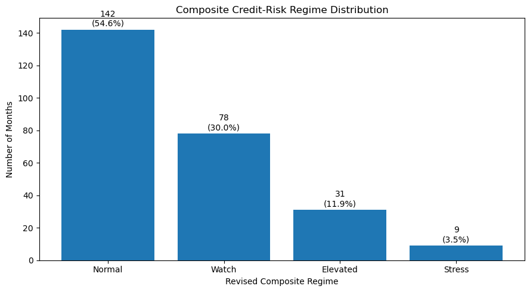

```
Saved figure to: [LOCAL_USER_PATH]\Downloads\Data Analytic Projects\credit_risk_detection_and_monitor_dashboard\outputs\figures\composite_credit_risk_regime_distribution.png
```

```python
fig, ax = plt.subplots(figsize=(9, 5))

bars = ax.bar(
    composite_regime_distribution["composite_credit_risk_regime_revised"],
    composite_regime_distribution["month_count"]
)

for bar, row in zip(bars, composite_regime_distribution.itertuples()):
    ax.text(
        bar.get_x() + bar.get_width() / 2,
        bar.get_height() + 1,
        f"{row.month_count}\n({row.month_share_pct:.1f}%)",
        ha="center",
        va="bottom"
    )

ax.set_title("Composite Credit-Risk Regime Distribution")
ax.set_xlabel("Revised Composite Regime")
ax.set_ylabel("Number of Months")

plt.tight_layout()

figure_path = figures_dir / "composite_credit_risk_regime_distribution.png"

plt.savefig(
    figure_path,
    dpi=300,
    bbox_inches="tight"
)

plt.show()

print(f"Saved figure to: {figure_path}")
```

### Composite Regime Distribution Interpretation

The composite regime distribution shows how often the dashboard classified monthly macro-credit conditions as Normal, Watch, Elevated, or Stress.

This distribution is useful because it evaluates whether the revised thresholds are practical. Most months should fall into Normal or Watch, while Elevated and Stress should occur less frequently and represent more severe historical conditions.

The regime distribution should be interpreted alongside the recession-share table. A good threshold framework should not only produce reasonable month counts, but should also show that higher-risk regimes contain a larger share of recession observations.

### 9.7 Save Visualization Output Summary

This section verifies the final visualization files saved to the projectâ€™s `outputs/figures/` folder. These chart files can be used in the GitHub README, portfolio documentation, presentation slides, or a later Streamlit dashboard.

The SQLite tables saved in Section 8 preserve the dashboard data outputs. The `.png` files saved in Section 9 preserve the final visual outputs.

```python
saved_figure_files = sorted(figures_dir.glob("*.png"))

visualization_output_summary = pd.DataFrame({
    "figure_name": [file.name for file in saved_figure_files],
    "figure_path": [str(file) for file in saved_figure_files],
    "file_size_kb": [round(file.stat().st_size / 1024, 2) for file in saved_figure_files]
})

visualization_output_summary
```

|  | figure_name | figure_path | file_size_kb |
| --- | --- | --- | --- |
| 0 | category_risk_scores_over_time.png | [LOCAL_USER_PATH]\Downloads\Data Analytic Projects\credit_risk_detection_and_monitor_dashboard\outputs\figures\category_risk_scores_over_time.png | 827.60 |
| 1 | composite_credit_risk_regime_distribution.png | [LOCAL_USER_PATH]\Downloads\Data Analytic Projects\credit_risk_detection_and_monitor_dashboard\outputs\figures\composite_credit_risk_regime_distribution.png | 115.43 |
| 2 | full_history_composite_credit_risk_score_revised_thresholds.png | [LOCAL_USER_PATH]\Downloads\Data Analytic Projects\credit_risk_detection_and_monitor_dashboard\outputs\figures\full_history_composite_credit_risk_score_revised_thresholds.png | 282.14 |
| 3 | historical_composite_credit_risk_score_arima_forecast.png | [LOCAL_USER_PATH]\Downloads\Data Analytic Projects\credit_risk_detection_and_monitor_dashboard\outputs\figures\historical_composite_credit_risk_score_arima_forecast.png | 344.60 |
| 4 | latest_category_risk_drivers.png | [LOCAL_USER_PATH]\Downloads\Data Analytic Projects\credit_risk_detection_and_monitor_dashboard\outputs\figures\latest_category_risk_drivers.png | 159.41 |
| 5 | trailing_12_month_category_risk_score_zoom.png | [LOCAL_USER_PATH]\Downloads\Data Analytic Projects\credit_risk_detection_and_monitor_dashboard\outputs\figures\trailing_12_month_category_risk_score_zoom.png | 376.90 |

```python
visualization_output_summary.to_sql(
    "dashboard_visualization_output_summary",
    conn,
    if_exists="replace",
    index=False
)

print("Visualization output summary saved successfully.")
```

```
Visualization output summary saved successfully.
```

```python
pd.read_sql_query(
    """
    SELECT *
    FROM dashboard_visualization_output_summary
    ORDER BY figure_name;
    """,
    conn
)
```

|  | figure_name | figure_path | file_size_kb |
| --- | --- | --- | --- |
| 0 | category_risk_scores_over_time.png | [LOCAL_USER_PATH]\Downloads\Data Analytic Projects\credit_risk_detection_and_monitor_dashboard\outputs\figures\category_risk_scores_over_time.png | 827.60 |
| 1 | composite_credit_risk_regime_distribution.png | [LOCAL_USER_PATH]\Downloads\Data Analytic Projects\credit_risk_detection_and_monitor_dashboard\outputs\figures\composite_credit_risk_regime_distribution.png | 115.43 |
| 2 | full_history_composite_credit_risk_score_revised_thresholds.png | [LOCAL_USER_PATH]\Downloads\Data Analytic Projects\credit_risk_detection_and_monitor_dashboard\outputs\figures\full_history_composite_credit_risk_score_revised_thresholds.png | 282.14 |
| 3 | historical_composite_credit_risk_score_arima_forecast.png | [LOCAL_USER_PATH]\Downloads\Data Analytic Projects\credit_risk_detection_and_monitor_dashboard\outputs\figures\historical_composite_credit_risk_score_arima_forecast.png | 344.60 |
| 4 | latest_category_risk_drivers.png | [LOCAL_USER_PATH]\Downloads\Data Analytic Projects\credit_risk_detection_and_monitor_dashboard\outputs\figures\latest_category_risk_drivers.png | 159.41 |
| 5 | trailing_12_month_category_risk_score_zoom.png | [LOCAL_USER_PATH]\Downloads\Data Analytic Projects\credit_risk_detection_and_monitor_dashboard\outputs\figures\trailing_12_month_category_risk_score_zoom.png | 376.90 |

### 9.8 Section 9 Wrap-Up

Section 9 converts the dashboard-ready score outputs into final visualization files. The visualizations summarize the historical Composite Credit Risk Score, the ARIMA-based forward outlook, category-level risk drivers, category score trends, and revised regime distribution.

The visualizations serve three purposes:

1. **Current monitoring:** identify the latest composite score, current regime, and main category drivers.
2. **Historical validation:** show how the score and revised thresholds behaved across prior recession and stress periods.
3. **Forward outlook:** display the ARIMA-based six-month composite score forecast and uncertainty range.

These charts are saved as `.png` files in the `outputs/figures/` folder and are ready to be used in the GitHub README, business interpretation section, and future interactive dashboard.

## 10. Business Interpretation

Section 10 translates the final dashboard outputs into business-facing interpretation. The goal is to explain what the current macro-credit risk score means, what is driving the score, how the current reading compares with historical stress regimes, and how the forward ARIMA outlook should be interpreted.

This section uses the final dashboard tables and visualizations created in Sections 8 and 9 to answer the main project question:

> Are macro-credit conditions deteriorating, and do those regimes provide context for recession risk and market behavior?

The interpretation is structured around four questions:

1. What is the current Composite Credit Risk Score and regime?
2. Which category is driving the current score?
3. Does the current reading suggest broad-based stress or concentrated risk?
4. What does the forward outlook imply over the next 1-month, 3-month, and 6-month monitoring windows?

### 10.1 Latest Dashboard Summary

This section summarizes the latest dashboard reading using the saved current snapshot and forward outlook tables. The purpose is to convert the model output into a concise business-facing summary.

The latest reading should be interpreted as a macro-credit monitoring signal. The dashboard evaluates aggregate macro-credit conditions using market stress, labor risk, rate/yield-curve pressure, and realized credit performance.

```python
latest_business_snapshot = pd.read_sql_query(
    """
    SELECT *
    FROM dashboard_current_credit_risk_snapshot;
    """,
    conn
)

latest_forward_outlook = pd.read_sql_query(
    """
    SELECT *
    FROM dashboard_forward_credit_risk_outlook;
    """,
    conn
)

latest_composite_snapshot = latest_business_snapshot[
    latest_business_snapshot["score_component"] == "Composite Credit Risk Score"
].copy()

latest_category_snapshot = latest_business_snapshot[
    latest_business_snapshot["score_component"] != "Composite Credit Risk Score"
].copy()

latest_composite_snapshot
```

|  | latest_month | score_component | current_composite_regime | latest_score | prior_month_score | change_1m | change_3m | change_6m | one_month_direction |
| --- | --- | --- | --- | --- | --- | --- | --- | --- | --- |
| 0 | 2026-07-31 | Composite Credit Risk Score | Normal | 43.14 | 42.84 | 0.3 | -9.78 | -1.71 | Stable |

```python
latest_category_snapshot.sort_values(
    "latest_score",
    ascending=False
)
```

|  | latest_month | score_component | current_composite_regime | latest_score | prior_month_score | change_1m | change_3m | change_6m | one_month_direction |
| --- | --- | --- | --- | --- | --- | --- | --- | --- | --- |
| 3 | 2026-07-31 | Rate / Yield-Curve Pressure | Normal | 74.94 | 72.12 | 2.82 | 7.13 | 5.80 | Deteriorating |
| 4 | 2026-07-31 | Realized Credit Performance | Normal | 44.31 | 44.29 | 0.02 | 0.05 | 2.40 | Stable |
| 1 | 2026-07-31 | Market / Financial Stress | Normal | 27.54 | 17.56 | 9.98 | -27.23 | -9.03 | Deteriorating |
| 2 | 2026-07-31 | Macro / Labor Risk | Normal | 25.75 | 37.39 | -11.64 | -19.10 | -6.04 | Improving |

```python
latest_forward_outlook[
    latest_forward_outlook["score_component"] == "Composite Credit Risk Score"
]
```

|  | score_component | selected_arima_order | selection_criterion | outlook_window | projected_score | projected_classification |
| --- | --- | --- | --- | --- | --- | --- |
| 0 | Composite Credit Risk Score | (2, 0, 2) | BIC | Current | 43.14 | Normal |
| 1 | Composite Credit Risk Score | (2, 0, 2) | BIC | Projected 1-month | 44.30 | Normal |
| 2 | Composite Credit Risk Score | (2, 0, 2) | BIC | Projected 3-month | 44.83 | Normal |
| 3 | Composite Credit Risk Score | (2, 0, 2) | BIC | Projected 6-month | 45.21 | Watch |

### 10.2 Current Business Interpretation

The latest dashboard reading indicates that the Composite Credit Risk Score remains in the Normal regime. The most recent composite score is below the Watch threshold of 45, meaning the overall macro-credit environment is not currently classified as broad-based stress.

The recent score changes show whether conditions are improving or deteriorating. A negative 1-month, 3-month, or 6-month change means the composite risk score declined over that lookback window, suggesting easing macro-credit pressure. A positive change would suggest deterioration.

The category driver table is important because the composite score alone does not explain where risk is concentrated. The latest results show that Rate / Yield-Curve Pressure is the largest current category driver. This means the primary source of current risk is coming from the interest-rate and yield-curve channel rather than from broad market stress, labor deterioration, or realized credit losses.

This distinction matters. A Normal composite score with one elevated category does not mean there is no risk. It means the current risk is concentrated rather than broad-based. The dashboard becomes more concerning when multiple categories rise together, especially if Market / Financial Stress, Macro / Labor Risk, and Realized Credit Performance all deteriorate at the same time.

```python
latest_business_snapshot = pd.read_sql_query(
    """
    SELECT *
    FROM dashboard_current_credit_risk_snapshot;
    """,
    conn
)

business_change_summary = latest_business_snapshot[
    [
        "score_component",
        "latest_score",
        "prior_month_score",
        "change_1m",
        "change_3m",
        "change_6m"
    ]
].copy()

business_change_summary = business_change_summary.round(2)

business_change_summary
```

|  | score_component | latest_score | prior_month_score | change_1m | change_3m | change_6m |
| --- | --- | --- | --- | --- | --- | --- |
| 0 | Composite Credit Risk Score | 43.14 | 42.84 | 0.30 | -9.78 | -1.71 |
| 1 | Market / Financial Stress | 27.54 | 17.56 | 9.98 | -27.23 | -9.03 |
| 2 | Macro / Labor Risk | 25.75 | 37.39 | -11.64 | -19.10 | -6.04 |
| 3 | Rate / Yield-Curve Pressure | 74.94 | 72.12 | 2.82 | 7.13 | 5.80 |
| 4 | Realized Credit Performance | 44.31 | 44.29 | 0.02 | 0.05 | 2.40 |

```python
category_change_contribution = business_change_summary[
    business_change_summary["score_component"] != "Composite Credit Risk Score"
].copy()

category_change_contribution["contribution_to_composite_1m"] = (
    category_change_contribution["change_1m"] / 4
)

category_change_contribution["contribution_to_composite_3m"] = (
    category_change_contribution["change_3m"] / 4
)

category_change_contribution["contribution_to_composite_6m"] = (
    category_change_contribution["change_6m"] / 4
)

category_change_contribution = category_change_contribution[
    [
        "score_component",
        "latest_score",
        "change_1m",
        "contribution_to_composite_1m",
        "change_3m",
        "contribution_to_composite_3m",
        "change_6m",
        "contribution_to_composite_6m"
    ]
].round(2)

category_change_contribution.sort_values(
    "latest_score",
    ascending=False
)
```

|  | score_component | latest_score | change_1m | contribution_to_composite_1m | change_3m | contribution_to_composite_3m | change_6m | contribution_to_composite_6m |
| --- | --- | --- | --- | --- | --- | --- | --- | --- |
| 3 | Rate / Yield-Curve Pressure | 74.94 | 2.82 | 0.70 | 7.13 | 1.78 | 5.80 | 1.45 |
| 4 | Realized Credit Performance | 44.31 | 0.02 | 0.00 | 0.05 | 0.01 | 2.40 | 0.60 |
| 1 | Market / Financial Stress | 27.54 | 9.98 | 2.50 | -27.23 | -6.81 | -9.03 | -2.26 |
| 2 | Macro / Labor Risk | 25.75 | -11.64 | -2.91 | -19.10 | -4.78 | -6.04 | -1.51 |

### 10.2 Score Analysis Interpretation

The latest Composite Credit Risk Score is **43.14**, which places the dashboard in the **Normal** regime. This is below the revised Watch threshold of 45.

The recent changes show a mixed but contained risk picture:

- **1M Change:** +0.30
- **3M Change:** -9.78
- **6M Change:** -1.71

Because higher scores indicate higher risk, the positive 1-month change means the score increased slightly from the prior month. However, the negative 3-month and 6-month changes show that the current score is still lower than it was earlier in the year.

The category driver table shows that **Rate / Yield-Curve Pressure** is the largest current driver, with a latest score of **74.94**. This category increased by **2.82** points over the prior month, contributing about **+0.70** points to the composite score.

**Market / Financial Stress** rose by **9.98** points over the prior month, contributing about **+2.50** points to the composite score. Even with that increase, its latest score is only **27.54**, so it remains a lower overall contributor.

**Macro / Labor Risk** declined by **11.64** points over the prior month, contributing about **-2.91** points to the composite score. This decline offset much of the increase from Market / Financial Stress and Rate / Yield-Curve Pressure.

**Realized Credit Performance** remained nearly unchanged, with a latest score of **44.31** and a 1-month change of only **+0.02**.

Overall, the latest reading suggests concentrated risk rather than broad-based macro-credit stress. The main current pressure is Rate / Yield-Curve Pressure. Market stress increased over the prior month, but Macro / Labor Risk declined enough to keep the overall composite score in the Normal regime.

### 10.3 Forward Outlook Business Interpretation

The forward outlook uses the ARIMA forecast created earlier in the notebook to project the Composite Credit Risk Score over the next 1-month, 3-month, and 6-month monitoring windows.

This section does not introduce a new model. It interprets the forecast output already created in Section 8.3.

The purpose is to answer a simple business question:

> Is the dashboardâ€™s composite credit-risk score expected to improve, remain stable, or deteriorate over the near-term monitoring window?

The point forecast shows the modelâ€™s baseline projection for the Composite Credit Risk Score. The forecast range shows the uncertainty around that projection.

A current score below 45 is classified as Normal. A projected score that remains below 45 suggests the baseline outlook remains contained. If the upper forecast range crosses above 45 or 55, that means the baseline outlook is still contained, but there is some upside risk toward Watch or Elevated conditions.

```python
pd.read_sql_query(
    """
    SELECT *
    FROM dashboard_composite_forward_outlook_range;
    """,
    conn
)
```

|  | outlook_window | selected_arima_order | projected_score | lower_range | upper_range | projected_regime |
| --- | --- | --- | --- | --- | --- | --- |
| 0 | Current | (2, 0, 2) | 43.14 | NaN | NaN | Normal |
| 1 | Projected 1-month | (2, 0, 2) | 44.30 | 35.85 | 52.75 | Normal |
| 2 | Projected 3-month | (2, 0, 2) | 44.83 | 28.41 | 61.25 | Normal |
| 3 | Projected 6-month | (2, 0, 2) | 45.21 | 25.50 | 64.92 | Watch |

```python
component_forward_outlook = forward_outlook[
    forward_outlook["score_component"] != "Composite Credit Risk Score"
].copy()

component_forward_outlook
```

|  | score_component | selected_arima_order | selection_criterion | outlook_window | projected_score | projected_classification |
| --- | --- | --- | --- | --- | --- | --- |
| 4 | Market / Financial Stress | (1, 0, 2) | BIC | Current | 27.54 | Normal |
| 5 | Market / Financial Stress | (1, 0, 2) | BIC | Projected 1-month | 41.02 | Normal |
| 6 | Market / Financial Stress | (1, 0, 2) | BIC | Projected 3-month | 46.63 | Normal |
| 7 | Market / Financial Stress | (1, 0, 2) | BIC | Projected 6-month | 46.10 | Normal |
| 8 | Macro / Labor Risk | (2, 1, 2) | BIC | Current | 25.75 | Normal |
| 9 | Macro / Labor Risk | (2, 1, 2) | BIC | Projected 1-month | 31.80 | Normal |
| 10 | Macro / Labor Risk | (2, 1, 2) | BIC | Projected 3-month | 34.34 | Normal |
| 11 | Macro / Labor Risk | (2, 1, 2) | BIC | Projected 6-month | 34.12 | Normal |
| 12 | Rate / Yield-Curve Pressure | (2, 1, 2) | BIC | Current | 74.94 | Watch |
| 13 | Rate / Yield-Curve Pressure | (2, 1, 2) | BIC | Projected 1-month | 73.51 | Watch |
| 14 | Rate / Yield-Curve Pressure | (2, 1, 2) | BIC | Projected 3-month | 69.75 | Watch |
| 15 | Rate / Yield-Curve Pressure | (2, 1, 2) | BIC | Projected 6-month | 69.08 | Watch |
| 16 | Realized Credit Performance | (0, 1, 2) | BIC | Current | 44.31 | Normal |
| 17 | Realized Credit Performance | (0, 1, 2) | BIC | Projected 1-month | 44.31 | Normal |
| 18 | Realized Credit Performance | (0, 1, 2) | BIC | Projected 3-month | 44.31 | Normal |
| 19 | Realized Credit Performance | (0, 1, 2) | BIC | Projected 6-month | 44.31 | Normal |

### ARIMA Model Selection Note

The composite score and the individual category scores were forecasted separately. Each score series was tested across the same ARIMA candidate grid, and the final order was selected using BIC.

The Composite Credit Risk Score selected an **ARIMA(2, 0, 2)** model. This means the model uses two autoregressive terms, no differencing, and two moving-average terms.

The individual category forecasts use different ARIMA orders because each category has different time-series behavior. Market / Financial Stress can move quickly, Macro / Labor Risk can lag, Rate / Yield-Curve Pressure can remain persistent, and Realized Credit Performance tends to move more slowly.

Because of this, the category forecasts should be interpreted as separate component outlooks, not as manually summed forecasts. The main dashboard forecast is the Composite Credit Risk Score forecast, while the category forecasts help explain which underlying risk channels are expected to rise, fall, or remain stable.

### Forward Outlook Summary

The latest observed Composite Credit Risk Score is **43.14**, which places the dashboard in the **Normal** regime.

The ARIMA forecast projects the composite score to move to approximately:

- **44.30** over the next 1 month
- **44.83** over the next 3 months
- **45.21** over the next 6 months

Based on the point forecast, the composite score remains in the **Normal** regime over the 1-month and 3-month windows, but moves into the **Watch** regime by the 6-month window.

The forecast range is still important. The upper forecast range reaches approximately **64.92**, which falls in the **Elevated** range. This means the baseline forecast shows only mild deterioration, but the uncertainty range allows for a higher-risk outcome if conditions weaken.

Overall, the forward outlook suggests that macro-credit risk is **mildly deteriorating but still contained**. The dashboard does not currently project broad-based Stress conditions, but the 6-month forecast moving into Watch means the score should be monitored closely for continued deterioration.

### Component Forecast Interpretation

The component forecast table shows how the four category scores are projected to move over the same forecast window.

The main projected pressure remains **Rate / Yield-Curve Pressure**. Its score is currently **74.94** and is projected to remain high at **69.08** over the 6-month window. Even though this category is projected to ease slightly, it remains the largest contributor to the composite score.

**Market / Financial Stress** is projected to rise from **27.54** currently to **46.10** over the 6-month window. This is still below the category Watch threshold of 50, but it shows that market stress is projected to increase from a low level.

**Macro / Labor Risk** is projected to rise from **25.75** to **34.12**, but it remains in the Normal range. This means the model does not yet project severe labor-risk pressure based on the dashboardâ€™s current monthly inputs.

**Realized Credit Performance** remains stable at **44.31** across the forecast window. This reflects the slower-moving nature of delinquency and charge-off indicators.

The component forecast supports the composite forecast. The dashboard is not projecting broad-based stress across all four categories. Instead, the main current and projected pressure remains concentrated in the rate/yield-curve channel, with some projected increase in market/financial stress.

# 10.4 Main Business Questions Answered

The dashboard was built to answer whether macro-credit conditions are deteriorating and whether those conditions provide useful context for recession risk, market behavior, and near-term monitoring.

Based on the latest dashboard output, the current Composite Credit Risk Score is **43.14**, which remains in the **Normal** regime. This is below the revised Watch threshold of **45**, so the dashboard does not currently indicate broad-based macro-credit stress.

The Composite Credit Risk Score is measured on a **0-to-100 risk scale**, where higher values indicate greater macro-credit pressure. The score is calculated as an equal-weighted average of four category scores: Market / Financial Stress, Macro / Labor Risk, Rate / Yield-Curve Pressure, and Realized Credit Performance. Each category receives a 25% weight in the final composite score.

The equal 25% category weighting is a Version 1 design choice. It is used for transparency and interpretability rather than because the notebook proves that each category has the same predictive importance. Equal weighting prevents the first version from overfitting category weights to a limited historical sample or assigning arbitrary importance to one risk channel before formal validation. Lookahead bias is handled separately through the expanding-percentile scoring framework, not through the equal-weight choice.

Because all category inputs are transformed so that higher values consistently represent greater risk, each category contributes in the same risk direction. However, the categories can still offset one another because they capture different parts of the credit cycle. Rate / Yield-Curve Pressure may rise before recession conditions are visible, while Macro / Labor Risk and Realized Credit Performance may confirm deterioration later.

The category scores are also measured on a **0-to-100 category risk-score scale**. Therefore, when a category increases by 9.98 points, that means the categoryâ€™s risk score increased by 9.98 points on its own 0-to-100 scale. Because each category receives a 25% weight, that 9.98-point category increase contributes approximately 2.50 points to the composite score, all else equal.

The current reading is close to Watch. The dashboard shows that risk is concentrated in one major channel: **Rate / Yield-Curve Pressure**. This category has the highest current score at **74.94**, meaning interest-rate and yield-curve pressure remain the main source of macro-credit risk.

The current risk picture is **concentrated rather than broad-based**. Broad-based risk would mean that multiple categories are elevated at the same time across market stress, labor risk, rate/yield-curve pressure, and realized credit performance. In the latest reading, the main pressure is concentrated in Rate / Yield-Curve Pressure, while the other categories do not currently confirm broad stress across the full dashboard.

The recent change pattern is mixed. The Composite Credit Risk Score increased by **0.30** points over the prior month, which indicates slight deterioration. However, the score is still down **9.78** points over the prior three months and down **1.71** points over the prior six months. This means the latest month showed renewed pressure, but the broader recent trend remains more contained than earlier in the year.

The category-level changes explain why the composite score stayed in the Normal regime. **Market / Financial Stress** increased by **9.98 category-score points** over the prior month, contributing approximately **+2.50 composite-score points** after applying the 25% category weight. **Rate / Yield-Curve Pressure** increased by **2.82 category-score points**, contributing approximately **+0.71 composite-score points**. These movements pushed the composite score higher.

However, **Macro / Labor Risk** declined by **11.64 category-score points**, contributing approximately **-2.91 composite-score points** and offsetting much of the deterioration from market stress and rate/yield-curve pressure. **Realized Credit Performance** was nearly unchanged, with only a **0.02 category-score point** increase. This explains why the total composite score increased only **0.30 points** even though some individual categories moved more sharply.

The trailing 12-month category chart shows that the current reading is contained but not flat. Rate / Yield-Curve Pressure remains the highest category score, while Market / Financial Stress and Macro / Labor Risk have moved more sharply month to month. Realized Credit Performance is more stable, which is expected because delinquency and charge-off measures tend to move more slowly.

The historical validation supports the use of the revised regime framework. The score and category components behaved sensibly around major stress periods. Market / Financial Stress reacted quickly during stress episodes, Macro / Labor Risk and Realized Credit Performance tended to confirm deterioration later, and Rate / Yield-Curve Pressure behaved more like an early-warning or policy-pressure channel. The revised thresholds created more useful separation than the original thresholds because Normal months were largely associated with ordinary conditions, while Elevated and Stress regimes were more closely associated with recession or broad macro-credit deterioration.

The forward outlook shows mild deterioration. The Composite Credit Risk Score is projected to rise from **43.14** currently to **44.30** over 1 month, **44.83** over 3 months, and **45.21** over 6 months. The 6-month projection crosses into the **Watch** regime.

The ARIMA forecast should be read as a baseline monitoring path, not as a stress scenario. The point forecast shows mild movement toward Watch, while the forecast range shows that a higher-risk path is possible if conditions weaken.

The forecast should also be interpreted with its uncertainty range and diagnostics in mind. The ARIMA layer provides a transparent baseline outlook, but it does not replace rolling-origin forecast validation, scenario analysis, or broader macro-policy inputs. The 1-month outlook is the most directly useful monitoring window, the 3-month outlook is a reasonable baseline, and the 6-month outlook should be interpreted more cautiously.

The 6-month forecast should be treated cautiously because macro-credit conditions can change quickly when new market, labor, policy, inflation, or credit information arrives. ARIMA projects the score based on the historical behavior of the score itself. If conditions remain broadly similar, the forecast provides a useful baseline trend. However, if new shocks occur, the actual score can move faster than the smoothed 6-month baseline path.

#### S&P 500 Market-Context Question

The dashboard also tested whether revised macro-credit regimes and regime transitions provided useful context for future S&P 500 returns.

The S&P 500 results should be interpreted as market-context validation, not as a trading model or standalone equity-return forecast. The S&P 500 variables were not used to construct the Composite Credit Risk Score. They were retained as forward-looking outcome variables to test whether macro-credit regimes were associated with different future equity-market outcomes.

The regime-level S&P 500 validation did not support a simple rule that higher macro-credit risk automatically leads to weaker future S&P 500 returns. In the available S&P 500 window, **Normal** months had average forward S&P 500 returns of approximately **0.68%** over 1 month, **2.32%** over 3 months, and **5.20%** over 6 months. **Watch** months had average forward returns of approximately **1.13%**, **3.23%**, and **7.23%** over the same horizons. **Elevated** months had stronger average forward returns of approximately **4.49%** over 1 month, **11.83%** over 3 months, and **17.95%** over 6 months.

This result means the S&P 500 relationship is timing-dependent. Higher macro-credit risk did not automatically imply weaker future equity returns in this sample. One explanation is that by the time the dashboard reaches an Elevated regime, some bad news may already be priced into equity markets, allowing forward returns to improve if conditions stabilize, policy support becomes more visible, or risk appetite recovers.

The transition-level validation added a second market-context check. The most useful transition signal was **Normal â†’ Watch**. This transition had the worst observed 3-month forward S&P 500 downside at approximately **-16.45%**, along with negative-return shares of **40.0%** over 1 month, **20.0%** over 3 months, and **30.0%** over 6 months. This suggests that the first move out of Normal conditions may be the clearest early-warning transition in the current framework.

However, the transition evidence was limited. The **Watch â†’ Elevated** transition occurred only **4** times in the available S&P 500 window, and its average forward returns were strongly positive: approximately **4.37%** over 1 month, **12.02%** over 3 months, and **16.21%** over 6 months. The worst observed 3-month forward return after Watch â†’ Elevated was still positive at approximately **9.66%**. This reinforces that the relationship is not mechanically bearish and should not be treated as a reliable S&P 500 forecasting rule.

The conclusion is that the S&P 500 overlay adds useful market context, but it does not provide enough evidence for standalone financial decision-making. The dashboard can help frame risk-on / risk-off discussion and portfolio-monitoring context, but it should not be used as a mechanical S&P 500 forecasting or trading signal.

A stronger future version could test this question more formally by using longer market-history data, alternative regime thresholds, additional transition definitions, rolling validation, volatility measures, rate-shock variables, and broader macro-policy inputs. In Version 1, the number of regime transitions is too limited to support a conclusive transition-based equity forecasting strategy.

The main business conclusion is that current macro-credit risk is **contained but close to Watch**. The dashboard does not show broad-based stress across all four categories, but Rate / Yield-Curve Pressure remains elevated, Market / Financial Stress has recently increased, and the forecast suggests continued monitoring is warranted.

```python
saved_figure_files = sorted(figures_dir.glob("*.png"))

for file in saved_figure_files:
    print(file.name)
```

```
category_risk_scores_over_time.png
composite_credit_risk_regime_distribution.png
full_history_composite_credit_risk_score_revised_thresholds.png
historical_composite_credit_risk_score_arima_forecast.png
latest_category_risk_drivers.png
trailing_12_month_category_risk_score_zoom.png
trailing_12_month_category_scores_with_composite_forecast_overlay.png
trailing_12_month_composite_arima_forecast_zoom.png
```

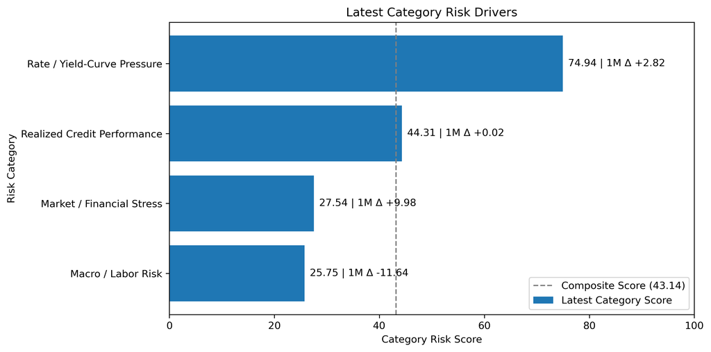

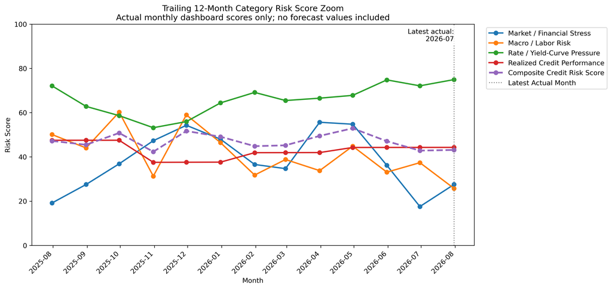

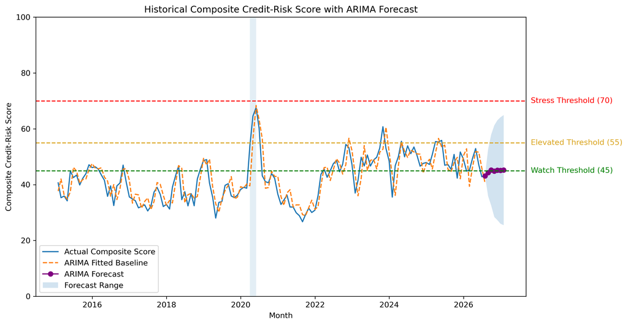

```python
from IPython.display import Image, display

display(Image(filename=str(figures_dir / "latest_category_risk_drivers.png")))
display(Image(filename=str(figures_dir / "trailing_12_month_category_risk_score_zoom.png")))
display(Image(filename=str(figures_dir / "historical_composite_credit_risk_score_arima_forecast.png")))
```

### 10.5 Limitations and Version 2 Enhancements

This dashboard evaluates aggregate credit conditions using public macroeconomic, market, rate, and credit-performance indicators.

The ARIMA forecast should be interpreted as a baseline score projection. The model forecasts the dashboard score based on the scoreâ€™s own historical behavior. This makes the forecast useful for monitoring direction, but it should not be treated as a complete stress scenario.

The 1-month forecast is the most directly useful forecast window. The 3-month forecast is a reasonable monitoring baseline. The 6-month forecast should be interpreted more cautiously because macro-credit conditions can shift materially over that time frame.

The forecast range reflects model-based statistical uncertainty around the ARIMA baseline. It may capture ordinary historical score volatility, but it does not explicitly model future geopolitical shocks, energy-price shocks, Federal Reserve surprises, sudden labor-market deterioration, or liquidity events. Because of this, the forecast range should be used as a monitoring band rather than as guaranteed accuracy.

The project has not yet completed rolling-origin forecast validation. As a result, the notebook does not formally prove whether the 1-month, 3-month, or 6-month horizon is most accurate. Based on the recent volatility of the score, the 6-month point forecast should be treated as a directional monitoring path rather than a precise estimate.

The Version 1 labor category is intentionally simple. Macro / Labor Risk is primarily based on unemployment-related monthly features. It does not yet include payroll growth, initial jobless claims, continuing claims, JOLTS openings, labor-force participation, wage growth, or payroll revisions. Because of this, newer labor-market weakness may appear in a weekly macro brief before it is fully reflected in the dashboard score.

Inflation is not directly scored as its own input category in Version 1. The project includes nominal interest-rate and yield-curve pressure, but it does not separately score CPI, core CPI, inflation expectations, wage inflation, or real interest rates.

This distinction matters because nominal interest rates do not fully describe monetary pressure. The same nominal rate can imply different levels of restrictiveness depending on inflation. For example, a 5% Fed Funds rate is much tighter when inflation is 2% than when inflation is 6%.

Real rates would help address this limitation. A real interest rate adjusts a nominal interest rate for inflation. For example, if the nominal 10-year Treasury yield is 4.5% and expected inflation is 2.5%, the approximate real 10-year rate is 2.0%. Version 2 could use real rates to better measure whether monetary conditions are restrictive after inflation is considered.

Version 1 also uses equal category weights for transparency and interpretability. Each of the four categories receives a 25% weight in the Composite Credit Risk Score. This makes the score easy to explain, but it assumes that Market / Financial Stress, Macro / Labor Risk, Rate / Yield-Curve Pressure, and Realized Credit Performance contribute equally to aggregate macro-credit risk.

The S&P 500 market-context overlay is also limited by sample size. Because the FRED S&P 500 series begins later than the full credit-risk dataset, the forward-return and transition checks have fewer observations than the recession-validation tests. Future versions could expand the market-context layer by testing alternative regime thresholds, adding longer market-history sources, evaluating additional equity and credit-market outcomes, and using rolling validation to test whether regime transitions provide stable forward-looking information.

Version 2 could test alternative weighting schemes using historical validation against recession periods, credit-spread widening, realized credit deterioration, and market downside. This would make the composite score more empirically calibrated rather than purely equal-weighted.

Version 2 should also include feature-level driver analysis. The current dashboard explains which category is driving the composite score. Feature-level analysis would go one layer deeper and explain which specific indicators are driving each category.

For example, Market / Financial Stress is built from inputs such as VIX, corporate credit-spread pressure, and STLFSI4. STLFSI4 is the St. Louis Fed Financial Stress Index, which summarizes broad financial stress conditions across multiple market indicators. A feature-level table would show whether Market / Financial Stress increased because of VIX, credit spreads, STLFSI4, or their recent changes.

The strongest Version 2 enhancements would be:

- Add broader labor-market indicators.
- Add inflation, real-rate, and inflation-expectation indicators.
- Add lending-standard and credit-supply indicators.
- Compare 1-month and 3-month forecast horizons more directly, with less emphasis on the 6-month point forecast.
- Add rolling-origin forecast validation.
- Add scenario analysis for macro shocks.
- Add feature-level driver decomposition.
- Test alternative category-weighting schemes.

### 10.6 Section10 Wrap-Up

Section 10 converts the dashboard outputs into a business-facing interpretation.

The latest Composite Credit Risk Score remains in the **Normal** regime at **43.14**, but the score is close to the revised Watch threshold of **45**. The current risk picture is concentrated rather than broad-based. **Rate / Yield-Curve Pressure** remains the largest driver, while Market / Financial Stress increased over the prior month and Macro / Labor Risk declined enough to offset part of that deterioration.

The ARIMA forecast projects mild deterioration, with the composite score moving from **43.14** currently to **45.21** over the 6-month window. This crosses into the **Watch** regime, but the forecast should be treated as a baseline monitoring path rather than a stress scenario.

The S&P 500 market-context validation adds an additional interpretation layer: regime transitions, especially Normal â†’ Watch, may help frame market-risk discussion, but the evidence is exploratory and not strong enough to support standalone equity-market forecasting decisions.

The final interpretation is that macro-credit risk is currently **contained but close to Watch**. The dashboard should continue monitoring whether pressure spreads from rate/yield-curve conditions into market stress, labor deterioration, and realized credit performance.